# Simulation study of EBMF programs

This vignette evaluates empirical Bayes matrix factorisation (EBMF) programs against synthetic data with known ground truth. It is organised around **input versions**: the same simulation, EBMF, and program-validation pipeline is run on versions of the input that differ in how the planted modules are structured (background density and trait overlap, driver architecture, spurious hits, and structural zeros), so the recovery metrics are directly comparable across runs.

Each version is generated by `simulate_trait()`, which produces a trait object (the target trait plus driver and background traits) with known ground truth. The total number of SNPs is set via `n_coloc_groups`, and the total number of traits (rows) via `n_traits`. Planted modules occupy **disjoint SNP sets** in the clean version; overlap can then be introduced in trait space (`trait_overlap`, `trait_effect_corr`), in SNP space (`driver_sharing`), or within a module’s own SNP set (`snp_driver_groups`).

For every version, the identical battery is run: `run_univariate_clustering()` fits EBMF and keeps overlapping soft programs, and `summarise_ebmf_programs()` filters programs by lFSR, loading magnitude, size, similarity and trait-subsampling stability. The key output is a per-program table in which **each validation check is its own column**, so it is immediately visible which check failed for each program:

Because the input now has realistic marginals, **recovery is expected to be partial and noisy**: the validation gates sit at the same levels that separate real modules from background, so only a subset of the discovered programs should be `valid`, and the pass rates below are the meaningful output for comparing input versions. The analysis settings below are fixed across versions; only the generative input changes.

## Does this simulation exercise the gates in the regime real data uses them?

The validation gates act on the SNP similarity graph, so what matters is not whether the simulated matrix has realistic per-trait sparsity and magnitude marginals – it is whether the *graph* those marginals induce resembles a real one. Those are not the same thing, and matching the marginals is not sufficient.

`simulated_graph_diagnostics()` measures the simulated graph and `real_bmi_graph_targets()` carries the values measured on the BMI pleiotropy matrix. The row to read first is `random_set_pass_rate`: the fraction of random SNP sets whose mean internal similarity clears 0.3. On real BMI data that is about 0.94 – a random set of SNPs passes the old absolute gate almost always, which is why that gate carried no specificity. Where the simulated value is near 0, a random set can never pass, so a null simulation study **cannot detect an uninformative gate** and its false-discovery rate is close to un-failable by construction.

The two generative parameters that move this are `background_corr` (background traits sharing structure, so they contribute to SNP-SNP similarity at all – at `0` they are independent and random-signed and contribute nothing) and `snp_pleiotropy_sd` (per-SNP heterogeneity in how many traits a SNP is observed on, which is what brings the median pairwise overlap down towards the real ~3 and produces the sparse SNPs that carry high cosines).

```
#>
#>
#> Table: Similarity-graph diagnostics for this run's generative settings against the values measured on the real BMI pleiotropy matrix. Read random_set_pass_rate first: where it is near 0 the gates are not being tested in the regime real data puts them in, whatever the recovery metrics below say.
#>
#> |statistic                 | simulated| real_bmi|
#> |:-------------------------|---------:|--------:|
#> |density                   |    0.1090|   0.0198|
#> |median_pair_overlap       |    1.0000|   3.0000|
#> |frac_pairs_zero_overlap   |    0.0000|   0.2140|
#> |mean_similarity           |    0.5920|   0.3480|
#> |median_similarity         |    0.3580|   0.3230|
#> |mean_similarity_no_target |    0.0464|   0.2840|
#> |random_set_mean_internal  |    0.5930|   0.3480|
#> |random_set_pass_rate      |    1.0000|   0.9350|
```

## Simulation design (ADEMP)

This study and its null companion follow the ADEMP structure of Morris, White and Crowther (2019, *Statistics in Medicine* 38:2074-2102, ). The elements are:

**Aims.** To evaluate the EBMF program-discovery pipeline when the truth is known: (i) how well planted modules are recovered (a **model-selection** target), and (ii) whether the validation gates stay quiet when no structure is planted (a **testing** target) — the latter is covered in `investigation-univariate-null-simulations.html`. Both aim to *stretch* the method by using realistic, messy marginals rather than a clean best case.

**Estimand / target.** The estimand is the true SNP-to-module partition, `ground_truth$module_of_snp` (a selection target), with derived targets the number of modules `K` and each module’s SNP set. Recovery is scored by `evaluate_univariate_simulation()` (see `R/evaluate_univariate_simulation.R`).

**Methods.** A single pipeline is evaluated, with no comparators: `run_univariate_clustering()` fits EBMF and `summarise_ebmf_programs()` applies a confidence tier (size, similarity, connectedness), with factor strength and replication reported. Thresholds are fixed across versions and are the same as those used on real data.

**Performance measures.** With truth `module_of_snp` and predicted valid memberships, and writing `truth`/`pred` for the labelled partitions:

- `k_hat = |distinct predicted programs|`, `k_planted = |distinct planted modules|`, `k_error = |k_hat - k_planted|`.
- `ari_structured`: adjusted Rand index over module SNPs only (background excluded), with each SNP projected to its strongest assigned program. Computed by `.adjusted_rand_index()` in `R/evaluate_univariate_simulation.R`.
- `module_recall = mean_m max_p |module_m ∩ program_p| / |module_m|` — the fraction of each planted module captured by its best predicted program; merge-fair, unlike ARI.
- `coverage = |{SNPs in any predicted program}| / n_snps`.
- `background_absorbed = |{background SNPs in any predicted program}| / n_background` — a SNP-level false-positive measure.
- Tier rates: per-replicate fraction of programs passing `size` and `similarity`, and in each confidence tier (`high`, `medium`, `low`); `valid` is high plus medium.

**Monte Carlo uncertainty.** Each estimate is the mean over `n_sim` replicates (default 3; override with `params = list(n_sim = ...)` for fast test runs). The replicate is the Monte Carlo unit, and every estimate is reported with a Monte Carlo standard error and a 95% Monte Carlo interval. For a continuous measure the MC SE is `sd / sqrt(n_sim)`; for a proportion it is `sqrt(p(1-p)/n_sim)`; and `n_sim` can be chosen for a target MC SE via `n_sim = p(1-p) / MCSE^2` (`n_sim_for_mcse()`). Common random numbers are used (one seed vector shared across all input versions), which lowers the MC SE of version-to-version differences. RNG states are recorded via the per-replicate seed in the estimates dataset.

Baseline EBMF analysis and validation settings (iterated generative parameters are shown at their baseline value; each input version is listed in the tier table below)

|  | parameter | value |
| --- | --- | --- |
| trait_subset | trait_subset | phenotypic |
| min_snp_signals | min_snp_signals | 2 |
| min_module_size | min_module_size | 3 |
| module_sizes | module_sizes | 60, 25, 8, 5, 3, 3 |
| compress_method | compress_method | asinh |
| compress_scale | compress_scale | 5 |
| similarity_threshold | similarity_threshold | 0.2 |
| overlap | overlap | disjoint |
| nested_effect_corr | nested_effect_corr | 0.8 |
| n_traits_per_module | n_traits_per_module | 20, 15, 10, 8, 5, 3 |
| trait_overlap | trait_overlap | 0 |
| trait_effect_corr | trait_effect_corr | 0 |
| n_traits | n_traits | 600 |
| effect_size | effect_size | 6 |
| effect_tail | effect_tail | 0 |
| p_structural_zero | p_structural_zero | 0 |
| p_spurious | p_spurious | 0 |
| p_active_background | p_active_background | 0 |
| background_sparsity_sd | background_sparsity_sd | 1.2 |
| background_effect_scale | background_effect_scale | 0.5 |
| target_pattern | target_pattern | module |
| ebmf_lfsr_threshold | ebmf_lfsr_threshold | 0.02 |
| ebmf_magnitude_threshold | ebmf_magnitude_threshold | 0.3 |
| ebmf_prior | ebmf_prior | point_normal |
| min_mean_internal | min_mean_internal | 0.3 |
| min_connectedness | min_connectedness | 0.5 |
| n_stability_rep | n_stability_rep | 0 |
| frac_traits | frac_traits | 0.8 |
| stability_top_n | stability_top_n | 20 |
| n_sim | n_sim | 3 |

## Input versions

Each input version is produced by iterating over the generative parameter arrays in the `params` block: every array element becomes one version, paired arrays are iterated in lock-step, and the first element of each array is the baseline. `p_active_background` is the exception — it is **crossed** with `trait_overlap`, so every background density is evaluated at every trait-overlap level. The versions fall into four groups, each stressing one aspect of the planted structure; the driver-architecture axis holds the others at their clean baseline, while the spurious-hit and structural-zero axes are run on a harder baseline (`trait_overlap = 0.5`, `p_active_background = 0.02`):

- **Background density × trait overlap** (`p_active_background` × `trait_overlap` / `trait_effect_corr`): the full grid of background association density against the fraction of each module’s driver traits shared with the other modules (correlated, `trait_effect_corr`, but non-identical effects).
- **Driver architecture** (`snp_driver_groups` / `driver_sharing`): splitting each module’s SNP set into groups (each driver trait acts on one group) and letting some driver traits also act at the neighbouring module’s SNP set.
- **Spurious hits** (`p_spurious`): background-scale off-module hits in the driver rows.
- **Structural zeros** (`p_structural_zero`): a fraction of each module’s true-support cells removed entirely (`NA`), emulating real-data dropout inside a module.

Null simulations (`K = 0`, no modules planted) are covered separately in `investigation-univariate-null-simulations.html`.

Generative parameters for each input version (each axis varies one feature of the planted structure; the spurious and structural-zero axes use a harder baseline, as shown in their trait_overlap / p_active_background columns)

| version | n_snps | K | module_sizes | n_traits_per_module | trait_overlap | trait_effect_corr | noise_sd | p_structural_zero | p_spurious | effect_size | effect_tail | background_effect_scale | p_active_background | background_sparsity_sd | target_pattern | driver_sharing | sign_pattern | snp_driver_groups |
| --- | --- | --- | --- | --- | --- | --- | --- | --- | --- | --- | --- | --- | --- | --- | --- | --- | --- | --- |
| background: p_active_background = 0, trait_overlap = 0 | 300 | 6 | 60, 25, 8, 5, 3, 3 | 20, 15, 10, 8, 5, 3 | 0.00 | 0.0 | 1 | 0.0 | 0.00 | 6 | 0 | 0.5 | 0.00 | 1.2 | module | 0.00 | coherent | 1 |
| background: p_active_background = 0, trait_overlap = 0.5 | 300 | 6 | 60, 25, 8, 5, 3, 3 | 20, 15, 10, 8, 5, 3 | 0.50 | 0.8 | 1 | 0.0 | 0.00 | 6 | 0 | 0.5 | 0.00 | 1.2 | module | 0.00 | coherent | 1 |
| background: p_active_background = 0, trait_overlap = 0.75 | 300 | 6 | 60, 25, 8, 5, 3, 3 | 20, 15, 10, 8, 5, 3 | 0.75 | 0.8 | 1 | 0.0 | 0.00 | 6 | 0 | 0.5 | 0.00 | 1.2 | module | 0.00 | coherent | 1 |
| background: p_active_background = 0, trait_overlap = 1 | 300 | 6 | 60, 25, 8, 5, 3, 3 | 20, 15, 10, 8, 5, 3 | 1.00 | 0.8 | 1 | 0.0 | 0.00 | 6 | 0 | 0.5 | 0.00 | 1.2 | module | 0.00 | coherent | 1 |
| background: p_active_background = 0.02, trait_overlap = 0 | 300 | 6 | 60, 25, 8, 5, 3, 3 | 20, 15, 10, 8, 5, 3 | 0.00 | 0.0 | 1 | 0.0 | 0.00 | 6 | 0 | 0.5 | 0.02 | 1.2 | module | 0.00 | coherent | 1 |
| background: p_active_background = 0.02, trait_overlap = 0.5 | 300 | 6 | 60, 25, 8, 5, 3, 3 | 20, 15, 10, 8, 5, 3 | 0.50 | 0.8 | 1 | 0.0 | 0.00 | 6 | 0 | 0.5 | 0.02 | 1.2 | module | 0.00 | coherent | 1 |
| background: p_active_background = 0.02, trait_overlap = 0.75 | 300 | 6 | 60, 25, 8, 5, 3, 3 | 20, 15, 10, 8, 5, 3 | 0.75 | 0.8 | 1 | 0.0 | 0.00 | 6 | 0 | 0.5 | 0.02 | 1.2 | module | 0.00 | coherent | 1 |
| background: p_active_background = 0.02, trait_overlap = 1 | 300 | 6 | 60, 25, 8, 5, 3, 3 | 20, 15, 10, 8, 5, 3 | 1.00 | 0.8 | 1 | 0.0 | 0.00 | 6 | 0 | 0.5 | 0.02 | 1.2 | module | 0.00 | coherent | 1 |
| background: p_active_background = 0.05, trait_overlap = 0 | 300 | 6 | 60, 25, 8, 5, 3, 3 | 20, 15, 10, 8, 5, 3 | 0.00 | 0.0 | 1 | 0.0 | 0.00 | 6 | 0 | 0.5 | 0.05 | 1.2 | module | 0.00 | coherent | 1 |
| background: p_active_background = 0.05, trait_overlap = 0.5 | 300 | 6 | 60, 25, 8, 5, 3, 3 | 20, 15, 10, 8, 5, 3 | 0.50 | 0.8 | 1 | 0.0 | 0.00 | 6 | 0 | 0.5 | 0.05 | 1.2 | module | 0.00 | coherent | 1 |
| background: p_active_background = 0.05, trait_overlap = 0.75 | 300 | 6 | 60, 25, 8, 5, 3, 3 | 20, 15, 10, 8, 5, 3 | 0.75 | 0.8 | 1 | 0.0 | 0.00 | 6 | 0 | 0.5 | 0.05 | 1.2 | module | 0.00 | coherent | 1 |
| background: p_active_background = 0.05, trait_overlap = 1 | 300 | 6 | 60, 25, 8, 5, 3, 3 | 20, 15, 10, 8, 5, 3 | 1.00 | 0.8 | 1 | 0.0 | 0.00 | 6 | 0 | 0.5 | 0.05 | 1.2 | module | 0.00 | coherent | 1 |
| background: p_active_background = 0.07, trait_overlap = 0 | 300 | 6 | 60, 25, 8, 5, 3, 3 | 20, 15, 10, 8, 5, 3 | 0.00 | 0.0 | 1 | 0.0 | 0.00 | 6 | 0 | 0.5 | 0.07 | 1.2 | module | 0.00 | coherent | 1 |
| background: p_active_background = 0.07, trait_overlap = 0.5 | 300 | 6 | 60, 25, 8, 5, 3, 3 | 20, 15, 10, 8, 5, 3 | 0.50 | 0.8 | 1 | 0.0 | 0.00 | 6 | 0 | 0.5 | 0.07 | 1.2 | module | 0.00 | coherent | 1 |
| background: p_active_background = 0.07, trait_overlap = 0.75 | 300 | 6 | 60, 25, 8, 5, 3, 3 | 20, 15, 10, 8, 5, 3 | 0.75 | 0.8 | 1 | 0.0 | 0.00 | 6 | 0 | 0.5 | 0.07 | 1.2 | module | 0.00 | coherent | 1 |
| background: p_active_background = 0.07, trait_overlap = 1 | 300 | 6 | 60, 25, 8, 5, 3, 3 | 20, 15, 10, 8, 5, 3 | 1.00 | 0.8 | 1 | 0.0 | 0.00 | 6 | 0 | 0.5 | 0.07 | 1.2 | module | 0.00 | coherent | 1 |
| drivers: snp_driver_groups = 1, driver_sharing = 0 | 300 | 6 | 60, 25, 8, 5, 3, 3 | 20, 15, 10, 8, 5, 3 | 0.00 | 0.0 | 1 | 0.0 | 0.00 | 6 | 0 | 0.5 | 0.00 | 1.2 | module | 0.00 | coherent | 1 |
| drivers: snp_driver_groups = 2, driver_sharing = 0.1 | 300 | 6 | 60, 25, 8, 5, 3, 3 | 20, 15, 10, 8, 5, 3 | 0.00 | 0.0 | 1 | 0.0 | 0.00 | 6 | 0 | 0.5 | 0.00 | 1.2 | module | 0.10 | coherent | 2 |
| drivers: snp_driver_groups = 3, driver_sharing = 0.25 | 300 | 6 | 60, 25, 8, 5, 3, 3 | 20, 15, 10, 8, 5, 3 | 0.00 | 0.0 | 1 | 0.0 | 0.00 | 6 | 0 | 0.5 | 0.00 | 1.2 | module | 0.25 | coherent | 3 |
| spurious: p_spurious = 0 | 300 | 6 | 60, 25, 8, 5, 3, 3 | 20, 15, 10, 8, 5, 3 | 0.50 | 0.8 | 1 | 0.0 | 0.00 | 6 | 0 | 0.5 | 0.02 | 1.2 | module | 0.00 | coherent | 1 |
| spurious: p_spurious = 0.01 | 300 | 6 | 60, 25, 8, 5, 3, 3 | 20, 15, 10, 8, 5, 3 | 0.50 | 0.8 | 1 | 0.0 | 0.01 | 6 | 0 | 0.5 | 0.02 | 1.2 | module | 0.00 | coherent | 1 |
| structural_zero: p_structural_zero = 0 | 300 | 6 | 60, 25, 8, 5, 3, 3 | 20, 15, 10, 8, 5, 3 | 0.50 | 0.8 | 1 | 0.0 | 0.00 | 6 | 0 | 0.5 | 0.02 | 1.2 | module | 0.00 | coherent | 1 |
| structural_zero: p_structural_zero = 0.1 | 300 | 6 | 60, 25, 8, 5, 3, 3 | 20, 15, 10, 8, 5, 3 | 0.50 | 0.8 | 1 | 0.1 | 0.00 | 6 | 0 | 0.5 | 0.02 | 1.2 | module | 0.00 | coherent | 1 |

## Aggregate results

Recovery metrics by input version (mean across 3 replicates; Monte Carlo SE in parentheses). module_recall and coverage preserve overlapping valid memberships.

| tier | k_hat | valid programs | module recall | coverage | ARI (structured) | background absorbed |
| --- | --- | --- | --- | --- | --- | --- |
| background: p_active_background = 0, trait_overlap = 0 | 6.00 (0.00) | 6.00 (0.00) | 1.00 (0.00) | 0.35 (0.00) | 1.00 (0.00) | 0.00 (0.00) |
| background: p_active_background = 0, trait_overlap = 0.5 | 4.67 (0.67) | 4.67 (0.67) | 0.78 (0.11) | 0.27 (0.07) | 0.97 (0.02) | 0.00 (0.00) |
| background: p_active_background = 0, trait_overlap = 0.75 | 3.67 (0.88) | 3.67 (0.88) | 0.78 (0.06) | 0.20 (0.06) | 0.96 (0.04) | 0.00 (0.00) |
| background: p_active_background = 0, trait_overlap = 1 | 3.00 (0.58) | 3.00 (0.58) | 0.72 (0.06) | 0.14 (0.00) | 0.91 (0.04) | 0.00 (0.00) |
| background: p_active_background = 0.02, trait_overlap = 0 | 5.33 (0.67) | 5.33 (0.67) | 0.89 (0.11) | 0.34 (0.01) | 1.00 (0.00) | 0.00 (0.00) |
| background: p_active_background = 0.02, trait_overlap = 0.5 | 5.00 (0.00) | 5.00 (0.00) | 0.93 (0.05) | 0.34 (0.00) | 1.00 (0.00) | 0.00 (0.00) |
| background: p_active_background = 0.02, trait_overlap = 0.75 | 4.00 (1.00) | 4.00 (1.00) | 0.78 (0.06) | 0.15 (0.01) | 0.97 (0.02) | 0.01 (0.01) |
| background: p_active_background = 0.02, trait_overlap = 1 | 2.67 (0.33) | 2.67 (0.33) | 0.78 (0.15) | 0.20 (0.07) | 0.86 (0.07) | 0.00 (0.00) |
| background: p_active_background = 0.05, trait_overlap = 0 | 4.00 (0.00) | 4.00 (0.00) | 0.67 (0.00) | 0.33 (0.00) | 1.00 (0.00) | 0.00 (0.00) |
| background: p_active_background = 0.05, trait_overlap = 0.5 | 3.00 (0.58) | 3.00 (0.58) | 0.56 (0.15) | 0.25 (0.07) | 0.91 (0.08) | 0.00 (0.00) |
| background: p_active_background = 0.05, trait_overlap = 0.75 | 2.67 (0.33) | 2.67 (0.33) | 0.61 (0.15) | 0.13 (0.01) | 0.88 (0.07) | 0.00 (0.00) |
| background: p_active_background = 0.05, trait_overlap = 1 | 2.00 (0.58) | 2.00 (0.58) | 0.71 (0.16) | 0.19 (0.08) | 0.80 (0.08) | 0.00 (0.00) |
| background: p_active_background = 0.07, trait_overlap = 0 | 3.67 (0.33) | 3.67 (0.33) | 0.61 (0.06) | 0.32 (0.01) | 0.99 (0.00) | 0.00 (0.00) |
| background: p_active_background = 0.07, trait_overlap = 0.5 | 2.67 (0.33) | 2.67 (0.33) | 0.44 (0.06) | 0.24 (0.07) | 0.90 (0.08) | 0.00 (0.00) |
| background: p_active_background = 0.07, trait_overlap = 0.75 | 2.00 (0.00) | 2.00 (0.00) | 0.44 (0.06) | 0.12 (0.00) | 0.78 (0.02) | 0.00 (0.00) |
| background: p_active_background = 0.07, trait_overlap = 1 | 1.67 (0.67) | 1.67 (0.67) | 0.61 (0.20) | 0.18 (0.08) | 0.73 (0.09) | 0.00 (0.00) |
| drivers: snp_driver_groups = 1, driver_sharing = 0 | 6.00 (0.00) | 6.00 (0.00) | 1.00 (0.00) | 0.35 (0.00) | 1.00 (0.00) | 0.00 (0.00) |
| drivers: snp_driver_groups = 2, driver_sharing = 0.1 | 6.67 (0.33) | 6.67 (0.33) | 0.57 (0.03) | 0.32 (0.00) | 0.90 (0.01) | 0.00 (0.00) |
| drivers: snp_driver_groups = 3, driver_sharing = 0.25 | 8.00 (0.00) | 8.00 (0.00) | 0.34 (0.00) | 0.30 (0.00) | 0.51 (0.05) | 0.00 (0.00) |
| spurious: p_spurious = 0 | 5.00 (0.00) | 5.00 (0.00) | 0.93 (0.05) | 0.34 (0.00) | 1.00 (0.00) | 0.00 (0.00) |
| spurious: p_spurious = 0.01 | 5.00 (0.00) | 5.00 (0.00) | 0.94 (0.06) | 0.34 (0.00) | 1.00 (0.00) | 0.00 (0.00) |
| structural_zero: p_structural_zero = 0 | 5.00 (0.00) | 5.00 (0.00) | 0.93 (0.05) | 0.34 (0.00) | 1.00 (0.00) | 0.00 (0.00) |
| structural_zero: p_structural_zero = 0.1 | 4.33 (0.33) | 4.33 (0.33) | 0.74 (0.05) | 0.27 (0.06) | 0.98 (0.02) | 0.00 (0.00) |

Validation-gate pass rates by input version (percent; per-replicate rate averaged across 3 replicates, Monte Carlo SE in parentheses). high / medium / single trait / low are the confidence-tier shares; valid = high or medium.

| tier | high | medium | single trait | low | valid |
| --- | --- | --- | --- | --- | --- |
| background: p_active_background = 0, trait_overlap = 0 | 66.67 (27.22) | 33.33 (27.22) | 0.00 (0.00) | 0.00 (0.00) | 100.00 (0.00) |
| background: p_active_background = 0, trait_overlap = 0.5 | 68.89 (26.73) | 13.33 (19.63) | 0.00 (0.00) | 17.78 (22.07) | 82.22 (22.07) |
| background: p_active_background = 0, trait_overlap = 0.75 | 52.78 (28.82) | 25.00 (25.00) | 0.00 (0.00) | 22.22 (24.00) | 77.78 (24.00) |
| background: p_active_background = 0, trait_overlap = 1 | 33.33 (27.22) | 41.67 (28.46) | 0.00 (0.00) | 25.00 (25.00) | 75.00 (25.00) |
| background: p_active_background = 0.02, trait_overlap = 0 | 15.06 (20.65) | 5.44 (13.10) | 0.00 (0.00) | 79.50 (23.31) | 20.50 (23.31) |
| background: p_active_background = 0.02, trait_overlap = 0.5 | 13.64 (19.82) | 6.68 (14.42) | 0.00 (0.00) | 79.68 (23.23) | 20.32 (23.23) |
| background: p_active_background = 0.02, trait_overlap = 0.75 | 18.81 (22.56) | 7.41 (15.12) | 5.56 (13.22) | 68.22 (26.88) | 26.22 (25.39) |
| background: p_active_background = 0.02, trait_overlap = 1 | 13.03 (19.43) | 0.00 (0.00) | 1.96 (8.00) | 85.01 (20.61) | 13.03 (19.43) |
| background: p_active_background = 0.05, trait_overlap = 0 | 7.19 (14.91) | 0.71 (4.84) | 0.00 (0.00) | 92.10 (15.57) | 7.90 (15.57) |
| background: p_active_background = 0.05, trait_overlap = 0.5 | 4.43 (11.88) | 0.62 (4.52) | 0.00 (0.00) | 94.95 (12.64) | 5.05 (12.64) |
| background: p_active_background = 0.05, trait_overlap = 0.75 | 4.78 (12.31) | 1.69 (7.45) | 0.00 (0.00) | 93.53 (14.21) | 6.47 (14.21) |
| background: p_active_background = 0.05, trait_overlap = 1 | 4.22 (11.60) | 0.00 (0.00) | 0.00 (0.00) | 95.78 (11.60) | 4.22 (11.60) |
| background: p_active_background = 0.07, trait_overlap = 0 | 4.76 (12.29) | 1.09 (5.99) | 0.00 (0.00) | 94.16 (13.54) | 5.84 (13.54) |
| background: p_active_background = 0.07, trait_overlap = 0.5 | 3.28 (10.29) | 0.44 (3.84) | 0.46 (3.89) | 95.81 (11.56) | 3.73 (10.94) |
| background: p_active_background = 0.07, trait_overlap = 0.75 | 2.63 (9.23) | 0.44 (3.82) | 0.00 (0.00) | 96.94 (9.95) | 3.06 (9.95) |
| background: p_active_background = 0.07, trait_overlap = 1 | 2.57 (9.14) | 0.00 (0.00) | 1.08 (5.95) | 96.35 (10.83) | 2.57 (9.14) |
| drivers: snp_driver_groups = 1, driver_sharing = 0 | 66.67 (27.22) | 33.33 (27.22) | 0.00 (0.00) | 0.00 (0.00) | 100.00 (0.00) |
| drivers: snp_driver_groups = 2, driver_sharing = 0.1 | 56.55 (28.62) | 30.36 (26.55) | 0.00 (0.00) | 13.10 (19.48) | 86.90 (19.48) |
| drivers: snp_driver_groups = 3, driver_sharing = 0.25 | 64.35 (27.65) | 31.94 (26.92) | 0.00 (0.00) | 3.70 (10.90) | 96.30 (10.90) |
| spurious: p_spurious = 0 | 13.64 (19.82) | 6.68 (14.42) | 0.00 (0.00) | 79.68 (23.23) | 20.32 (23.23) |
| spurious: p_spurious = 0.01 | 17.78 (22.07) | 6.43 (14.16) | 0.00 (0.00) | 75.79 (24.73) | 24.21 (24.73) |
| structural_zero: p_structural_zero = 0 | 13.64 (19.82) | 6.68 (14.42) | 0.00 (0.00) | 79.68 (23.23) | 20.32 (23.23) |
| structural_zero: p_structural_zero = 0.1 | 15.68 (21.00) | 2.95 (9.77) | 2.67 (9.31) | 78.70 (23.64) | 18.63 (22.48) |

`high`, `medium`, `single trait` and `low` are the shares of programs in each confidence tier; `valid` is high plus medium.

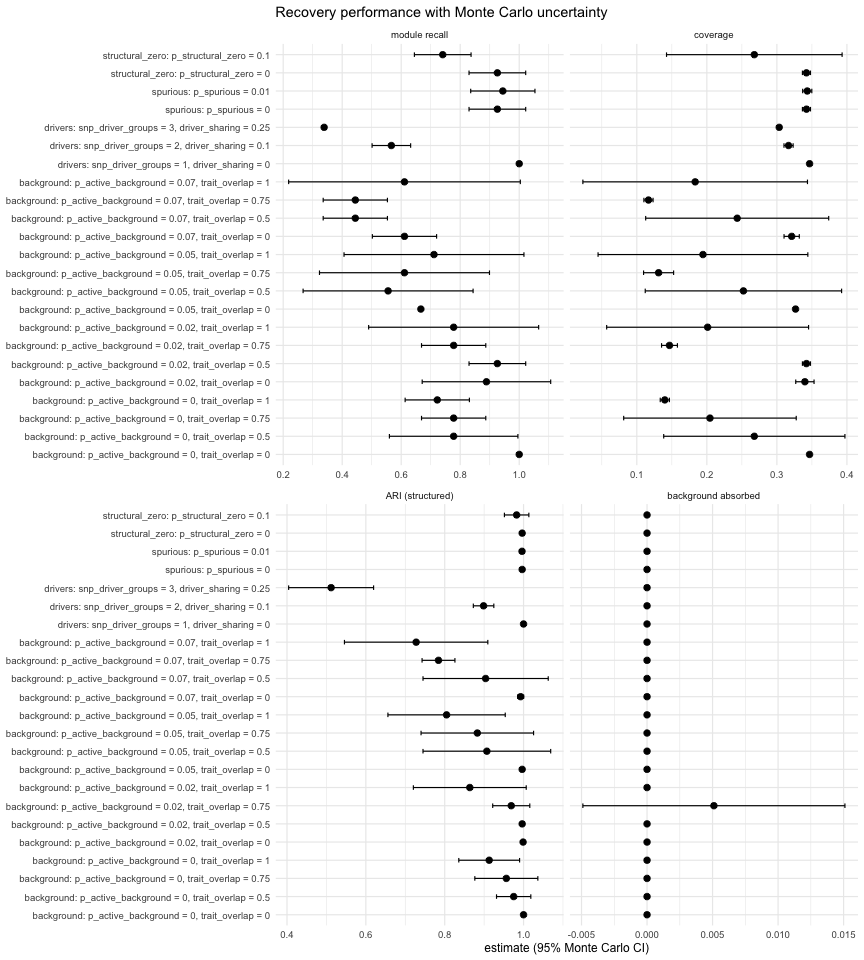

## Program-level validation checks

For each version, every program found across the replicates is listed by replicate and then by confidence tier (green high, orange medium, grey single trait, red low).

Each program is also scored against the planted module it overlaps most (on its gated SNPs): `% module found` is the fraction of that module’s SNPs the program recovered, `% module missed` its complement, and `% not module` is the fraction of the program’s SNPs that are not in that module (background or other-module SNPs pulled in). `% module found` + `% module missed` always sum to 100%. Under high `trait_overlap` a program that correctly merges two modules matches only one, so its `% not module` rises even though it is recovering real structure — read these alongside the merge-fair `module_recall` in the Aggregate table.

`similarity lift` is the member SNPs’ mean similarity over that of random SNP sets of the same size, and `factor PVE %` the share of the matrix variance the program explains; the `similarity` test compares the first against its size-matched null.

### background: p_active_background = 0, trait_overlap = 0

| rep | program | confidence | n_snps | n_snps filtered | effective traits | mean internal similarity | excess similarity | similarity q | connectedness | excess connectedness | factor PVE % | replication | matched module | % module found | % module missed | % not module |
| --- | --- | --- | --- | --- | --- | --- | --- | --- | --- | --- | --- | --- | --- | --- | --- | --- |
| 1 | 1 | high | 300 | 60 | 19.98 | 0.984 | 0.595 | 0.0003 | 1 | 0.605 | 49.31 | NA | M1 | 100% | 0% | 0% |
| 1 | 2 | high | 300 | 25 | 14.98 | 0.986 | 0.597 | 0.0003 | 1 | 0.605 | 15.51 | NA | M2 | 100% | 0% | 0% |
| 1 | 3 | high | 300 | 8 | 9.90 | 0.987 | 0.599 | 0.0010 | 1 | 0.606 | 3.45 | NA | M3 | 100% | 0% | 0% |
| 1 | 4 | high | 300 | 5 | 7.89 | 0.990 | 0.603 | 0.0010 | 1 | 0.606 | 1.77 | NA | M4 | 100% | 0% | 0% |
| 1 | 6 | medium | 300 | 3 | 2.99 | 0.990 | 0.605 | 0.0160 | 1 | 0.609 | 0.48 | NA | M6 | 100% | 0% | 0% |
| 1 | 5 | medium | 300 | 3 | 4.83 | 0.989 | 0.604 | 0.0270 | 1 | 0.609 | 0.69 | NA | M5 | 100% | 0% | 0% |
| 2 | 1 | high | 300 | 60 | 19.97 | 0.984 | 0.595 | 0.0003 | 1 | 0.604 | 49.25 | NA | M1 | 100% | 0% | 0% |
| 2 | 2 | high | 300 | 25 | 14.95 | 0.985 | 0.597 | 0.0003 | 1 | 0.605 | 15.76 | NA | M2 | 100% | 0% | 0% |
| 2 | 3 | high | 300 | 8 | 9.92 | 0.985 | 0.596 | 0.0042 | 1 | 0.604 | 3.39 | NA | M3 | 100% | 0% | 0% |
| 2 | 6 | high | 300 | 3 | 2.99 | 0.994 | 0.608 | 0.0004 | 1 | 0.607 | 0.45 | NA | M6 | 100% | 0% | 0% |
| 2 | 4 | medium | 300 | 5 | 7.88 | 0.984 | 0.592 | 0.0310 | 1 | 0.602 | 1.80 | NA | M4 | 100% | 0% | 0% |
| 2 | 5 | medium | 300 | 3 | 4.97 | 0.989 | 0.602 | 0.0200 | 1 | 0.607 | 0.63 | NA | M5 | 100% | 0% | 0% |
| 3 | 1 | high | 300 | 60 | 19.97 | 0.984 | 0.595 | 0.0003 | 1 | 0.605 | 49.93 | NA | M1 | 100% | 0% | 0% |
| 3 | 2 | high | 300 | 25 | 14.97 | 0.984 | 0.596 | 0.0003 | 1 | 0.606 | 15.49 | NA | M2 | 100% | 0% | 0% |
| 3 | 3 | high | 300 | 8 | 9.89 | 0.984 | 0.594 | 0.0082 | 1 | 0.604 | 3.24 | NA | M3 | 100% | 0% | 0% |
| 3 | 5 | high | 300 | 3 | 4.99 | 0.991 | 0.602 | 0.0034 | 1 | 0.604 | 0.70 | NA | M5 | 100% | 0% | 0% |
| 3 | 4 | medium | 300 | 5 | 7.83 | 0.983 | 0.596 | 0.0440 | 1 | 0.608 | 1.71 | NA | M4 | 100% | 0% | 0% |
| 3 | 6 | medium | 300 | 3 | 2.96 | 0.988 | 0.599 | 0.0180 | 1 | 0.604 | 0.52 | NA | M6 | 100% | 0% | 0% |

### background: p_active_background = 0, trait_overlap = 0.5

| rep | program | confidence | n_snps | n_snps filtered | effective traits | mean internal similarity | excess similarity | similarity q | connectedness | excess connectedness | factor PVE % | replication | matched module | % module found | % module missed | % not module |
| --- | --- | --- | --- | --- | --- | --- | --- | --- | --- | --- | --- | --- | --- | --- | --- | --- |
| 1 | 1 | high | 300 | 60 | 15.00 | 0.980 | 0.696 | 0.00030 | 1 | 0.502 | 53.42 | NA | M1 | 100% | 0% | 0% |
| 1 | 2 | high | 300 | 25 | 10.00 | 0.985 | 0.700 | 0.00030 | 1 | 0.502 | 18.63 | NA | M2 | 100% | 0% | 0% |
| 1 | 3 | high | 300 | 8 | 7.16 | 0.984 | 0.701 | 0.00080 | 1 | 0.503 | 3.92 | NA | M3 | 100% | 0% | 0% |
| 1 | 5 | high | 300 | 3 | 4.64 | 0.992 | 0.711 | 0.00120 | 1 | 0.504 | 0.83 | NA | M5 | 100% | 0% | 0% |
| 1 | 4 | low | 300 | 5 | 5.08 | 0.953 | 0.669 | 0.06700 | 1 | 0.503 | 1.26 | NA | M4 | 100% | 0% | 0% |
| 1 | 6 | low | 300 | 3 | 2.00 | 0.973 | 0.692 | 0.18000 | 1 | 0.504 | 0.44 | NA | M6 | 100% | 0% | 0% |
| 2 | 1 | high | 300 | 25 | 10.20 | 0.979 | 0.693 | 0.00025 | 1 | 0.478 | 36.09 | NA | M2 | 100% | 0% | 0% |
| 2 | 5 | high | 300 | 3 | 2.76 | 0.995 | 0.711 | 0.00025 | 1 | 0.481 | 1.10 | NA | M6 | 100% | 0% | 0% |
| 2 | 2 | medium | 300 | 8 | 7.16 | 0.978 | 0.692 | 0.01800 | 1 | 0.479 | 7.04 | NA | M3 | 100% | 0% | 0% |
| 2 | 3 | medium | 300 | 5 | 5.20 | 0.984 | 0.701 | 0.04100 | 1 | 0.480 | 4.36 | NA | M4 | 100% | 0% | 0% |
| 2 | 4 | low | 300 | 3 | 4.10 | 0.972 | 0.688 | 0.19000 | 1 | 0.481 | 1.65 | NA | M5 | 100% | 0% | 0% |
| 3 | 1 | high | 300 | 60 | 17.57 | 0.978 | 0.701 | 0.00030 | 1 | 0.465 | 50.33 | NA | M1 | 100% | 0% | 0% |
| 3 | 2 | high | 300 | 25 | 12.89 | 0.985 | 0.708 | 0.00030 | 1 | 0.466 | 18.84 | NA | M2 | 100% | 0% | 0% |
| 3 | 3 | high | 300 | 8 | 8.03 | 0.982 | 0.705 | 0.00080 | 1 | 0.467 | 4.41 | NA | M3 | 100% | 0% | 0% |
| 3 | 4 | high | 300 | 5 | 7.52 | 0.989 | 0.713 | 0.00040 | 1 | 0.465 | 2.59 | NA | M4 | 100% | 0% | 0% |
| 3 | 5 | high | 300 | 3 | 4.10 | 0.991 | 0.712 | 0.00080 | 1 | 0.464 | 0.76 | NA | M5 | 100% | 0% | 0% |
| 3 | 6 | high | 300 | 3 | 2.99 | 0.991 | 0.712 | 0.00080 | 1 | 0.464 | 0.47 | NA | M6 | 100% | 0% | 0% |

### background: p_active_background = 0, trait_overlap = 0.75

| rep | program | confidence | n_snps | n_snps filtered | effective traits | mean internal similarity | excess similarity | similarity q | connectedness | excess connectedness | factor PVE % | replication | matched module | % module found | % module missed | % not module |
| --- | --- | --- | --- | --- | --- | --- | --- | --- | --- | --- | --- | --- | --- | --- | --- | --- |
| 1 | 1 | high | 300 | 60 | 16.43 | 0.983 | 0.739 | 0.0003 | 1 | 0.465 | 56.86 | NA | M1 | 100% | 0% | 0% |
| 1 | 2 | high | 300 | 25 | 9.50 | 0.985 | 0.741 | 0.0003 | 1 | 0.465 | 20.40 | NA | M2 | 100% | 0% | 0% |
| 1 | 3 | high | 300 | 8 | 5.99 | 0.987 | 0.745 | 0.0008 | 1 | 0.466 | 3.89 | NA | M3 | 100% | 0% | 0% |
| 1 | 6 | high | 300 | 3 | 2.00 | 0.992 | 0.752 | 0.0019 | 1 | 0.467 | 0.44 | NA | M6 | 100% | 0% | 0% |
| 1 | 5 | high | 300 | 3 | 3.26 | 0.991 | 0.751 | 0.0054 | 1 | 0.467 | 0.78 | NA | M5 | 100% | 0% | 0% |
| 1 | 4 | low | 300 | 5 | 5.41 | 0.970 | 0.727 | 0.0560 | 1 | 0.466 | 1.05 | NA | M4 | 100% | 0% | 0% |
| 2 | 1 | high | 300 | 30 | 13.84 | 0.832 | 0.581 | 0.0004 | 1 | 0.441 | 42.82 | NA | M2 | 100% | 0% | 17% |
| 2 | 2 | medium | 300 | 11 | 8.27 | 0.805 | 0.556 | 0.0160 | 1 | 0.443 | 6.20 | NA | M3 | 100% | 0% | 27% |
| 2 | 3 | low | 300 | 5 | 7.06 | 0.981 | 0.732 | 0.0540 | 1 | 0.444 | 3.50 | NA | M4 | 100% | 0% | 0% |
| 2 | 4 | low | 300 | 3 | 2.71 | 0.955 | 0.703 | 0.2000 | 1 | 0.441 | 1.40 | NA | M6 | 100% | 0% | 0% |
| 3 | 1 | high | 300 | 25 | 10.01 | 0.982 | 0.729 | 0.0002 | 1 | 0.438 | 42.68 | NA | M2 | 100% | 0% | 0% |
| 3 | 2 | high | 300 | 8 | 11.19 | 0.989 | 0.736 | 0.0002 | 1 | 0.438 | 8.05 | NA | M3 | 100% | 0% | 0% |
| 3 | 3 | medium | 300 | 8 | 6.27 | 0.703 | 0.450 | 0.0370 | 1 | 0.438 | 6.16 | NA | M4 | 100% | 0% | 38% |
| 3 | 4 | medium | 300 | 3 | 3.63 | 0.988 | 0.735 | 0.0270 | 1 | 0.438 | 1.86 | NA | M5 | 100% | 0% | 0% |

### background: p_active_background = 0, trait_overlap = 1

| rep | program | confidence | n_snps | n_snps filtered | effective traits | mean internal similarity | excess similarity | similarity q | connectedness | excess connectedness | factor PVE % | replication | matched module | % module found | % module missed | % not module |
| --- | --- | --- | --- | --- | --- | --- | --- | --- | --- | --- | --- | --- | --- | --- | --- | --- |
| 1 | 1 | high | 300 | 28 | 9.00 | 0.883 | 0.700 | 0.0004 | 1.000 | 0.476 | 39.11 | NA | M2 | 100% | 0% | 11% |
| 1 | 3 | high | 300 | 5 | 3.29 | 0.984 | 0.810 | 0.0028 | 1.000 | 0.480 | 6.85 | NA | M4 | 100% | 0% | 0% |
| 1 | 2 | medium | 300 | 8 | 4.57 | 0.971 | 0.791 | 0.0140 | 1.000 | 0.477 | 8.41 | NA | M3 | 100% | 0% | 0% |
| 1 | 4 | low | 300 | 3 | 3.17 | 0.972 | 0.798 | 0.1700 | 1.000 | 0.481 | 2.74 | NA | M5 | 100% | 0% | 0% |
| 2 | 1 | high | 300 | 33 | 6.60 | 0.808 | 0.629 | 0.0004 | 1.000 | 0.436 | 33.94 | NA | M2 | 100% | 0% | 24% |
| 2 | 2 | medium | 300 | 8 | 8.32 | 0.963 | 0.786 | 0.0230 | 1.000 | 0.437 | 7.48 | NA | M3 | 100% | 0% | 0% |
| 2 | 3 | medium | 300 | 8 | 5.76 | 0.804 | 0.628 | 0.0290 | 1.000 | 0.437 | 6.49 | NA | M4 | 100% | 0% | 38% |
| 2 | 4 | medium | 300 | 3 | 2.60 | 0.987 | 0.807 | 0.0290 | 1.000 | 0.436 | 3.09 | NA | M5 | 100% | 0% | 0% |
| 3 | 1 | high | 300 | 33 | 7.84 | 0.650 | 0.389 | 0.0004 | 0.830 | 0.283 | 44.64 | NA | M2 | 100% | 0% | 24% |
| 3 | 2 | medium | 300 | 8 | 4.13 | 0.963 | 0.703 | 0.0220 | 1.000 | 0.455 | 8.77 | NA | M3 | 100% | 0% | 0% |
| 3 | 4 | low | 300 | 6 | 1.87 | 0.096 | -0.166 | 0.9700 | 0.400 | -0.147 | 3.41 | NA | M5 | 100% | 0% | 50% |
| 3 | 3 | low | 300 | 8 | 5.65 | 0.006 | -0.254 | 0.9700 | 0.464 | -0.081 | 3.85 | NA | M4 | 100% | 0% | 38% |

### background: p_active_background = 0.02, trait_overlap = 0

| rep | program | confidence | n_snps | n_snps filtered | effective traits | mean internal similarity | excess similarity | similarity q | connectedness | excess connectedness | factor PVE % | replication | matched module | % module found | % module missed | % not module |
| --- | --- | --- | --- | --- | --- | --- | --- | --- | --- | --- | --- | --- | --- | --- | --- | --- |
| 1 | 1 | high | 300 | 60 | 19.98 | 0.808 | 0.770 | 0.00110 | 1.000 | 0.940 | 17.40 | NA | M1 | 100% | 0% | 0% |
| 1 | 2 | high | 300 | 25 | 14.98 | 0.773 | 0.736 | 0.00110 | 1.000 | 0.941 | 5.47 | NA | M2 | 100% | 0% | 0% |
| 1 | 3 | high | 300 | 8 | 9.90 | 0.669 | 0.631 | 0.00110 | 1.000 | 0.940 | 1.22 | NA | M3 | 100% | 0% | 0% |
| 1 | 5 | high | 300 | 5 | 8.40 | 0.616 | 0.579 | 0.00160 | 1.000 | 0.942 | 0.64 | NA | M4 | 100% | 0% | 0% |
| 1 | 12 | low | 300 | 3 | 4.88 | 0.650 | 0.612 | 0.05400 | 1.000 | 0.941 | 0.25 | NA | M5 | 100% | 0% | 0% |
| 1 | 15 | low | 300 | 9 | 1.00 | 0.220 | 0.182 | 0.07800 | 0.306 | 0.245 | 0.22 | NA | M1 | 8% | 92% | 44% |
| 1 | 30 | low | 300 | 5 | 1.00 | 0.228 | 0.192 | 0.18000 | 0.500 | 0.442 | 0.19 | NA | M1 | 5% | 95% | 40% |
| 1 | 11 | low | 300 | 10 | 1.00 | 0.121 | 0.084 | 0.18000 | 0.378 | 0.318 | 0.26 | NA | M1 | 5% | 95% | 70% |
| 1 | 17 | low | 300 | 3 | 4.68 | 0.247 | 0.210 | 0.29000 | 0.667 | 0.608 | 0.21 | NA | M6 | 100% | 0% | 0% |
| 1 | 33 | low | 300 | 9 | 1.00 | 0.124 | 0.086 | 0.25000 | 0.194 | 0.134 | 0.14 | NA | M1 | 7% | 93% | 56% |
| 1 | 9 | low | 300 | 8 | 1.00 | 0.110 | 0.072 | 0.25000 | 0.357 | 0.297 | 0.26 | NA | M1 | 5% | 95% | 62% |
| 1 | 22 | low | 300 | 10 | 1.00 | 0.092 | 0.054 | 0.34000 | 0.444 | 0.385 | 0.20 | NA | M1 | 2% | 98% | 90% |
| 1 | 6 | low | 300 | 21 | 1.00 | 0.063 | 0.026 | 0.37000 | 0.162 | 0.102 | 0.40 | NA | M1 | 12% | 88% | 67% |
| 1 | 32 | low | 300 | 4 | 1.28 | 0.081 | 0.045 | 0.51000 | 0.333 | 0.275 | 0.18 | NA | M1 | 3% | 97% | 50% |
| 1 | 16 | low | 300 | 7 | 1.00 | 0.045 | 0.007 | 0.59000 | 0.190 | 0.130 | 0.21 | NA | M1 | 3% | 97% | 71% |
| 1 | 27 | low | 300 | 6 | 1.00 | 0.035 | -0.003 | 0.78000 | 0.200 | 0.140 | 0.16 | NA | M1 | 3% | 97% | 67% |
| 1 | 25 | low | 300 | 5 | 1.32 | 0.022 | -0.015 | 0.78000 | 0.300 | 0.242 | 0.17 | NA | M3 | 12% | 88% | 80% |
| 1 | 26 | low | 300 | 6 | 1.00 | 0.024 | -0.014 | 0.80000 | 0.133 | 0.073 | 0.17 | NA | M2 | 8% | 92% | 67% |
| 1 | 20 | low | 300 | 9 | 1.00 | 0.025 | -0.014 | 0.80000 | 0.222 | 0.162 | 0.20 | NA | M1 | 3% | 97% | 78% |
| 1 | 8 | low | 300 | 15 | 1.00 | 0.026 | -0.011 | 0.85000 | 0.190 | 0.131 | 0.32 | NA | M1 | 5% | 95% | 80% |
| 1 | 31 | low | 300 | 7 | 1.00 | 0.001 | -0.037 | 1.00000 | 0.238 | 0.178 | 0.15 | NA | M1 | 2% | 98% | 86% |
| 1 | 28 | low | 300 | 9 | 1.00 | 0.006 | -0.032 | 1.00000 | 0.167 | 0.106 | 0.16 | NA | M1 | 3% | 97% | 78% |
| 1 | 23 | low | 300 | 6 | 1.00 | -0.007 | -0.045 | 1.00000 | 0.067 | 0.006 | 0.20 | NA | M1 | 2% | 98% | 83% |
| 1 | 18 | low | 300 | 4 | 2.45 | -0.030 | -0.066 | 1.00000 | 0.333 | 0.275 | 0.20 | NA | M1 | 2% | 98% | 75% |
| 1 | 14 | low | 300 | 9 | 1.00 | -0.009 | -0.048 | 1.00000 | 0.194 | 0.134 | 0.22 | NA | M1 | 2% | 98% | 89% |
| 1 | 29 | low | 300 | 7 | 1.00 | -0.020 | -0.058 | 1.00000 | 0.095 | 0.035 | 0.19 | NA | M1 | 2% | 98% | 86% |
| 1 | 7 | low | 300 | 16 | 1.00 | 0.004 | -0.034 | 1.00000 | 0.175 | 0.115 | 0.30 | NA | M1 | 3% | 97% | 88% |
| 1 | 13 | low | 300 | 12 | 1.00 | -0.009 | -0.046 | 1.00000 | 0.167 | 0.108 | 0.26 | NA | M1 | 3% | 97% | 83% |
| 1 | 19 | low | 300 | 6 | 1.00 | -0.041 | -0.079 | 1.00000 | 0.400 | 0.340 | 0.18 | NA | M1 | 0% | 100% | 100% |
| 1 | 10 | low | 300 | 14 | 1.00 | -0.008 | -0.045 | 1.00000 | 0.198 | 0.139 | 0.26 | NA | M2 | 8% | 92% | 86% |

[output cut: 51 more lines]

### background: p_active_background = 0.02, trait_overlap = 0.5

| rep | program | confidence | n_snps | n_snps filtered | effective traits | mean internal similarity | excess similarity | similarity q | connectedness | excess connectedness | factor PVE % | replication | matched module | % module found | % module missed | % not module |
| --- | --- | --- | --- | --- | --- | --- | --- | --- | --- | --- | --- | --- | --- | --- | --- | --- |
| 1 | 1 | high | 300 | 60 | 15.00 | 0.765 | 0.738 | 0.00087 | 1.000 | 0.932 | 16.74 | NA | M1 | 100% | 0% | 0% |
| 1 | 2 | high | 300 | 25 | 9.92 | 0.719 | 0.693 | 0.00087 | 1.000 | 0.933 | 5.85 | NA | M2 | 100% | 0% | 0% |
| 1 | 3 | high | 300 | 8 | 7.25 | 0.665 | 0.639 | 0.00087 | 1.000 | 0.932 | 1.24 | NA | M3 | 100% | 0% | 0% |
| 1 | 8 | medium | 300 | 5 | 5.45 | 0.440 | 0.414 | 0.03000 | 1.000 | 0.933 | 0.41 | NA | M4 | 100% | 0% | 0% |
| 1 | 15 | medium | 300 | 3 | 5.19 | 0.593 | 0.565 | 0.04500 | 1.000 | 0.931 | 0.27 | NA | M5 | 100% | 0% | 0% |
| 1 | 11 | low | 300 | 9 | 1.53 | 0.129 | 0.103 | 0.14000 | 0.278 | 0.211 | 0.29 | NA | M1 | 7% | 93% | 56% |
| 1 | 12 | low | 300 | 14 | 1.00 | 0.101 | 0.075 | 0.14000 | 0.231 | 0.163 | 0.28 | NA | M1 | 10% | 90% | 57% |
| 1 | 21 | low | 300 | 5 | 1.43 | 0.168 | 0.143 | 0.16000 | 0.600 | 0.533 | 0.18 | NA | M2 | 4% | 96% | 80% |
| 1 | 27 | low | 300 | 10 | 1.00 | 0.090 | 0.064 | 0.21000 | 0.200 | 0.134 | 0.17 | NA | M1 | 7% | 93% | 60% |
| 1 | 14 | low | 300 | 4 | 4.30 | 0.081 | 0.054 | 0.47000 | 0.500 | 0.432 | 0.27 | NA | M2 | 4% | 96% | 75% |
| 1 | 17 | low | 300 | 13 | 1.00 | 0.037 | 0.011 | 0.62000 | 0.218 | 0.151 | 0.27 | NA | M2 | 12% | 88% | 77% |
| 1 | 22 | low | 300 | 5 | 1.24 | 0.036 | 0.010 | 0.62000 | 0.200 | 0.133 | 0.16 | NA | M1 | 3% | 97% | 60% |
| 1 | 9 | low | 300 | 15 | 1.00 | 0.027 | 0.001 | 0.69000 | 0.219 | 0.151 | 0.37 | NA | M1 | 7% | 93% | 73% |
| 1 | 19 | low | 300 | 12 | 1.00 | 0.025 | -0.001 | 0.69000 | 0.106 | 0.038 | 0.21 | NA | M1 | 5% | 95% | 75% |
| 1 | 26 | low | 300 | 7 | 1.00 | 0.007 | -0.019 | 0.94000 | 0.333 | 0.266 | 0.17 | NA | M2 | 4% | 96% | 86% |
| 1 | 20 | low | 300 | 6 | 1.00 | 0.000 | -0.028 | 0.94000 | 0.267 | 0.198 | 0.21 | NA | M1 | 3% | 97% | 67% |
| 1 | 7 | low | 300 | 17 | 1.00 | 0.014 | -0.013 | 0.94000 | 0.191 | 0.124 | 0.43 | NA | M1 | 5% | 95% | 82% |
| 1 | 5 | low | 300 | 39 | 1.00 | 0.018 | -0.009 | 0.94000 | 0.148 | 0.081 | 0.75 | NA | M1 | 12% | 88% | 82% |
| 1 | 10 | low | 300 | 15 | 1.00 | 0.003 | -0.024 | 0.99000 | 0.171 | 0.104 | 0.33 | NA | M1 | 5% | 95% | 80% |
| 1 | 6 | low | 300 | 21 | 1.00 | 0.006 | -0.020 | 0.99000 | 0.186 | 0.119 | 0.49 | NA | M2 | 16% | 84% | 81% |
| 1 | 13 | low | 300 | 17 | 1.00 | 0.003 | -0.023 | 0.99000 | 0.125 | 0.057 | 0.32 | NA | M1 | 5% | 95% | 82% |
| 1 | 28 | low | 300 | 9 | 1.00 | -0.012 | -0.038 | 0.99000 | 0.194 | 0.128 | 0.19 | NA | M2 | 8% | 92% | 78% |
| 1 | 16 | low | 300 | 11 | 1.00 | -0.011 | -0.038 | 0.99000 | 0.182 | 0.114 | 0.30 | NA | M1 | 3% | 97% | 82% |
| 1 | 24 | low | 300 | 6 | 1.00 | -0.042 | -0.069 | 0.99000 | 0.200 | 0.131 | 0.17 | NA | M1 | 2% | 98% | 83% |
| 1 | 4 | low | 300 | 53 | 1.00 | 0.011 | -0.015 | 0.99000 | 0.123 | 0.057 | 0.84 | NA | M2 | 32% | 68% | 85% |
| 1 | 18 | low | 300 | 4 | 2.47 | -0.086 | -0.113 | 0.99000 | 0.333 | 0.266 | 0.22 | NA | M1 | 2% | 98% | 75% |
| 2 | 1 | high | 300 | 60 | 15.54 | 0.782 | 0.755 | 0.00083 | 1.000 | 0.937 | 17.38 | NA | M1 | 100% | 0% | 0% |
| 2 | 2 | high | 300 | 25 | 10.20 | 0.694 | 0.667 | 0.00083 | 1.000 | 0.938 | 4.92 | NA | M2 | 100% | 0% | 0% |
| 2 | 3 | high | 300 | 8 | 7.16 | 0.577 | 0.550 | 0.00083 | 1.000 | 0.937 | 0.96 | NA | M3 | 100% | 0% | 0% |
| 2 | 6 | medium | 300 | 7 | 5.79 | 0.372 | 0.343 | 0.01100 | 0.667 | 0.603 | 0.64 | NA | M4 | 100% | 0% | 29% |
| 2 | 15 | medium | 300 | 3 | 5.32 | 0.483 | 0.454 | 0.04300 | 1.000 | 0.935 | 0.26 | NA | M5 | 100% | 0% | 0% |
| 2 | 14 | low | 300 | 10 | 1.00 | 0.170 | 0.143 | 0.06900 | 0.267 | 0.204 | 0.26 | NA | M1 | 8% | 92% | 50% |
| 2 | 21 | low | 300 | 9 | 1.00 | 0.167 | 0.139 | 0.07000 | 0.278 | 0.214 | 0.18 | NA | M1 | 5% | 95% | 67% |
| 2 | 4 | low | 300 | 26 | 1.00 | 0.075 | 0.047 | 0.12000 | 0.274 | 0.211 | 0.67 | NA | M1 | 12% | 88% | 73% |
| 2 | 13 | low | 300 | 10 | 1.00 | 0.108 | 0.080 | 0.15000 | 0.267 | 0.204 | 0.25 | NA | M1 | 7% | 93% | 60% |
| 2 | 9 | low | 300 | 15 | 1.00 | 0.052 | 0.025 | 0.41000 | 0.162 | 0.099 | 0.32 | NA | M1 | 8% | 92% | 67% |
| 2 | 22 | low | 300 | 5 | 1.00 | 0.061 | 0.033 | 0.47000 | 0.200 | 0.137 | 0.18 | NA | M1 | 3% | 97% | 60% |
| 2 | 19 | low | 300 | 10 | 1.25 | 0.032 | 0.005 | 0.60000 | 0.178 | 0.115 | 0.28 | NA | M1 | 3% | 97% | 80% |
| 2 | 25 | low | 300 | 5 | 1.32 | 0.033 | 0.005 | 0.60000 | 0.100 | 0.037 | 0.15 | NA | M2 | 8% | 92% | 60% |
| 2 | 7 | low | 300 | 22 | 1.00 | 0.023 | -0.004 | 0.83000 | 0.182 | 0.119 | 0.45 | NA | M1 | 8% | 92% | 77% |
| 2 | 23 | low | 300 | 3 | 3.42 | -0.004 | -0.033 | 0.94000 | 0.333 | 0.268 | 0.16 | NA | M1 | 2% | 98% | 67% |
| 2 | 18 | low | 300 | 11 | 1.00 | 0.010 | -0.017 | 0.94000 | 0.091 | 0.028 | 0.23 | NA | M2 | 12% | 88% | 73% |
| 2 | 20 | low | 300 | 7 | 1.18 | -0.010 | -0.038 | 1.00000 | 0.048 | -0.016 | 0.20 | NA | M1 | 2% | 98% | 86% |
| 2 | 24 | low | 300 | 4 | 1.20 | -0.038 | -0.065 | 1.00000 | 0.000 | -0.062 | 0.13 | NA | M2 | 4% | 96% | 75% |
| 2 | 12 | low | 300 | 10 | 1.00 | -0.009 | -0.036 | 1.00000 | 0.311 | 0.248 | 0.27 | NA | M3 | 25% | 75% | 80% |
| 2 | 5 | low | 300 | 28 | 1.00 | 0.009 | -0.019 | 1.00000 | 0.169 | 0.106 | 0.56 | NA | M1 | 8% | 92% | 82% |
| 2 | 8 | low | 300 | 20 | 1.00 | 0.003 | -0.024 | 1.00000 | 0.211 | 0.148 | 0.49 | NA | M2 | 16% | 84% | 80% |
| 2 | 16 | low | 300 | 9 | 1.00 | -0.018 | -0.046 | 1.00000 | 0.111 | 0.048 | 0.24 | NA | M1 | 3% | 97% | 78% |
| 2 | 11 | low | 300 | 16 | 1.00 | -0.005 | -0.033 | 1.00000 | 0.125 | 0.062 | 0.34 | NA | M1 | 3% | 97% | 88% |
| 2 | 17 | low | 300 | 8 | 1.00 | -0.036 | -0.063 | 1.00000 | 0.286 | 0.223 | 0.24 | NA | M1 | 0% | 100% | 100% |
| 2 | 10 | low | 300 | 15 | 1.00 | -0.018 | -0.045 | 1.00000 | 0.314 | 0.251 | 0.36 | NA | M2 | 4% | 96% | 93% |
| 3 | 1 | high | 300 | 60 | 17.57 | 0.785 | 0.758 | 0.00077 | 1.000 | 0.930 | 15.88 | NA | M1 | 100% | 0% | 0% |
| 3 | 2 | high | 300 | 25 | 12.89 | 0.776 | 0.749 | 0.00077 | 1.000 | 0.930 | 5.95 | NA | M2 | 100% | 0% | 0% |
| 3 | 3 | high | 300 | 8 | 8.11 | 0.734 | 0.707 | 0.00077 | 1.000 | 0.930 | 1.40 | NA | M3 | 100% | 0% | 0% |
| 3 | 5 | high | 300 | 8 | 7.46 | 0.384 | 0.356 | 0.00800 | 0.893 | 0.822 | 0.88 | NA | M4 | 100% | 0% | 38% |
| 3 | 15 | medium | 300 | 3 | 5.18 | 0.478 | 0.452 | 0.03400 | 1.000 | 0.930 | 0.27 | NA | M5 | 100% | 0% | 0% |
| 3 | 13 | low | 300 | 9 | 1.00 | 0.154 | 0.127 | 0.07900 | 0.500 | 0.430 | 0.24 | NA | M2 | 8% | 92% | 78% |
| 3 | 6 | low | 300 | 18 | 1.00 | 0.083 | 0.057 | 0.15000 | 0.255 | 0.185 | 0.41 | NA | M1 | 8% | 92% | 72% |
| 3 | 12 | low | 300 | 10 | 1.00 | 0.069 | 0.042 | 0.33000 | 0.289 | 0.220 | 0.26 | NA | M1 | 3% | 97% | 80% |
| 3 | 11 | low | 300 | 14 | 1.00 | 0.052 | 0.025 | 0.33000 | 0.154 | 0.084 | 0.27 | NA | M1 | 8% | 92% | 64% |
| 3 | 8 | low | 300 | 14 | 1.00 | 0.050 | 0.023 | 0.33000 | 0.330 | 0.260 | 0.38 | NA | M1 | 7% | 93% | 71% |
| 3 | 17 | low | 300 | 9 | 1.00 | 0.053 | 0.026 | 0.33000 | 0.194 | 0.124 | 0.19 | NA | M2 | 8% | 92% | 78% |
| 3 | 21 | low | 300 | 6 | 1.22 | 0.059 | 0.031 | 0.33000 | 0.267 | 0.196 | 0.19 | NA | M1 | 5% | 95% | 50% |
| 3 | 23 | low | 300 | 3 | 1.99 | 0.068 | 0.041 | 0.33000 | 0.333 | 0.263 | 0.17 | NA | M1 | 3% | 97% | 33% |
| 3 | 4 | low | 300 | 29 | 1.00 | 0.028 | 0.001 | 0.63000 | 0.217 | 0.147 | 0.65 | NA | M1 | 12% | 88% | 76% |
| 3 | 9 | low | 300 | 17 | 1.00 | 0.022 | -0.005 | 0.70000 | 0.279 | 0.209 | 0.37 | NA | M1 | 7% | 93% | 76% |
| 3 | 10 | low | 300 | 15 | 1.00 | 0.015 | -0.012 | 0.82000 | 0.181 | 0.111 | 0.29 | NA | M1 | 5% | 95% | 80% |
| 3 | 20 | low | 300 | 10 | 1.00 | 0.002 | -0.025 | 0.98000 | 0.133 | 0.064 | 0.19 | NA | M2 | 8% | 92% | 80% |
| 3 | 18 | low | 300 | 9 | 1.00 | -0.009 | -0.036 | 0.99000 | 0.306 | 0.236 | 0.20 | NA | M1 | 3% | 97% | 78% |
| 3 | 19 | low | 300 | 8 | 1.00 | -0.013 | -0.041 | 0.99000 | 0.214 | 0.144 | 0.24 | NA | M1 | 3% | 97% | 75% |
| 3 | 7 | low | 300 | 17 | 1.00 | 0.002 | -0.025 | 0.99000 | 0.235 | 0.164 | 0.43 | NA | M1 | 5% | 95% | 82% |
| 3 | 14 | low | 300 | 6 | 1.74 | -0.031 | -0.058 | 0.99000 | 0.133 | 0.062 | 0.18 | NA | M2 | 4% | 96% | 83% |
| 3 | 16 | low | 300 | 6 | 1.00 | -0.044 | -0.072 | 0.99000 | 0.200 | 0.129 | 0.17 | NA | M1 | 2% | 98% | 83% |
| 3 | 22 | low | 300 | 10 | 1.00 | -0.025 | -0.051 | 0.99000 | 0.222 | 0.153 | 0.19 | NA | M1 | 2% | 98% | 90% |

### background: p_active_background = 0.02, trait_overlap = 0.75

| rep | program | confidence | n_snps | n_snps filtered | effective traits | mean internal similarity | excess similarity | similarity q | connectedness | excess connectedness | factor PVE % | replication | matched module | % module found | % module missed | % not module |
| --- | --- | --- | --- | --- | --- | --- | --- | --- | --- | --- | --- | --- | --- | --- | --- | --- |
| 1 | 1 | high | 300 | 25 | 16.44 | 0.827 | 0.802 | 0.00090 | 1.000 | 0.930 | 6.16 | NA | M2 | 100% | 0% | 0% |
| 1 | 2 | high | 300 | 8 | 12.39 | 0.707 | 0.682 | 0.00090 | 1.000 | 0.930 | 1.32 | NA | M3 | 100% | 0% | 0% |
| 1 | 3 | medium | 300 | 5 | 6.30 | 0.434 | 0.409 | 0.04000 | 1.000 | 0.930 | 0.46 | NA | M4 | 100% | 0% | 0% |
| 1 | 10 | medium | 300 | 3 | 3.29 | 0.701 | 0.675 | 0.04500 | 1.000 | 0.929 | 0.32 | NA | M5 | 100% | 0% | 0% |
| 1 | 7 | medium | 300 | 3 | 4.09 | 0.358 | 0.332 | 0.04600 | 1.000 | 0.929 | 0.26 | NA | M1 | 0% | 100% | 100% |
| 1 | 14 | medium | 300 | 3 | 2.27 | 0.347 | 0.321 | 0.04600 | 0.667 | 0.596 | 0.19 | NA | M6 | 100% | 0% | 0% |
| 1 | 5 | single_trait | 300 | 13 | 1.00 | 0.147 | 0.122 | 0.04800 | 0.333 | 0.264 | 0.32 | NA | M1 | 8% | 92% | 62% |
| 1 | 12 | low | 300 | 4 | 1.84 | 0.291 | 0.266 | 0.05400 | 0.667 | 0.597 | 0.20 | NA | M1 | 2% | 98% | 75% |
| 1 | 18 | low | 300 | 4 | 2.84 | 0.193 | 0.168 | 0.07500 | 0.333 | 0.264 | 0.17 | NA | M1 | 3% | 97% | 50% |
| 1 | 13 | low | 300 | 5 | 1.00 | 0.051 | 0.026 | 0.43000 | 0.400 | 0.330 | 0.22 | NA | M1 | 2% | 98% | 80% |
| 1 | 17 | low | 300 | 4 | 1.00 | 0.026 | 0.001 | 0.47000 | 0.500 | 0.431 | 0.16 | NA | M1 | 0% | 100% | 100% |
| 1 | 8 | low | 300 | 7 | 1.00 | 0.024 | 0.001 | 0.52000 | 0.238 | 0.171 | 0.23 | NA | M1 | 3% | 97% | 71% |
| 1 | 4 | low | 300 | 15 | 1.00 | 0.015 | -0.009 | 0.65000 | 0.219 | 0.150 | 0.46 | NA | M1 | 7% | 93% | 73% |
| 1 | 11 | low | 300 | 8 | 1.00 | 0.005 | -0.020 | 0.68000 | 0.286 | 0.215 | 0.24 | NA | M1 | 3% | 97% | 75% |
| 1 | 6 | low | 300 | 7 | 1.00 | 0.001 | -0.023 | 0.68000 | 0.286 | 0.218 | 0.27 | NA | M1 | 5% | 95% | 57% |
| 1 | 15 | low | 300 | 4 | 1.78 | -0.018 | -0.043 | 0.85000 | 0.500 | 0.431 | 0.19 | NA | M4 | 20% | 80% | 75% |
| 1 | 16 | low | 300 | 4 | 1.33 | -0.097 | -0.121 | 0.98000 | 0.000 | -0.069 | 0.15 | NA | M2 | 4% | 96% | 75% |
| 1 | 19 | low | 300 | 3 | 1.07 | -0.175 | -0.201 | 0.98000 | 0.333 | 0.263 | 0.18 | NA | M1 | 0% | 100% | 100% |
| 2 | 1 | high | 300 | 25 | 14.18 | 0.757 | 0.734 | 0.00250 | 1.000 | 0.923 | 5.56 | NA | M2 | 100% | 0% | 0% |
| 2 | 3 | high | 300 | 11 | 5.15 | 0.405 | 0.381 | 0.00250 | 0.982 | 0.904 | 1.15 | NA | M3 | 100% | 0% | 27% |
| 2 | 8 | high | 300 | 5 | 4.68 | 0.621 | 0.599 | 0.00330 | 1.000 | 0.923 | 0.65 | NA | M4 | 100% | 0% | 0% |
| 2 | 20 | low | 300 | 5 | 1.51 | 0.296 | 0.274 | 0.05600 | 0.500 | 0.423 | 0.17 | NA | M1 | 5% | 95% | 40% |
| 2 | 6 | low | 300 | 24 | 1.00 | 0.096 | 0.074 | 0.05800 | 0.221 | 0.144 | 0.55 | NA | M1 | 15% | 85% | 62% |
| 2 | 21 | low | 300 | 3 | 5.84 | 0.220 | 0.197 | 0.32000 | 0.667 | 0.591 | 0.26 | NA | M6 | 100% | 0% | 0% |
| 2 | 23 | low | 300 | 3 | 1.29 | 0.207 | 0.184 | 0.32000 | 0.333 | 0.257 | 0.19 | NA | M1 | 2% | 98% | 67% |
| 2 | 18 | low | 300 | 6 | 1.19 | 0.096 | 0.074 | 0.32000 | 0.200 | 0.123 | 0.20 | NA | M1 | 5% | 95% | 50% |
| 2 | 2 | low | 300 | 54 | 1.00 | 0.036 | 0.014 | 0.35000 | 0.165 | 0.088 | 1.13 | NA | M1 | 25% | 75% | 72% |
| 2 | 25 | low | 300 | 7 | 1.00 | 0.067 | 0.045 | 0.35000 | 0.333 | 0.257 | 0.17 | NA | M2 | 8% | 92% | 71% |
| 2 | 5 | low | 300 | 26 | 1.00 | 0.036 | 0.013 | 0.43000 | 0.209 | 0.132 | 0.68 | NA | M1 | 10% | 90% | 77% |
| 2 | 10 | low | 300 | 12 | 1.57 | 0.042 | 0.020 | 0.43000 | 0.242 | 0.166 | 0.37 | NA | M1 | 5% | 95% | 75% |
| 2 | 17 | low | 300 | 6 | 1.00 | 0.026 | 0.003 | 0.64000 | 0.200 | 0.123 | 0.21 | NA | M1 | 3% | 97% | 67% |
| 2 | 11 | low | 300 | 12 | 1.00 | 0.020 | -0.002 | 0.68000 | 0.197 | 0.120 | 0.33 | NA | M2 | 12% | 88% | 75% |
| 2 | 7 | low | 300 | 20 | 1.00 | 0.017 | -0.005 | 0.76000 | 0.216 | 0.139 | 0.49 | NA | M1 | 7% | 93% | 80% |
| 2 | 16 | low | 300 | 5 | 1.23 | -0.002 | -0.024 | 0.83000 | 0.200 | 0.123 | 0.21 | NA | M3 | 12% | 88% | 80% |
| 2 | 9 | low | 300 | 16 | 1.00 | 0.012 | -0.011 | 0.83000 | 0.242 | 0.165 | 0.45 | NA | M1 | 5% | 95% | 81% |
| 2 | 22 | low | 300 | 10 | 1.00 | -0.002 | -0.025 | 0.99000 | 0.156 | 0.078 | 0.19 | NA | M1 | 3% | 97% | 80% |
| 2 | 24 | low | 300 | 5 | 1.00 | -0.036 | -0.058 | 0.99000 | 0.000 | -0.077 | 0.15 | NA | M1 | 2% | 98% | 80% |
| 2 | 4 | low | 300 | 29 | 1.00 | 0.006 | -0.017 | 0.99000 | 0.101 | 0.023 | 0.65 | NA | M1 | 7% | 93% | 86% |
| 2 | 26 | low | 300 | 3 | 2.82 | -0.082 | -0.106 | 0.99000 | 0.333 | 0.257 | 0.15 | NA | M2 | 4% | 96% | 67% |
| 2 | 14 | low | 300 | 11 | 1.00 | -0.016 | -0.039 | 0.99000 | 0.218 | 0.141 | 0.28 | NA | M3 | 12% | 88% | 91% |
| 2 | 15 | low | 300 | 8 | 1.00 | -0.035 | -0.058 | 0.99000 | 0.107 | 0.029 | 0.23 | NA | M2 | 8% | 92% | 75% |
| 2 | 13 | low | 300 | 9 | 1.00 | -0.031 | -0.053 | 0.99000 | 0.111 | 0.034 | 0.28 | NA | M1 | 2% | 98% | 89% |
| 2 | 12 | low | 300 | 9 | 1.00 | -0.032 | -0.055 | 0.99000 | 0.361 | 0.284 | 0.28 | NA | M1 | 0% | 100% | 100% |
| 3 | 1 | high | 300 | 25 | 16.07 | 0.759 | 0.733 | 0.00045 | 1.000 | 0.927 | 5.84 | NA | M2 | 100% | 0% | 0% |
| 3 | 2 | high | 300 | 11 | 7.16 | 0.570 | 0.543 | 0.00045 | 1.000 | 0.926 | 2.10 | NA | M3 | 100% | 0% | 27% |
| 3 | 4 | high | 300 | 8 | 6.42 | 0.410 | 0.383 | 0.00270 | 0.893 | 0.819 | 1.03 | NA | M4 | 100% | 0% | 38% |
| 3 | 9 | single_trait | 300 | 8 | 1.19 | 0.207 | 0.181 | 0.03200 | 0.500 | 0.426 | 0.27 | NA | M1 | 7% | 93% | 50% |
| 3 | 6 | low | 300 | 9 | 1.13 | 0.070 | 0.044 | 0.24000 | 0.194 | 0.121 | 0.30 | NA | M1 | 3% | 97% | 78% |
| 3 | 3 | low | 300 | 25 | 1.00 | 0.040 | 0.014 | 0.31000 | 0.213 | 0.141 | 0.66 | NA | M1 | 7% | 93% | 84% |
| 3 | 5 | low | 300 | 12 | 1.23 | 0.013 | -0.013 | 0.65000 | 0.167 | 0.093 | 0.35 | NA | M1 | 5% | 95% | 75% |
| 3 | 7 | low | 300 | 12 | 1.00 | 0.006 | -0.019 | 0.70000 | 0.197 | 0.123 | 0.33 | NA | M1 | 5% | 95% | 75% |
| 3 | 8 | low | 300 | 10 | 1.00 | -0.018 | -0.044 | 0.97000 | 0.200 | 0.127 | 0.28 | NA | M1 | 2% | 98% | 90% |

### background: p_active_background = 0.02, trait_overlap = 1

| rep | program | confidence | n_snps | n_snps filtered | effective traits | mean internal similarity | excess similarity | similarity q | connectedness | excess connectedness | factor PVE % | replication | matched module | % module found | % module missed | % not module |
| --- | --- | --- | --- | --- | --- | --- | --- | --- | --- | --- | --- | --- | --- | --- | --- | --- |
| 1 | 1 | high | 300 | 28 | 11.18 | 0.626 | 0.608 | 0.00280 | 0.894 | 0.824 | 3.96 | NA | M2 | 100% | 0% | 11% |
| 1 | 18 | high | 300 | 5 | 1.77 | 0.611 | 0.595 | 0.00980 | 1.000 | 0.930 | 0.73 | NA | M4 | 100% | 0% | 0% |
| 1 | 7 | low | 300 | 8 | 3.79 | 0.206 | 0.189 | 0.09700 | 0.464 | 0.394 | 0.60 | NA | M4 | 100% | 0% | 38% |
| 1 | 15 | low | 300 | 4 | 4.15 | 0.308 | 0.291 | 0.19000 | 0.833 | 0.762 | 0.28 | NA | M1 | 0% | 100% | 100% |
| 1 | 2 | low | 300 | 16 | 3.81 | 0.083 | 0.066 | 0.24000 | 0.367 | 0.296 | 1.59 | NA | M3 | 100% | 0% | 50% |
| 1 | 6 | low | 300 | 9 | 1.00 | 0.100 | 0.083 | 0.28000 | 0.444 | 0.374 | 0.34 | NA | M1 | 2% | 98% | 89% |
| 1 | 27 | low | 300 | 6 | 1.00 | 0.091 | 0.075 | 0.37000 | 0.133 | 0.064 | 0.18 | NA | M1 | 3% | 97% | 67% |
| 1 | 10 | low | 300 | 13 | 1.00 | 0.058 | 0.040 | 0.40000 | 0.333 | 0.263 | 0.33 | NA | M1 | 3% | 97% | 85% |
| 1 | 4 | low | 300 | 25 | 1.00 | 0.036 | 0.019 | 0.42000 | 0.180 | 0.110 | 0.59 | NA | M1 | 12% | 88% | 72% |
| 1 | 30 | low | 300 | 5 | 1.00 | 0.070 | 0.053 | 0.42000 | 0.100 | 0.030 | 0.19 | NA | M1 | 3% | 97% | 60% |
| 1 | 17 | low | 300 | 8 | 1.00 | 0.053 | 0.037 | 0.42000 | 0.071 | 0.001 | 0.24 | NA | M1 | 3% | 97% | 75% |
| 1 | 14 | low | 300 | 7 | 1.00 | 0.044 | 0.027 | 0.43000 | 0.286 | 0.216 | 0.27 | NA | M2 | 4% | 96% | 86% |
| 1 | 24 | low | 300 | 4 | 1.00 | 0.030 | 0.013 | 0.59000 | 0.333 | 0.262 | 0.22 | NA | M1 | 3% | 97% | 50% |
| 1 | 25 | low | 300 | 6 | 1.00 | 0.021 | 0.005 | 0.68000 | 0.200 | 0.131 | 0.22 | NA | M1 | 3% | 97% | 67% |
| 1 | 9 | low | 300 | 11 | 1.00 | 0.015 | -0.002 | 0.68000 | 0.291 | 0.222 | 0.36 | NA | M1 | 5% | 95% | 73% |
| 1 | 8 | low | 300 | 13 | 1.00 | 0.004 | -0.013 | 0.89000 | 0.205 | 0.135 | 0.34 | NA | M1 | 5% | 95% | 77% |
| 1 | 3 | low | 300 | 24 | 1.00 | 0.008 | -0.009 | 0.89000 | 0.217 | 0.147 | 0.64 | NA | M1 | 12% | 88% | 71% |
| 1 | 12 | low | 300 | 8 | 1.09 | -0.008 | -0.025 | 0.96000 | 0.250 | 0.180 | 0.30 | NA | M1 | 3% | 97% | 75% |
| 1 | 16 | low | 300 | 10 | 1.00 | -0.005 | -0.022 | 0.96000 | 0.044 | -0.026 | 0.25 | NA | M2 | 8% | 92% | 80% |
| 1 | 11 | low | 300 | 11 | 1.05 | -0.009 | -0.026 | 1.00000 | 0.255 | 0.185 | 0.32 | NA | M1 | 0% | 100% | 100% |
| 1 | 5 | low | 300 | 17 | 1.00 | -0.006 | -0.023 | 1.00000 | 0.279 | 0.209 | 0.43 | NA | M1 | 3% | 97% | 88% |
| 1 | 22 | low | 300 | 5 | 1.00 | -0.049 | -0.065 | 1.00000 | 0.300 | 0.230 | 0.21 | NA | M1 | 2% | 98% | 80% |
| 1 | 19 | low | 300 | 9 | 1.00 | -0.024 | -0.042 | 1.00000 | 0.333 | 0.263 | 0.27 | NA | M1 | 2% | 98% | 89% |
| 1 | 28 | low | 300 | 7 | 1.01 | -0.036 | -0.053 | 1.00000 | 0.333 | 0.263 | 0.22 | NA | M2 | 4% | 96% | 86% |
| 1 | 13 | low | 300 | 8 | 1.00 | -0.051 | -0.068 | 1.00000 | 0.214 | 0.144 | 0.31 | NA | M2 | 8% | 92% | 75% |
| 1 | 26 | low | 300 | 6 | 1.00 | -0.080 | -0.097 | 1.00000 | 0.133 | 0.064 | 0.21 | NA | M2 | 4% | 96% | 83% |
| 1 | 20 | low | 300 | 11 | 1.00 | -0.043 | -0.060 | 1.00000 | 0.055 | -0.015 | 0.26 | NA | M1 | 2% | 98% | 91% |
| 1 | 23 | low | 300 | 3 | 3.25 | -0.194 | -0.212 | 1.00000 | 0.000 | -0.073 | 0.21 | NA | M1 | 2% | 98% | 67% |
| 2 | 1 | high | 300 | 33 | 8.61 | 0.569 | 0.551 | 0.00100 | 0.991 | 0.915 | 3.37 | NA | M2 | 100% | 0% | 24% |
| 2 | 2 | high | 300 | 11 | 10.15 | 0.489 | 0.471 | 0.00100 | 1.000 | 0.925 | 0.83 | NA | M3 | 100% | 0% | 27% |
| 2 | 7 | high | 300 | 5 | 6.36 | 0.722 | 0.704 | 0.00210 | 1.000 | 0.925 | 0.54 | NA | M4 | 100% | 0% | 0% |
| 2 | 4 | low | 300 | 8 | 1.16 | 0.122 | 0.104 | 0.22000 | 0.429 | 0.353 | 0.34 | NA | M1 | 2% | 98% | 88% |
| 2 | 19 | low | 300 | 5 | 1.26 | 0.157 | 0.139 | 0.22000 | 0.400 | 0.325 | 0.23 | NA | M1 | 3% | 97% | 60% |
| 2 | 22 | low | 300 | 3 | 3.10 | 0.248 | 0.230 | 0.25000 | 0.667 | 0.590 | 0.20 | NA | M1 | 0% | 100% | 100% |
| 2 | 18 | low | 300 | 8 | 1.00 | 0.092 | 0.075 | 0.25000 | 0.357 | 0.282 | 0.21 | NA | M1 | 2% | 98% | 88% |
| 2 | 17 | low | 300 | 6 | 1.00 | 0.098 | 0.080 | 0.25000 | 0.333 | 0.258 | 0.24 | NA | M1 | 5% | 95% | 50% |
| 2 | 11 | low | 300 | 6 | 1.20 | 0.078 | 0.060 | 0.27000 | 0.333 | 0.258 | 0.27 | NA | M1 | 3% | 97% | 67% |
| 2 | 14 | low | 300 | 8 | 1.00 | 0.058 | 0.040 | 0.31000 | 0.143 | 0.068 | 0.22 | NA | M1 | 5% | 95% | 62% |
| 2 | 12 | low | 300 | 7 | 1.00 | 0.045 | 0.028 | 0.35000 | 0.286 | 0.211 | 0.23 | NA | M2 | 12% | 88% | 57% |
| 2 | 5 | low | 300 | 17 | 1.00 | 0.028 | 0.009 | 0.41000 | 0.243 | 0.167 | 0.35 | NA | M1 | 5% | 95% | 82% |
| 2 | 20 | low | 300 | 4 | 1.56 | 0.039 | 0.021 | 0.41000 | 0.500 | 0.425 | 0.19 | NA | M1 | 0% | 100% | 100% |
| 2 | 13 | low | 300 | 8 | 1.00 | 0.023 | 0.005 | 0.48000 | 0.250 | 0.175 | 0.26 | NA | M1 | 3% | 97% | 75% |
| 2 | 6 | low | 300 | 4 | 1.26 | 0.010 | -0.008 | 0.50000 | 0.333 | 0.258 | 0.20 | NA | M1 | 2% | 98% | 75% |
| 2 | 8 | low | 300 | 10 | 1.00 | 0.012 | -0.006 | 0.53000 | 0.244 | 0.168 | 0.29 | NA | M1 | 3% | 97% | 80% |
| 2 | 10 | low | 300 | 7 | 1.00 | -0.009 | -0.026 | 0.78000 | 0.143 | 0.068 | 0.25 | NA | M1 | 2% | 98% | 86% |
| 2 | 3 | low | 300 | 12 | 1.00 | -0.003 | -0.021 | 0.78000 | 0.197 | 0.121 | 0.40 | NA | M2 | 12% | 88% | 75% |
| 2 | 21 | low | 300 | 3 | 1.28 | -0.115 | -0.134 | 0.98000 | 0.333 | 0.256 | 0.20 | NA | M3 | 12% | 88% | 67% |
| 2 | 15 | low | 300 | 8 | 1.00 | -0.034 | -0.051 | 0.99000 | 0.107 | 0.032 | 0.20 | NA | M1 | 3% | 97% | 75% |
| 2 | 23 | low | 300 | 5 | 1.00 | -0.088 | -0.106 | 0.99000 | 0.300 | 0.225 | 0.19 | NA | M4 | 20% | 80% | 80% |
| 3 | 1 | high | 300 | 60 | 14.10 | 0.786 | 0.760 | 0.00057 | 1.000 | 0.925 | 15.52 | NA | M1 | 100% | 0% | 0% |
| 3 | 2 | high | 300 | 33 | 7.16 | 0.586 | 0.560 | 0.00057 | 1.000 | 0.925 | 4.54 | NA | M2 | 100% | 0% | 24% |
| 3 | 4 | high | 300 | 11 | 4.19 | 0.511 | 0.485 | 0.00057 | 1.000 | 0.925 | 0.99 | NA | M3 | 100% | 0% | 27% |
| 3 | 9 | single_trait | 300 | 7 | 1.00 | 0.239 | 0.214 | 0.04000 | 0.476 | 0.403 | 0.24 | NA | M1 | 7% | 93% | 43% |
| 3 | 11 | low | 300 | 6 | 1.16 | 0.115 | 0.089 | 0.28000 | 0.333 | 0.257 | 0.22 | NA | M1 | 3% | 97% | 67% |
| 3 | 16 | low | 300 | 7 | 1.00 | 0.069 | 0.044 | 0.40000 | 0.429 | 0.355 | 0.20 | NA | M1 | 2% | 98% | 86% |
| 3 | 13 | low | 300 | 8 | 1.00 | 0.052 | 0.027 | 0.46000 | 0.286 | 0.212 | 0.22 | NA | M1 | 3% | 97% | 75% |
| 3 | 6 | low | 300 | 18 | 1.00 | 0.030 | 0.005 | 0.68000 | 0.203 | 0.128 | 0.47 | NA | M1 | 8% | 92% | 72% |
| 3 | 17 | low | 300 | 8 | 1.13 | -0.009 | -0.034 | 1.00000 | 0.143 | 0.069 | 0.18 | NA | M2 | 8% | 92% | 75% |
| 3 | 10 | low | 300 | 6 | 1.72 | -0.018 | -0.044 | 1.00000 | 0.333 | 0.257 | 0.25 | NA | M1 | 2% | 98% | 83% |
| 3 | 8 | low | 300 | 14 | 1.00 | 0.001 | -0.025 | 1.00000 | 0.187 | 0.112 | 0.28 | NA | M1 | 2% | 98% | 93% |
| 3 | 15 | low | 300 | 7 | 1.00 | -0.019 | -0.044 | 1.00000 | 0.143 | 0.070 | 0.22 | NA | M1 | 3% | 97% | 71% |
| 3 | 3 | low | 300 | 27 | 1.00 | 0.002 | -0.023 | 1.00000 | 0.205 | 0.131 | 0.53 | NA | M1 | 7% | 93% | 85% |
| 3 | 14 | low | 300 | 11 | 1.00 | -0.018 | -0.044 | 1.00000 | 0.182 | 0.107 | 0.22 | NA | M1 | 2% | 98% | 91% |
| 3 | 5 | low | 300 | 17 | 1.00 | -0.010 | -0.035 | 1.00000 | 0.309 | 0.234 | 0.48 | NA | M1 | 3% | 97% | 88% |
| 3 | 7 | low | 300 | 15 | 1.00 | -0.014 | -0.040 | 1.00000 | 0.257 | 0.182 | 0.36 | NA | M1 | 3% | 97% | 87% |
| 3 | 12 | low | 300 | 11 | 1.00 | -0.030 | -0.056 | 1.00000 | 0.255 | 0.179 | 0.26 | NA | M1 | 2% | 98% | 91% |

### background: p_active_background = 0.05, trait_overlap = 0

| rep | program | confidence | n_snps | n_snps filtered | effective traits | mean internal similarity | excess similarity | similarity q | connectedness | excess connectedness | factor PVE % | replication | matched module | % module found | % module missed | % not module |
| --- | --- | --- | --- | --- | --- | --- | --- | --- | --- | --- | --- | --- | --- | --- | --- | --- |
| 1 | 1 | high | 300 | 60 | 19.98 | 0.648 | 0.618 | 0.0016 | 1.000 | 0.947 | 13.75 | NA | M1 | 100% | 0% | 0% |
| 1 | 2 | high | 300 | 25 | 14.98 | 0.593 | 0.564 | 0.0016 | 1.000 | 0.948 | 4.33 | NA | M2 | 100% | 0% | 0% |
| 1 | 3 | high | 300 | 8 | 10.57 | 0.553 | 0.524 | 0.0016 | 1.000 | 0.947 | 0.99 | NA | M3 | 100% | 0% | 0% |
| 1 | 7 | high | 300 | 5 | 8.26 | 0.489 | 0.459 | 0.0037 | 1.000 | 0.947 | 0.51 | NA | M4 | 100% | 0% | 0% |
| 1 | 39 | low | 300 | 3 | 3.62 | 0.283 | 0.255 | 0.0780 | 1.000 | 0.950 | 0.15 | NA | M6 | 100% | 0% | 0% |
| 1 | 33 | low | 300 | 4 | 3.50 | 0.206 | 0.176 | 0.1800 | 0.167 | 0.114 | 0.19 | NA | M1 | 3% | 97% | 50% |
| 1 | 23 | low | 300 | 13 | 1.00 | 0.104 | 0.074 | 0.1800 | 0.205 | 0.153 | 0.26 | NA | M2 | 24% | 76% | 54% |
| 1 | 27 | low | 300 | 12 | 1.00 | 0.109 | 0.079 | 0.1800 | 0.197 | 0.144 | 0.20 | NA | M1 | 8% | 92% | 58% |
| 1 | 21 | low | 300 | 16 | 1.00 | 0.075 | 0.045 | 0.3800 | 0.125 | 0.072 | 0.27 | NA | M1 | 10% | 90% | 62% |
| 1 | 41 | low | 300 | 13 | 1.00 | 0.075 | 0.046 | 0.4000 | 0.179 | 0.127 | 0.21 | NA | M1 | 8% | 92% | 62% |
| 1 | 42 | low | 300 | 3 | 7.41 | 0.147 | 0.119 | 0.4400 | 0.333 | 0.283 | 0.19 | NA | M1 | 0% | 100% | 100% |
| 1 | 50 | low | 300 | 5 | 1.59 | 0.102 | 0.073 | 0.3800 | 0.100 | 0.047 | 0.16 | NA | M1 | 2% | 98% | 80% |
| 1 | 40 | low | 300 | 6 | 1.30 | 0.087 | 0.058 | 0.4400 | 0.133 | 0.081 | 0.17 | NA | M1 | 3% | 97% | 67% |
| 1 | 11 | low | 300 | 32 | 1.00 | 0.048 | 0.018 | 0.5000 | 0.099 | 0.046 | 0.47 | NA | M1 | 15% | 85% | 72% |
| 1 | 20 | low | 300 | 13 | 1.14 | 0.053 | 0.023 | 0.5300 | 0.128 | 0.076 | 0.26 | NA | M1 | 7% | 93% | 69% |
| 1 | 46 | low | 300 | 7 | 1.24 | 0.062 | 0.032 | 0.5300 | 0.048 | -0.005 | 0.17 | NA | M2 | 8% | 92% | 71% |
| 1 | 22 | low | 300 | 17 | 1.00 | 0.046 | 0.017 | 0.5400 | 0.096 | 0.043 | 0.30 | NA | M1 | 8% | 92% | 71% |
| 1 | 9 | low | 300 | 35 | 1.00 | 0.040 | 0.010 | 0.5500 | 0.094 | 0.042 | 0.52 | NA | M1 | 13% | 87% | 77% |
| 1 | 35 | low | 300 | 9 | 1.00 | 0.052 | 0.023 | 0.5400 | 0.139 | 0.087 | 0.19 | NA | M1 | 5% | 95% | 67% |
| 1 | 24 | low | 300 | 11 | 1.84 | 0.046 | 0.017 | 0.5400 | 0.055 | 0.002 | 0.24 | NA | M1 | 3% | 97% | 82% |
| 1 | 28 | low | 300 | 10 | 1.00 | 0.047 | 0.017 | 0.5400 | 0.089 | 0.036 | 0.20 | NA | M1 | 5% | 95% | 70% |
| 1 | 18 | low | 300 | 21 | 1.00 | 0.031 | 0.001 | 0.7900 | 0.095 | 0.043 | 0.33 | NA | M1 | 8% | 92% | 76% |
| 1 | 26 | low | 300 | 12 | 1.07 | 0.031 | 0.001 | 0.7900 | 0.091 | 0.038 | 0.22 | NA | M1 | 3% | 97% | 83% |
| 1 | 45 | low | 300 | 6 | 1.01 | 0.028 | -0.001 | 0.7900 | 0.133 | 0.081 | 0.16 | NA | M1 | 2% | 98% | 83% |
| 1 | 31 | low | 300 | 10 | 1.01 | 0.028 | -0.002 | 0.7900 | 0.156 | 0.103 | 0.22 | NA | M1 | 5% | 95% | 70% |
| 1 | 19 | low | 300 | 24 | 1.00 | 0.028 | -0.001 | 0.8000 | 0.062 | 0.009 | 0.39 | NA | M1 | 8% | 92% | 79% |
| 1 | 47 | low | 300 | 10 | 1.12 | 0.025 | -0.005 | 0.8000 | 0.111 | 0.058 | 0.18 | NA | M1 | 2% | 98% | 90% |
| 1 | 16 | low | 300 | 19 | 1.00 | 0.024 | -0.006 | 0.8500 | 0.070 | 0.018 | 0.33 | NA | M1 | 7% | 93% | 79% |
| 1 | 14 | low | 300 | 19 | 1.00 | 0.023 | -0.007 | 0.8500 | 0.053 | 0.000 | 0.30 | NA | M1 | 7% | 93% | 79% |
| 1 | 30 | low | 300 | 9 | 1.00 | 0.017 | -0.012 | 0.8500 | 0.083 | 0.032 | 0.19 | NA | M1 | 3% | 97% | 78% |

[output cut: 123 more lines]

### background: p_active_background = 0.05, trait_overlap = 0.5

| rep | program | confidence | n_snps | n_snps filtered | effective traits | mean internal similarity | excess similarity | similarity q | connectedness | excess connectedness | factor PVE % | replication | matched module | % module found | % module missed | % not module |
| --- | --- | --- | --- | --- | --- | --- | --- | --- | --- | --- | --- | --- | --- | --- | --- | --- |
| 1 | 1 | high | 300 | 60 | 15.00 | 0.605 | 0.584 | 0.0034 | 1.000 | 0.946 | 12.65 | NA | M1 | 100% | 0% | 0% |
| 1 | 2 | high | 300 | 25 | 9.92 | 0.552 | 0.532 | 0.0034 | 1.000 | 0.947 | 4.42 | NA | M2 | 100% | 0% | 0% |
| 1 | 6 | high | 300 | 8 | 7.34 | 0.438 | 0.418 | 0.0069 | 1.000 | 0.946 | 0.94 | NA | M3 | 100% | 0% | 0% |
| 1 | 16 | low | 300 | 5 | 5.02 | 0.283 | 0.263 | 0.1100 | 1.000 | 0.947 | 0.30 | NA | M4 | 100% | 0% | 0% |
| 1 | 13 | low | 300 | 15 | 1.00 | 0.095 | 0.074 | 0.2200 | 0.219 | 0.166 | 0.32 | NA | M1 | 12% | 88% | 53% |
| 1 | 45 | low | 300 | 3 | 10.27 | 0.251 | 0.232 | 0.2000 | 0.667 | 0.616 | 0.28 | NA | M5 | 100% | 0% | 0% |
| 1 | 47 | low | 300 | 9 | 1.26 | 0.106 | 0.086 | 0.3000 | 0.222 | 0.169 | 0.20 | NA | M1 | 7% | 93% | 56% |
| 1 | 17 | low | 300 | 16 | 1.00 | 0.076 | 0.056 | 0.3100 | 0.200 | 0.147 | 0.33 | NA | M1 | 12% | 88% | 56% |
| 1 | 58 | low | 300 | 12 | 1.19 | 0.084 | 0.064 | 0.3100 | 0.152 | 0.098 | 0.21 | NA | M1 | 8% | 92% | 58% |
| 1 | 10 | low | 300 | 26 | 1.00 | 0.055 | 0.035 | 0.3400 | 0.132 | 0.079 | 0.38 | NA | M1 | 15% | 85% | 65% |
| 1 | 46 | low | 300 | 16 | 1.00 | 0.058 | 0.038 | 0.4600 | 0.125 | 0.072 | 0.22 | NA | M1 | 10% | 90% | 62% |
| 1 | 38 | low | 300 | 11 | 1.00 | 0.062 | 0.042 | 0.5300 | 0.164 | 0.111 | 0.24 | NA | M1 | 5% | 95% | 73% |
| 1 | 18 | low | 300 | 20 | 1.00 | 0.043 | 0.023 | 0.5800 | 0.116 | 0.063 | 0.31 | NA | M1 | 10% | 90% | 70% |
| 1 | 51 | low | 300 | 7 | 1.01 | 0.065 | 0.045 | 0.5800 | 0.143 | 0.090 | 0.14 | NA | M2 | 8% | 92% | 71% |
| 1 | 25 | low | 300 | 11 | 1.00 | 0.050 | 0.029 | 0.6100 | 0.073 | 0.020 | 0.21 | NA | M1 | 3% | 97% | 82% |
| 1 | 36 | low | 300 | 14 | 1.00 | 0.045 | 0.024 | 0.6200 | 0.121 | 0.067 | 0.24 | NA | M1 | 8% | 92% | 64% |
| 1 | 11 | low | 300 | 24 | 1.05 | 0.037 | 0.017 | 0.6200 | 0.098 | 0.044 | 0.39 | NA | M1 | 12% | 88% | 71% |
| 1 | 42 | low | 300 | 9 | 1.33 | 0.045 | 0.025 | 0.6300 | 0.111 | 0.058 | 0.20 | NA | M1 | 5% | 95% | 67% |
| 1 | 8 | low | 300 | 28 | 1.00 | 0.032 | 0.012 | 0.6700 | 0.106 | 0.052 | 0.43 | NA | M1 | 13% | 87% | 71% |
| 1 | 5 | low | 300 | 63 | 1.00 | 0.026 | 0.006 | 0.6700 | 0.071 | 0.018 | 0.80 | NA | M1 | 25% | 75% | 76% |
| 1 | 22 | low | 300 | 16 | 1.00 | 0.031 | 0.011 | 0.6700 | 0.117 | 0.063 | 0.26 | NA | M1 | 8% | 92% | 69% |
| 1 | 62 | low | 300 | 7 | 1.01 | 0.038 | 0.017 | 0.6700 | 0.143 | 0.090 | 0.17 | NA | M1 | 5% | 95% | 57% |
| 1 | 39 | low | 300 | 9 | 1.10 | 0.034 | 0.014 | 0.6700 | 0.083 | 0.030 | 0.18 | NA | M1 | 5% | 95% | 67% |
| 1 | 63 | low | 300 | 10 | 1.00 | 0.032 | 0.012 | 0.6700 | 0.067 | 0.014 | 0.17 | NA | M1 | 5% | 95% | 70% |
| 1 | 69 | low | 300 | 7 | 1.00 | 0.033 | 0.013 | 0.6700 | 0.143 | 0.090 | 0.17 | NA | M1 | 2% | 98% | 86% |
| 1 | 28 | low | 300 | 13 | 1.00 | 0.028 | 0.008 | 0.6900 | 0.077 | 0.024 | 0.22 | NA | M1 | 7% | 93% | 69% |
| 1 | 33 | low | 300 | 18 | 1.00 | 0.026 | 0.006 | 0.7000 | 0.072 | 0.018 | 0.28 | NA | M1 | 8% | 92% | 72% |
| 1 | 50 | low | 300 | 9 | 1.27 | 0.029 | 0.008 | 0.6900 | 0.028 | -0.025 | 0.19 | NA | M1 | 2% | 98% | 89% |
| 1 | 55 | low | 300 | 10 | 1.00 | 0.025 | 0.005 | 0.7000 | 0.133 | 0.080 | 0.18 | NA | M1 | 5% | 95% | 70% |
| 1 | 24 | low | 300 | 13 | 1.00 | 0.024 | 0.004 | 0.7200 | 0.051 | -0.002 | 0.22 | NA | M2 | 12% | 88% | 77% |

[output cut: 152 more lines]

### background: p_active_background = 0.05, trait_overlap = 0.75

| rep | program | confidence | n_snps | n_snps filtered | effective traits | mean internal similarity | excess similarity | similarity q | connectedness | excess connectedness | factor PVE % | replication | matched module | % module found | % module missed | % not module |
| --- | --- | --- | --- | --- | --- | --- | --- | --- | --- | --- | --- | --- | --- | --- | --- | --- |
| 1 | 1 | high | 300 | 25 | 16.38 | 0.614 | 0.594 | 0.0024 | 1.000 | 0.938 | 4.28 | NA | M2 | 100% | 0% | 0% |
| 1 | 3 | high | 300 | 8 | 12.37 | 0.539 | 0.519 | 0.0024 | 1.000 | 0.938 | 0.91 | NA | M3 | 100% | 0% | 0% |
| 1 | 27 | low | 300 | 5 | 6.29 | 0.290 | 0.272 | 0.1000 | 0.800 | 0.740 | 0.33 | NA | M4 | 100% | 0% | 0% |
| 1 | 28 | low | 300 | 7 | 1.28 | 0.197 | 0.177 | 0.1200 | 0.476 | 0.414 | 0.25 | NA | M1 | 5% | 95% | 57% |
| 1 | 46 | low | 300 | 3 | 4.27 | 0.324 | 0.305 | 0.1200 | 1.000 | 0.938 | 0.26 | NA | M5 | 100% | 0% | 0% |
| 1 | 51 | low | 300 | 8 | 1.00 | 0.122 | 0.102 | 0.3100 | 0.250 | 0.188 | 0.17 | NA | M1 | 7% | 93% | 50% |
| 1 | 11 | low | 300 | 21 | 1.07 | 0.061 | 0.042 | 0.3400 | 0.110 | 0.049 | 0.38 | NA | M1 | 12% | 88% | 67% |
| 1 | 22 | low | 300 | 15 | 1.00 | 0.069 | 0.050 | 0.3400 | 0.143 | 0.082 | 0.25 | NA | M1 | 8% | 92% | 67% |
| 1 | 54 | low | 300 | 6 | 1.46 | 0.096 | 0.077 | 0.4300 | 0.200 | 0.139 | 0.18 | NA | M1 | 2% | 98% | 83% |
| 1 | 17 | low | 300 | 19 | 1.00 | 0.049 | 0.029 | 0.4300 | 0.094 | 0.032 | 0.35 | NA | M1 | 10% | 90% | 68% |
| 1 | 34 | low | 300 | 11 | 1.00 | 0.055 | 0.036 | 0.4300 | 0.109 | 0.048 | 0.21 | NA | M1 | 7% | 93% | 64% |
| 1 | 10 | low | 300 | 15 | 1.08 | 0.048 | 0.029 | 0.4300 | 0.143 | 0.082 | 0.36 | NA | M1 | 8% | 92% | 67% |
| 1 | 52 | low | 300 | 9 | 1.15 | 0.060 | 0.041 | 0.4300 | 0.139 | 0.077 | 0.19 | NA | M1 | 5% | 95% | 67% |
| 1 | 44 | low | 300 | 10 | 1.48 | 0.055 | 0.036 | 0.4300 | 0.133 | 0.072 | 0.18 | NA | M1 | 7% | 93% | 60% |
| 1 | 55 | low | 300 | 4 | 1.35 | 0.090 | 0.070 | 0.5000 | 0.167 | 0.105 | 0.18 | NA | M2 | 8% | 92% | 50% |
| 1 | 45 | low | 300 | 10 | 1.15 | 0.046 | 0.027 | 0.5000 | 0.067 | 0.005 | 0.19 | NA | M1 | 5% | 95% | 70% |
| 1 | 2 | low | 300 | 39 | 1.00 | 0.024 | 0.004 | 0.7900 | 0.069 | 0.007 | 0.77 | NA | M1 | 15% | 85% | 77% |
| 1 | 39 | low | 300 | 10 | 1.00 | 0.026 | 0.007 | 0.7800 | 0.133 | 0.072 | 0.19 | NA | M1 | 5% | 95% | 70% |
| 1 | 26 | low | 300 | 15 | 1.00 | 0.023 | 0.004 | 0.7900 | 0.133 | 0.072 | 0.24 | NA | M2 | 16% | 84% | 73% |
| 1 | 4 | low | 300 | 30 | 1.00 | 0.021 | 0.002 | 0.8100 | 0.076 | 0.015 | 0.56 | NA | M1 | 10% | 90% | 80% |
| 1 | 21 | low | 300 | 11 | 1.11 | 0.021 | 0.001 | 0.8000 | 0.073 | 0.012 | 0.24 | NA | M1 | 5% | 95% | 73% |
| 1 | 14 | low | 300 | 21 | 1.00 | 0.018 | -0.001 | 0.8100 | 0.133 | 0.072 | 0.34 | NA | M1 | 8% | 92% | 76% |
| 1 | 16 | low | 300 | 15 | 1.00 | 0.018 | -0.002 | 0.8100 | 0.086 | 0.025 | 0.34 | NA | M1 | 7% | 93% | 73% |
| 1 | 31 | low | 300 | 10 | 1.13 | 0.010 | -0.009 | 0.8500 | 0.089 | 0.027 | 0.24 | NA | M1 | 3% | 97% | 80% |
| 1 | 43 | low | 300 | 9 | 1.82 | 0.008 | -0.011 | 0.8500 | 0.028 | -0.034 | 0.24 | NA | M1 | 2% | 98% | 89% |
| 1 | 53 | low | 300 | 6 | 5.50 | 0.003 | -0.016 | 0.8500 | 0.000 | -0.061 | 0.21 | NA | M1 | 2% | 98% | 83% |
| 1 | 47 | low | 300 | 8 | 1.19 | 0.006 | -0.014 | 0.8500 | 0.071 | 0.009 | 0.16 | NA | M1 | 3% | 97% | 75% |
| 1 | 25 | low | 300 | 13 | 1.13 | 0.010 | -0.009 | 0.8500 | 0.141 | 0.079 | 0.28 | NA | M2 | 12% | 88% | 77% |
| 1 | 9 | low | 300 | 14 | 1.00 | 0.010 | -0.009 | 0.8500 | 0.154 | 0.092 | 0.37 | NA | M1 | 5% | 95% | 79% |
| 1 | 15 | low | 300 | 15 | 1.00 | 0.008 | -0.011 | 0.8500 | 0.105 | 0.044 | 0.27 | NA | M2 | 16% | 84% | 73% |

[output cut: 97 more lines]

### background: p_active_background = 0.05, trait_overlap = 1

| rep | program | confidence | n_snps | n_snps filtered | effective traits | mean internal similarity | excess similarity | similarity q | connectedness | excess connectedness | factor PVE % | replication | matched module | % module found | % module missed | % not module |
| --- | --- | --- | --- | --- | --- | --- | --- | --- | --- | --- | --- | --- | --- | --- | --- | --- |
| 1 | 1 | high | 300 | 28 | 11.19 | 0.454 | 0.440 | 0.0054 | 0.820 | 0.759 | 2.76 | NA | M2 | 100% | 0% | 11% |
| 1 | 3 | high | 300 | 11 | 4.46 | 0.267 | 0.254 | 0.0081 | 0.582 | 0.522 | 1.02 | NA | M3 | 100% | 0% | 27% |
| 1 | 35 | low | 300 | 8 | 3.24 | 0.123 | 0.109 | 0.5300 | 0.464 | 0.404 | 0.57 | NA | M4 | 100% | 0% | 38% |
| 1 | 20 | low | 300 | 14 | 1.00 | 0.070 | 0.056 | 0.5300 | 0.176 | 0.115 | 0.32 | NA | M1 | 8% | 92% | 64% |
| 1 | 48 | low | 300 | 3 | 1.90 | 0.187 | 0.173 | 0.5800 | 0.333 | 0.273 | 0.17 | NA | M1 | 0% | 100% | 100% |
| 1 | 22 | low | 300 | 16 | 1.00 | 0.052 | 0.039 | 0.5800 | 0.100 | 0.040 | 0.29 | NA | M1 | 8% | 92% | 69% |
| 1 | 26 | low | 300 | 10 | 1.27 | 0.062 | 0.049 | 0.5800 | 0.178 | 0.117 | 0.27 | NA | M1 | 7% | 93% | 60% |
| 1 | 30 | low | 300 | 3 | 4.20 | 0.157 | 0.143 | 0.5800 | 0.333 | 0.273 | 0.21 | NA | M2 | 4% | 96% | 67% |
| 1 | 51 | low | 300 | 7 | 1.00 | 0.071 | 0.058 | 0.5800 | 0.286 | 0.226 | 0.17 | NA | M1 | 5% | 95% | 57% |
| 1 | 44 | low | 300 | 8 | 1.00 | 0.054 | 0.041 | 0.6500 | 0.143 | 0.083 | 0.21 | NA | M1 | 5% | 95% | 62% |
| 1 | 9 | low | 300 | 23 | 1.00 | 0.030 | 0.016 | 0.6500 | 0.063 | 0.003 | 0.43 | NA | M1 | 8% | 92% | 78% |
| 1 | 50 | low | 300 | 9 | 1.00 | 0.044 | 0.031 | 0.6500 | 0.083 | 0.024 | 0.20 | NA | M1 | 5% | 95% | 67% |
| 1 | 31 | low | 300 | 11 | 1.10 | 0.039 | 0.026 | 0.6500 | 0.127 | 0.068 | 0.23 | NA | M1 | 7% | 93% | 64% |
| 1 | 24 | low | 300 | 11 | 1.00 | 0.031 | 0.017 | 0.7600 | 0.200 | 0.141 | 0.25 | NA | M1 | 7% | 93% | 64% |
| 1 | 28 | low | 300 | 12 | 1.09 | 0.026 | 0.012 | 0.7900 | 0.136 | 0.077 | 0.26 | NA | M1 | 7% | 93% | 67% |
| 1 | 34 | low | 300 | 14 | 1.00 | 0.024 | 0.010 | 0.7900 | 0.077 | 0.016 | 0.27 | NA | M1 | 5% | 95% | 79% |
| 1 | 14 | low | 300 | 24 | 1.00 | 0.020 | 0.006 | 0.8300 | 0.076 | 0.016 | 0.43 | NA | M1 | 8% | 92% | 79% |
| 1 | 8 | low | 300 | 38 | 1.00 | 0.017 | 0.003 | 0.8300 | 0.063 | 0.003 | 0.59 | NA | M1 | 13% | 87% | 79% |
| 1 | 5 | low | 300 | 41 | 1.00 | 0.016 | 0.002 | 0.8500 | 0.074 | 0.014 | 0.65 | NA | M1 | 15% | 85% | 78% |
| 1 | 47 | low | 300 | 11 | 1.00 | 0.017 | 0.004 | 0.8300 | 0.055 | -0.005 | 0.20 | NA | M1 | 3% | 97% | 82% |
| 1 | 27 | low | 300 | 19 | 1.00 | 0.016 | 0.003 | 0.8300 | 0.053 | -0.007 | 0.33 | NA | M1 | 7% | 93% | 79% |
| 1 | 37 | low | 300 | 11 | 1.00 | 0.017 | 0.004 | 0.8300 | 0.109 | 0.050 | 0.25 | NA | M1 | 7% | 93% | 64% |
| 1 | 2 | low | 300 | 67 | 1.00 | 0.014 | 0.000 | 0.9100 | 0.083 | 0.022 | 1.12 | NA | M1 | 23% | 77% | 79% |
| 1 | 53 | low | 300 | 8 | 1.00 | 0.011 | -0.002 | 0.9100 | 0.036 | -0.024 | 0.19 | NA | M1 | 0% | 100% | 100% |
| 1 | 23 | low | 300 | 9 | 1.00 | 0.009 | -0.004 | 0.9100 | 0.083 | 0.024 | 0.22 | NA | M1 | 3% | 97% | 78% |
| 1 | 59 | low | 300 | 6 | 1.00 | 0.006 | -0.008 | 0.9200 | 0.133 | 0.074 | 0.14 | NA | M2 | 4% | 96% | 83% |
| 1 | 40 | low | 300 | 11 | 1.00 | 0.006 | -0.007 | 0.9200 | 0.091 | 0.031 | 0.26 | NA | M1 | 3% | 97% | 82% |
| 1 | 29 | low | 300 | 12 | 1.00 | 0.006 | -0.008 | 0.9200 | 0.061 | 0.001 | 0.21 | NA | M2 | 12% | 88% | 75% |
| 1 | 21 | low | 300 | 14 | 1.00 | 0.005 | -0.009 | 0.9900 | 0.132 | 0.071 | 0.32 | NA | M1 | 5% | 95% | 79% |
| 1 | 58 | low | 300 | 8 | 1.14 | -0.001 | -0.014 | 0.9900 | 0.071 | 0.011 | 0.18 | NA | M3 | 25% | 75% | 75% |

[output cut: 110 more lines]

### background: p_active_background = 0.07, trait_overlap = 0

| rep | program | confidence | n_snps | n_snps filtered | effective traits | mean internal similarity | excess similarity | similarity q | connectedness | excess connectedness | factor PVE % | replication | matched module | % module found | % module missed | % not module |
| --- | --- | --- | --- | --- | --- | --- | --- | --- | --- | --- | --- | --- | --- | --- | --- | --- |
| 1 | 1 | high | 300 | 60 | 19.98 | 0.582 | 0.556 | 0.0022 | 1.000 | 0.949 | 12.27 | NA | M1 | 100% | 0% | 0% |
| 1 | 2 | high | 300 | 25 | 14.98 | 0.500 | 0.474 | 0.0022 | 1.000 | 0.950 | 3.86 | NA | M2 | 100% | 0% | 0% |
| 1 | 5 | high | 300 | 8 | 10.00 | 0.386 | 0.360 | 0.0022 | 1.000 | 0.950 | 0.87 | NA | M3 | 100% | 0% | 0% |
| 1 | 12 | low | 300 | 5 | 9.60 | 0.325 | 0.298 | 0.0790 | 1.000 | 0.950 | 0.49 | NA | M4 | 100% | 0% | 0% |
| 1 | 61 | low | 300 | 13 | 1.00 | 0.131 | 0.105 | 0.0820 | 0.205 | 0.154 | 0.19 | NA | M1 | 10% | 90% | 54% |
| 1 | 49 | low | 300 | 3 | 8.10 | 0.304 | 0.279 | 0.0900 | 1.000 | 0.953 | 0.22 | NA | M5 | 100% | 0% | 0% |
| 1 | 13 | low | 300 | 36 | 1.00 | 0.068 | 0.042 | 0.1300 | 0.129 | 0.078 | 0.46 | NA | M1 | 22% | 78% | 64% |
| 1 | 62 | low | 300 | 8 | 1.00 | 0.130 | 0.104 | 0.2000 | 0.250 | 0.200 | 0.17 | NA | M1 | 7% | 93% | 50% |
| 1 | 45 | low | 300 | 8 | 1.07 | 0.126 | 0.100 | 0.2100 | 0.036 | -0.015 | 0.19 | NA | M2 | 8% | 92% | 75% |
| 1 | 34 | low | 300 | 12 | 1.00 | 0.081 | 0.054 | 0.4000 | 0.167 | 0.116 | 0.22 | NA | M1 | 8% | 92% | 58% |
| 1 | 52 | low | 300 | 5 | 3.15 | 0.114 | 0.088 | 0.4000 | 0.200 | 0.150 | 0.19 | NA | M1 | 0% | 100% | 100% |
| 1 | 35 | low | 300 | 17 | 1.07 | 0.064 | 0.037 | 0.4400 | 0.125 | 0.074 | 0.28 | NA | M1 | 10% | 90% | 65% |
| 1 | 17 | low | 300 | 29 | 1.00 | 0.051 | 0.025 | 0.4500 | 0.101 | 0.051 | 0.41 | NA | M1 | 15% | 85% | 69% |
| 1 | 15 | low | 300 | 31 | 1.00 | 0.048 | 0.022 | 0.4700 | 0.095 | 0.045 | 0.47 | NA | M1 | 15% | 85% | 71% |
| 1 | 55 | low | 300 | 9 | 1.00 | 0.067 | 0.040 | 0.4700 | 0.167 | 0.116 | 0.18 | NA | M1 | 5% | 95% | 67% |
| 1 | 53 | low | 300 | 10 | 1.35 | 0.063 | 0.036 | 0.5200 | 0.089 | 0.037 | 0.18 | NA | M1 | 5% | 95% | 70% |
| 1 | 63 | low | 300 | 8 | 1.06 | 0.063 | 0.037 | 0.5200 | 0.143 | 0.093 | 0.14 | NA | M1 | 5% | 95% | 62% |
| 1 | 44 | low | 300 | 15 | 1.24 | 0.050 | 0.023 | 0.5900 | 0.095 | 0.044 | 0.22 | NA | M1 | 8% | 92% | 67% |
| 1 | 64 | low | 300 | 10 | 1.00 | 0.056 | 0.029 | 0.5400 | 0.044 | -0.007 | 0.14 | NA | M1 | 2% | 98% | 90% |
| 1 | 38 | low | 300 | 18 | 1.00 | 0.041 | 0.014 | 0.7100 | 0.085 | 0.035 | 0.30 | NA | M1 | 8% | 92% | 72% |
| 1 | 3 | low | 300 | 65 | 1.00 | 0.032 | 0.006 | 0.7100 | 0.070 | 0.019 | 0.93 | NA | M1 | 22% | 78% | 80% |
| 1 | 11 | low | 300 | 33 | 1.00 | 0.035 | 0.009 | 0.7100 | 0.061 | 0.010 | 0.44 | NA | M1 | 13% | 87% | 76% |
| 1 | 65 | low | 300 | 8 | 1.00 | 0.043 | 0.017 | 0.7100 | 0.107 | 0.057 | 0.14 | NA | M1 | 5% | 95% | 62% |
| 1 | 27 | low | 300 | 20 | 1.00 | 0.033 | 0.007 | 0.7100 | 0.079 | 0.029 | 0.31 | NA | M1 | 8% | 92% | 75% |
| 1 | 46 | low | 300 | 12 | 1.00 | 0.036 | 0.010 | 0.7100 | 0.061 | 0.010 | 0.18 | NA | M4 | 20% | 80% | 92% |
| 1 | 67 | low | 300 | 10 | 1.25 | 0.038 | 0.011 | 0.7100 | 0.067 | 0.015 | 0.15 | NA | M1 | 5% | 95% | 70% |
| 1 | 68 | low | 300 | 10 | 1.00 | 0.035 | 0.008 | 0.7200 | 0.067 | 0.015 | 0.14 | NA | M1 | 5% | 95% | 70% |
| 1 | 42 | low | 300 | 7 | 1.29 | 0.034 | 0.008 | 0.7100 | 0.095 | 0.045 | 0.17 | NA | M3 | 12% | 88% | 86% |
| 1 | 10 | low | 300 | 38 | 1.00 | 0.027 | 0.001 | 0.9000 | 0.051 | 0.001 | 0.50 | NA | M1 | 13% | 87% | 79% |
| 1 | 30 | low | 300 | 19 | 1.00 | 0.027 | 0.000 | 0.9000 | 0.058 | 0.008 | 0.27 | NA | M1 | 7% | 93% | 79% |

[output cut: 160 more lines]

### background: p_active_background = 0.07, trait_overlap = 0.5

| rep | program | confidence | n_snps | n_snps filtered | effective traits | mean internal similarity | excess similarity | similarity q | connectedness | excess connectedness | factor PVE % | replication | matched module | % module found | % module missed | % not module |
| --- | --- | --- | --- | --- | --- | --- | --- | --- | --- | --- | --- | --- | --- | --- | --- | --- |
| 1 | 1 | high | 300 | 60 | 15.00 | 0.530 | 0.511 | 0.0036 | 1.000 | 0.949 | 11.57 | NA | M1 | 100% | 0% | 0% |
| 1 | 2 | high | 300 | 25 | 9.95 | 0.474 | 0.455 | 0.0036 | 1.000 | 0.950 | 4.05 | NA | M2 | 100% | 0% | 0% |
| 1 | 3 | high | 300 | 8 | 8.23 | 0.370 | 0.352 | 0.0073 | 1.000 | 0.949 | 0.93 | NA | M3 | 100% | 0% | 0% |
| 1 | 59 | single_trait | 300 | 9 | 1.00 | 0.194 | 0.175 | 0.0420 | 0.444 | 0.394 | 0.21 | NA | M1 | 10% | 90% | 33% |
| 1 | 16 | low | 300 | 5 | 7.27 | 0.187 | 0.169 | 0.1400 | 0.400 | 0.349 | 0.32 | NA | M4 | 100% | 0% | 0% |
| 1 | 51 | low | 300 | 3 | 6.81 | 0.281 | 0.262 | 0.1400 | 1.000 | 0.948 | 0.22 | NA | M5 | 100% | 0% | 0% |
| 1 | 61 | low | 300 | 24 | 1.00 | 0.069 | 0.051 | 0.1400 | 0.167 | 0.116 | 0.31 | NA | M1 | 17% | 83% | 58% |
| 1 | 40 | low | 300 | 34 | 1.00 | 0.055 | 0.036 | 0.1500 | 0.121 | 0.071 | 0.45 | NA | M1 | 20% | 80% | 65% |
| 1 | 31 | low | 300 | 12 | 1.16 | 0.070 | 0.052 | 0.3200 | 0.061 | 0.010 | 0.31 | NA | M1 | 3% | 97% | 83% |
| 1 | 75 | low | 300 | 7 | 1.00 | 0.094 | 0.075 | 0.3200 | 0.143 | 0.091 | 0.16 | NA | M1 | 5% | 95% | 57% |
| 1 | 54 | low | 300 | 20 | 1.11 | 0.052 | 0.034 | 0.3500 | 0.121 | 0.071 | 0.26 | NA | M1 | 12% | 88% | 65% |
| 1 | 33 | low | 300 | 13 | 1.00 | 0.055 | 0.037 | 0.4600 | 0.128 | 0.078 | 0.19 | NA | M1 | 8% | 92% | 62% |
| 1 | 70 | low | 300 | 3 | 5.10 | 0.144 | 0.124 | 0.5100 | 0.333 | 0.282 | 0.16 | NA | M1 | 3% | 97% | 33% |
| 1 | 35 | low | 300 | 17 | 1.00 | 0.041 | 0.023 | 0.5900 | 0.081 | 0.030 | 0.22 | NA | M1 | 8% | 92% | 71% |
| 1 | 25 | low | 300 | 21 | 1.00 | 0.036 | 0.018 | 0.5900 | 0.076 | 0.026 | 0.33 | NA | M1 | 10% | 90% | 71% |
| 1 | 24 | low | 300 | 23 | 1.00 | 0.035 | 0.016 | 0.5900 | 0.099 | 0.048 | 0.31 | NA | M1 | 12% | 88% | 70% |
| 1 | 63 | low | 300 | 13 | 1.18 | 0.039 | 0.021 | 0.5900 | 0.064 | 0.014 | 0.21 | NA | M1 | 5% | 95% | 77% |
| 1 | 64 | low | 300 | 9 | 1.11 | 0.046 | 0.028 | 0.5900 | 0.194 | 0.144 | 0.17 | NA | M1 | 7% | 93% | 56% |
| 1 | 13 | low | 300 | 32 | 1.00 | 0.029 | 0.010 | 0.6400 | 0.075 | 0.024 | 0.41 | NA | M1 | 13% | 87% | 75% |
| 1 | 20 | low | 300 | 15 | 1.00 | 0.035 | 0.016 | 0.6400 | 0.095 | 0.045 | 0.28 | NA | M1 | 8% | 92% | 67% |
| 1 | 39 | low | 300 | 17 | 1.00 | 0.029 | 0.011 | 0.6400 | 0.110 | 0.060 | 0.26 | NA | M1 | 8% | 92% | 71% |
| 1 | 60 | low | 300 | 18 | 1.00 | 0.029 | 0.010 | 0.6400 | 0.072 | 0.021 | 0.25 | NA | M1 | 8% | 92% | 72% |
| 1 | 74 | low | 300 | 9 | 1.12 | 0.035 | 0.017 | 0.6400 | 0.028 | -0.023 | 0.17 | NA | M6 | 33% | 67% | 89% |
| 1 | 38 | low | 300 | 19 | 1.00 | 0.028 | 0.009 | 0.6400 | 0.047 | -0.004 | 0.27 | NA | M1 | 7% | 93% | 79% |
| 1 | 26 | low | 300 | 18 | 1.07 | 0.028 | 0.009 | 0.6400 | 0.085 | 0.034 | 0.30 | NA | M1 | 8% | 92% | 72% |
| 1 | 47 | low | 300 | 12 | 1.27 | 0.029 | 0.011 | 0.6400 | 0.091 | 0.041 | 0.20 | NA | M1 | 7% | 93% | 67% |
| 1 | 19 | low | 300 | 31 | 1.00 | 0.023 | 0.005 | 0.6500 | 0.060 | 0.010 | 0.34 | NA | M1 | 10% | 90% | 81% |
| 1 | 71 | low | 300 | 8 | 1.37 | 0.031 | 0.013 | 0.6400 | 0.071 | 0.021 | 0.15 | NA | M3 | 12% | 88% | 88% |
| 1 | 55 | low | 300 | 8 | 1.64 | 0.030 | 0.012 | 0.6400 | 0.036 | -0.015 | 0.18 | NA | M1 | 3% | 97% | 75% |
| 1 | 58 | low | 300 | 13 | 1.67 | 0.026 | 0.007 | 0.6500 | 0.038 | -0.012 | 0.21 | NA | M1 | 5% | 95% | 77% |

[output cut: 186 more lines]

### background: p_active_background = 0.07, trait_overlap = 0.75

| rep | program | confidence | n_snps | n_snps filtered | effective traits | mean internal similarity | excess similarity | similarity q | connectedness | excess connectedness | factor PVE % | replication | matched module | % module found | % module missed | % not module |
| --- | --- | --- | --- | --- | --- | --- | --- | --- | --- | --- | --- | --- | --- | --- | --- | --- |
| 1 | 1 | high | 300 | 25 | 16.41 | 0.535 | 0.518 | 0.0070 | 1.000 | 0.942 | 3.85 | NA | M2 | 100% | 0% | 0% |
| 1 | 3 | high | 300 | 8 | 12.62 | 0.379 | 0.362 | 0.0070 | 1.000 | 0.942 | 0.83 | NA | M3 | 100% | 0% | 0% |
| 1 | 48 | low | 300 | 6 | 1.52 | 0.246 | 0.230 | 0.0770 | 0.467 | 0.410 | 0.18 | NA | M1 | 7% | 93% | 33% |
| 1 | 51 | low | 300 | 13 | 1.39 | 0.113 | 0.096 | 0.1900 | 0.192 | 0.134 | 0.20 | NA | M1 | 10% | 90% | 54% |
| 1 | 31 | low | 300 | 5 | 6.61 | 0.170 | 0.154 | 0.2800 | 0.300 | 0.243 | 0.30 | NA | M4 | 100% | 0% | 0% |
| 1 | 70 | low | 300 | 12 | 1.00 | 0.088 | 0.072 | 0.2800 | 0.091 | 0.034 | 0.21 | NA | M1 | 7% | 93% | 67% |
| 1 | 40 | low | 300 | 3 | 7.49 | 0.241 | 0.224 | 0.2200 | 1.000 | 0.942 | 0.29 | NA | M5 | 100% | 0% | 0% |
| 1 | 5 | low | 300 | 43 | 1.00 | 0.036 | 0.020 | 0.5300 | 0.126 | 0.069 | 0.64 | NA | M1 | 20% | 80% | 72% |
| 1 | 23 | low | 300 | 22 | 1.00 | 0.046 | 0.029 | 0.5300 | 0.117 | 0.060 | 0.36 | NA | M1 | 12% | 88% | 68% |
| 1 | 29 | low | 300 | 6 | 2.52 | 0.087 | 0.070 | 0.5300 | 0.067 | 0.010 | 0.24 | NA | M1 | 3% | 97% | 67% |
| 1 | 33 | low | 300 | 13 | 1.42 | 0.054 | 0.037 | 0.5300 | 0.128 | 0.070 | 0.31 | NA | M1 | 8% | 92% | 62% |
| 1 | 57 | low | 300 | 9 | 1.00 | 0.058 | 0.042 | 0.5300 | 0.139 | 0.083 | 0.15 | NA | M1 | 5% | 95% | 67% |
| 1 | 16 | low | 300 | 21 | 1.00 | 0.038 | 0.022 | 0.6200 | 0.090 | 0.034 | 0.38 | NA | M1 | 7% | 93% | 81% |
| 1 | 15 | low | 300 | 27 | 1.00 | 0.033 | 0.017 | 0.6700 | 0.103 | 0.045 | 0.42 | NA | M1 | 13% | 87% | 70% |
| 1 | 54 | low | 300 | 10 | 1.00 | 0.043 | 0.026 | 0.6900 | 0.111 | 0.053 | 0.18 | NA | M1 | 5% | 95% | 70% |
| 1 | 34 | low | 300 | 17 | 1.00 | 0.029 | 0.013 | 0.7700 | 0.147 | 0.090 | 0.32 | NA | M1 | 10% | 90% | 65% |
| 1 | 42 | low | 300 | 16 | 1.05 | 0.030 | 0.013 | 0.7700 | 0.083 | 0.026 | 0.40 | NA | M2 | 16% | 84% | 75% |
| 1 | 19 | low | 300 | 23 | 1.00 | 0.026 | 0.009 | 0.7700 | 0.063 | 0.005 | 0.43 | NA | M1 | 8% | 92% | 78% |
| 1 | 41 | low | 300 | 17 | 1.00 | 0.026 | 0.010 | 0.7700 | 0.118 | 0.061 | 0.26 | NA | M1 | 8% | 92% | 71% |
| 1 | 59 | low | 300 | 4 | 6.32 | 0.046 | 0.029 | 0.7700 | 0.167 | 0.109 | 0.19 | NA | M1 | 3% | 97% | 50% |
| 1 | 45 | low | 300 | 12 | 1.00 | 0.028 | 0.011 | 0.7700 | 0.106 | 0.049 | 0.21 | NA | M1 | 5% | 95% | 75% |
| 1 | 22 | low | 300 | 21 | 1.00 | 0.023 | 0.007 | 0.7900 | 0.062 | 0.005 | 0.36 | NA | M1 | 8% | 92% | 76% |
| 1 | 52 | low | 300 | 7 | 1.00 | 0.028 | 0.012 | 0.7900 | 0.095 | 0.039 | 0.16 | NA | M1 | 3% | 97% | 71% |
| 1 | 62 | low | 300 | 6 | 1.00 | 0.025 | 0.009 | 0.8400 | 0.067 | 0.010 | 0.14 | NA | M1 | 3% | 97% | 67% |
| 1 | 13 | low | 300 | 26 | 1.00 | 0.019 | 0.003 | 0.8400 | 0.065 | 0.007 | 0.50 | NA | M1 | 10% | 90% | 77% |
| 1 | 14 | low | 300 | 17 | 1.00 | 0.019 | 0.003 | 0.8400 | 0.103 | 0.046 | 0.33 | NA | M1 | 8% | 92% | 71% |
| 1 | 49 | low | 300 | 15 | 1.00 | 0.020 | 0.003 | 0.8400 | 0.029 | -0.029 | 0.25 | NA | M1 | 3% | 97% | 87% |
| 1 | 30 | low | 300 | 7 | 2.84 | 0.019 | 0.003 | 0.8400 | 0.190 | 0.134 | 0.22 | NA | M1 | 5% | 95% | 57% |
| 1 | 2 | low | 300 | 69 | 1.00 | 0.017 | 0.000 | 0.9100 | 0.058 | 0.001 | 0.99 | NA | M1 | 22% | 78% | 81% |
| 1 | 67 | low | 300 | 22 | 1.00 | 0.017 | 0.000 | 0.8600 | 0.056 | -0.001 | 0.30 | NA | M1 | 7% | 93% | 82% |

[output cut: 170 more lines]

### background: p_active_background = 0.07, trait_overlap = 1

| rep | program | confidence | n_snps | n_snps filtered | effective traits | mean internal similarity | excess similarity | similarity q | connectedness | excess connectedness | factor PVE % | replication | matched module | % module found | % module missed | % not module |
| --- | --- | --- | --- | --- | --- | --- | --- | --- | --- | --- | --- | --- | --- | --- | --- | --- |
| 1 | 1 | high | 300 | 28 | 11.20 | 0.389 | 0.378 | 0.0072 | 0.804 | 0.749 | 2.43 | NA | M2 | 100% | 0% | 11% |
| 1 | 65 | low | 300 | 7 | 1.65 | 0.109 | 0.098 | 0.5300 | 0.143 | 0.088 | 0.21 | NA | M1 | 2% | 98% | 86% |
| 1 | 61 | low | 300 | 10 | 1.00 | 0.079 | 0.068 | 0.5300 | 0.133 | 0.079 | 0.14 | NA | M1 | 7% | 93% | 60% |
| 1 | 31 | low | 300 | 25 | 1.00 | 0.044 | 0.033 | 0.5300 | 0.117 | 0.062 | 0.40 | NA | M1 | 13% | 87% | 68% |
| 1 | 18 | low | 300 | 24 | 1.09 | 0.043 | 0.032 | 0.5300 | 0.123 | 0.069 | 0.41 | NA | M1 | 13% | 87% | 67% |
| 1 | 3 | low | 300 | 59 | 1.10 | 0.027 | 0.016 | 0.5300 | 0.123 | 0.068 | 0.88 | NA | M1 | 30% | 70% | 69% |
| 1 | 16 | low | 300 | 26 | 1.00 | 0.037 | 0.025 | 0.5500 | 0.105 | 0.049 | 0.40 | NA | M1 | 13% | 87% | 69% |
| 1 | 44 | low | 300 | 15 | 1.00 | 0.047 | 0.036 | 0.5500 | 0.152 | 0.097 | 0.27 | NA | M1 | 7% | 93% | 73% |
| 1 | 75 | low | 300 | 8 | 1.00 | 0.062 | 0.052 | 0.5500 | 0.143 | 0.089 | 0.16 | NA | M1 | 5% | 95% | 62% |
| 1 | 25 | low | 300 | 21 | 1.00 | 0.036 | 0.024 | 0.6300 | 0.090 | 0.035 | 0.33 | NA | M1 | 8% | 92% | 76% |
| 1 | 50 | low | 300 | 12 | 1.00 | 0.042 | 0.030 | 0.6800 | 0.121 | 0.067 | 0.22 | NA | M1 | 7% | 93% | 67% |
| 1 | 11 | low | 300 | 40 | 1.05 | 0.023 | 0.012 | 0.6900 | 0.109 | 0.054 | 0.62 | NA | M1 | 18% | 82% | 72% |
| 1 | 37 | low | 300 | 9 | 4.75 | 0.043 | 0.032 | 0.6900 | 0.222 | 0.168 | 0.33 | NA | M4 | 80% | 20% | 56% |
| 1 | 8 | low | 300 | 13 | 3.65 | 0.034 | 0.023 | 0.6900 | 0.462 | 0.407 | 1.14 | NA | M3 | 100% | 0% | 38% |
| 1 | 24 | low | 300 | 29 | 1.00 | 0.022 | 0.011 | 0.7000 | 0.084 | 0.029 | 0.53 | NA | M1 | 13% | 87% | 72% |
| 1 | 72 | low | 300 | 13 | 1.00 | 0.029 | 0.018 | 0.7000 | 0.090 | 0.035 | 0.25 | NA | M1 | 7% | 93% | 69% |
| 1 | 52 | low | 300 | 12 | 1.00 | 0.027 | 0.016 | 0.7000 | 0.061 | 0.006 | 0.18 | NA | M1 | 5% | 95% | 75% |
| 1 | 54 | low | 300 | 12 | 1.00 | 0.027 | 0.016 | 0.7000 | 0.091 | 0.037 | 0.22 | NA | M1 | 7% | 93% | 67% |
| 1 | 49 | low | 300 | 11 | 1.00 | 0.024 | 0.013 | 0.8100 | 0.091 | 0.036 | 0.21 | NA | M1 | 5% | 95% | 73% |
| 1 | 27 | low | 300 | 23 | 1.00 | 0.019 | 0.007 | 0.8300 | 0.075 | 0.020 | 0.33 | NA | M1 | 7% | 93% | 83% |
| 1 | 32 | low | 300 | 13 | 1.00 | 0.019 | 0.008 | 0.8300 | 0.038 | -0.016 | 0.26 | NA | M1 | 5% | 95% | 77% |
| 1 | 57 | low | 300 | 27 | 1.00 | 0.016 | 0.004 | 0.8300 | 0.054 | -0.001 | 0.35 | NA | M1 | 8% | 92% | 81% |
| 1 | 45 | low | 300 | 19 | 1.00 | 0.015 | 0.004 | 0.8300 | 0.082 | 0.027 | 0.34 | NA | M1 | 8% | 92% | 74% |
| 1 | 38 | low | 300 | 17 | 1.00 | 0.015 | 0.004 | 0.8300 | 0.051 | -0.004 | 0.28 | NA | M1 | 7% | 93% | 76% |
| 1 | 39 | low | 300 | 22 | 1.00 | 0.014 | 0.003 | 0.8300 | 0.074 | 0.018 | 0.38 | NA | M1 | 10% | 90% | 73% |
| 1 | 9 | low | 300 | 34 | 1.00 | 0.013 | 0.002 | 0.8300 | 0.055 | 0.000 | 0.57 | NA | M1 | 12% | 88% | 79% |
| 1 | 21 | low | 300 | 11 | 1.13 | 0.014 | 0.003 | 0.8300 | 0.036 | -0.019 | 0.32 | NA | M1 | 3% | 97% | 82% |
| 1 | 29 | low | 300 | 33 | 1.00 | 0.012 | 0.001 | 0.8300 | 0.053 | -0.002 | 0.47 | NA | M1 | 12% | 88% | 79% |
| 1 | 15 | low | 300 | 31 | 1.00 | 0.012 | 0.001 | 0.8300 | 0.080 | 0.025 | 0.49 | NA | M1 | 13% | 87% | 74% |
| 1 | 58 | low | 300 | 8 | 1.65 | 0.013 | 0.003 | 0.8300 | 0.000 | -0.054 | 0.19 | NA | M1 | 2% | 98% | 88% |

[output cut: 171 more lines]

### drivers: snp_driver_groups = 1, driver_sharing = 0

| rep | program | confidence | n_snps | n_snps filtered | effective traits | mean internal similarity | excess similarity | similarity q | connectedness | excess connectedness | factor PVE % | replication | matched module | % module found | % module missed | % not module |
| --- | --- | --- | --- | --- | --- | --- | --- | --- | --- | --- | --- | --- | --- | --- | --- | --- |
| 1 | 1 | high | 300 | 60 | 19.98 | 0.984 | 0.595 | 0.0003 | 1 | 0.605 | 49.31 | NA | M1 | 100% | 0% | 0% |
| 1 | 2 | high | 300 | 25 | 14.98 | 0.986 | 0.597 | 0.0003 | 1 | 0.605 | 15.51 | NA | M2 | 100% | 0% | 0% |
| 1 | 3 | high | 300 | 8 | 9.90 | 0.987 | 0.599 | 0.0010 | 1 | 0.606 | 3.45 | NA | M3 | 100% | 0% | 0% |
| 1 | 4 | high | 300 | 5 | 7.89 | 0.990 | 0.603 | 0.0010 | 1 | 0.606 | 1.77 | NA | M4 | 100% | 0% | 0% |
| 1 | 6 | medium | 300 | 3 | 2.99 | 0.990 | 0.605 | 0.0160 | 1 | 0.609 | 0.48 | NA | M6 | 100% | 0% | 0% |
| 1 | 5 | medium | 300 | 3 | 4.83 | 0.989 | 0.604 | 0.0270 | 1 | 0.609 | 0.69 | NA | M5 | 100% | 0% | 0% |
| 2 | 1 | high | 300 | 60 | 19.97 | 0.984 | 0.595 | 0.0003 | 1 | 0.604 | 49.25 | NA | M1 | 100% | 0% | 0% |
| 2 | 2 | high | 300 | 25 | 14.95 | 0.985 | 0.597 | 0.0003 | 1 | 0.605 | 15.76 | NA | M2 | 100% | 0% | 0% |
| 2 | 3 | high | 300 | 8 | 9.92 | 0.985 | 0.596 | 0.0042 | 1 | 0.604 | 3.39 | NA | M3 | 100% | 0% | 0% |
| 2 | 6 | high | 300 | 3 | 2.99 | 0.994 | 0.608 | 0.0004 | 1 | 0.607 | 0.45 | NA | M6 | 100% | 0% | 0% |
| 2 | 4 | medium | 300 | 5 | 7.88 | 0.984 | 0.592 | 0.0310 | 1 | 0.602 | 1.80 | NA | M4 | 100% | 0% | 0% |
| 2 | 5 | medium | 300 | 3 | 4.97 | 0.989 | 0.602 | 0.0200 | 1 | 0.607 | 0.63 | NA | M5 | 100% | 0% | 0% |
| 3 | 1 | high | 300 | 60 | 19.97 | 0.984 | 0.595 | 0.0003 | 1 | 0.605 | 49.93 | NA | M1 | 100% | 0% | 0% |
| 3 | 2 | high | 300 | 25 | 14.97 | 0.984 | 0.596 | 0.0003 | 1 | 0.606 | 15.49 | NA | M2 | 100% | 0% | 0% |
| 3 | 3 | high | 300 | 8 | 9.89 | 0.984 | 0.594 | 0.0082 | 1 | 0.604 | 3.24 | NA | M3 | 100% | 0% | 0% |
| 3 | 5 | high | 300 | 3 | 4.99 | 0.991 | 0.602 | 0.0034 | 1 | 0.604 | 0.70 | NA | M5 | 100% | 0% | 0% |
| 3 | 4 | medium | 300 | 5 | 7.83 | 0.983 | 0.596 | 0.0440 | 1 | 0.608 | 1.71 | NA | M4 | 100% | 0% | 0% |
| 3 | 6 | medium | 300 | 3 | 2.96 | 0.988 | 0.599 | 0.0180 | 1 | 0.604 | 0.52 | NA | M6 | 100% | 0% | 0% |

### drivers: snp_driver_groups = 2, driver_sharing = 0.1

| rep | program | confidence | n_snps | n_snps filtered | effective traits | mean internal similarity | excess similarity | similarity q | connectedness | excess connectedness | factor PVE % | replication | matched module | % module found | % module missed | % not module |
| --- | --- | --- | --- | --- | --- | --- | --- | --- | --- | --- | --- | --- | --- | --- | --- | --- |
| 1 | 1 | high | 300 | 60 | 19.94 | 0.484 | 0.287 | 0.00020 | 0.492 | 0.291 | 21.67 | NA | M1 | 100% | 0% | 0% |
| 1 | 2 | high | 300 | 60 | 19.95 | 0.484 | 0.287 | 0.00020 | 0.492 | 0.291 | 18.24 | NA | M1 | 100% | 0% | 0% |
| 1 | 3 | high | 300 | 25 | 10.13 | 0.472 | 0.275 | 0.00020 | 0.480 | 0.280 | 7.38 | NA | M2 | 100% | 0% | 0% |
| 1 | 4 | high | 300 | 25 | 9.99 | 0.472 | 0.275 | 0.00020 | 0.480 | 0.280 | 5.34 | NA | M2 | 100% | 0% | 0% |
| 1 | 6 | medium | 300 | 3 | 3.76 | 0.985 | 0.786 | 0.03200 | 1.000 | 0.797 | 0.92 | NA | M4 | 60% | 40% | 0% |
| 1 | 5 | medium | 300 | 8 | 9.92 | 0.423 | 0.226 | 0.02800 | 0.429 | 0.228 | 1.76 | NA | M3 | 100% | 0% | 0% |
| 1 | 7 | medium | 300 | 8 | 9.89 | 0.423 | 0.226 | 0.02800 | 0.429 | 0.228 | 1.25 | NA | M3 | 100% | 0% | 0% |
| 1 | 9 | low | 300 | 4 | 4.64 | 0.330 | 0.133 | 0.18000 | 0.333 | 0.134 | 0.58 | NA | M5 | 67% | 33% | 50% |
| 2 | 1 | high | 300 | 60 | 19.95 | 0.484 | 0.287 | 0.00017 | 0.492 | 0.291 | 21.99 | NA | M1 | 100% | 0% | 0% |
| 2 | 2 | high | 300 | 60 | 19.95 | 0.484 | 0.287 | 0.00017 | 0.492 | 0.291 | 18.31 | NA | M1 | 100% | 0% | 0% |
| 2 | 3 | high | 300 | 25 | 12.84 | 0.473 | 0.276 | 0.00017 | 0.480 | 0.280 | 6.93 | NA | M2 | 100% | 0% | 0% |
| 2 | 4 | high | 300 | 25 | 12.56 | 0.473 | 0.276 | 0.00017 | 0.480 | 0.280 | 5.26 | NA | M2 | 100% | 0% | 0% |
| 2 | 5 | medium | 300 | 8 | 9.70 | 0.423 | 0.226 | 0.02400 | 0.429 | 0.229 | 1.63 | NA | M3 | 100% | 0% | 0% |
| 2 | 6 | medium | 300 | 8 | 9.75 | 0.423 | 0.226 | 0.02400 | 0.429 | 0.229 | 1.23 | NA | M3 | 100% | 0% | 0% |
| 2 | 7 | low | 300 | 3 | 3.96 | 0.961 | 0.762 | 0.05100 | 1.000 | 0.798 | 0.78 | NA | M4 | 60% | 40% | 0% |
| 3 | 1 | high | 300 | 60 | 19.94 | 0.484 | 0.287 | 0.00016 | 0.492 | 0.291 | 21.92 | NA | M1 | 100% | 0% | 0% |
| 3 | 2 | high | 300 | 60 | 19.94 | 0.484 | 0.287 | 0.00016 | 0.492 | 0.291 | 18.26 | NA | M1 | 100% | 0% | 0% |
| 3 | 3 | high | 300 | 25 | 10.29 | 0.472 | 0.275 | 0.00016 | 0.480 | 0.280 | 7.22 | NA | M2 | 100% | 0% | 0% |
| 3 | 4 | high | 300 | 25 | 10.16 | 0.472 | 0.275 | 0.00016 | 0.480 | 0.280 | 5.37 | NA | M2 | 100% | 0% | 0% |
| 3 | 6 | high | 300 | 3 | 3.93 | 0.998 | 0.802 | 0.00016 | 1.000 | 0.801 | 0.88 | NA | M4 | 60% | 40% | 0% |
| 3 | 5 | medium | 300 | 8 | 9.63 | 0.422 | 0.225 | 0.02600 | 0.429 | 0.229 | 1.60 | NA | M3 | 100% | 0% | 0% |
| 3 | 7 | medium | 300 | 8 | 9.73 | 0.422 | 0.225 | 0.02600 | 0.429 | 0.229 | 1.16 | NA | M3 | 100% | 0% | 0% |
| 3 | 8 | low | 300 | 4 | 6.27 | 0.325 | 0.127 | 0.24000 | 0.333 | 0.132 | 0.62 | NA | M4 | 40% | 60% | 50% |

### drivers: snp_driver_groups = 3, driver_sharing = 0.25

| rep | program | confidence | n_snps | n_snps filtered | effective traits | mean internal similarity | excess similarity | similarity q | connectedness | excess connectedness | factor PVE % | replication | matched module | % module found | % module missed | % not module |
| --- | --- | --- | --- | --- | --- | --- | --- | --- | --- | --- | --- | --- | --- | --- | --- | --- |
| 1 | 3 | high | 300 | 20 | 5.99 | 0.987 | 0.846 | 0.00016 | 1.000 | 0.857 | 11.09 | NA | M1 | 33% | 67% | 0% |
| 1 | 2 | high | 300 | 40 | 13.88 | 0.480 | 0.338 | 0.00016 | 0.487 | 0.343 | 11.11 | NA | M1 | 67% | 33% | 0% |
| 1 | 1 | high | 300 | 40 | 13.87 | 0.480 | 0.338 | 0.00016 | 0.487 | 0.343 | 14.14 | NA | M1 | 67% | 33% | 0% |
| 1 | 5 | high | 300 | 16 | 9.81 | 0.461 | 0.318 | 0.00016 | 0.467 | 0.322 | 3.26 | NA | M2 | 64% | 36% | 0% |
| 1 | 8 | high | 300 | 3 | 2.93 | 0.999 | 0.861 | 0.00016 | 1.000 | 0.860 | 0.92 | NA | M3 | 38% | 62% | 0% |
| 1 | 7 | high | 300 | 3 | 4.00 | 0.993 | 0.854 | 0.00300 | 1.000 | 0.860 | 1.18 | NA | M3 | 38% | 62% | 0% |
| 1 | 4 | medium | 300 | 25 | 14.76 | 0.303 | 0.161 | 0.00023 | 0.307 | 0.163 | 5.46 | NA | M2 | 100% | 0% | 0% |
| 1 | 6 | medium | 300 | 25 | 9.93 | 0.303 | 0.161 | 0.00023 | 0.307 | 0.163 | 3.33 | NA | M2 | 100% | 0% | 0% |
| 2 | 3 | high | 300 | 20 | 5.98 | 0.985 | 0.843 | 0.00015 | 1.000 | 0.856 | 11.03 | NA | M1 | 33% | 67% | 0% |
| 2 | 1 | high | 300 | 40 | 13.94 | 0.480 | 0.337 | 0.00015 | 0.487 | 0.342 | 14.18 | NA | M1 | 67% | 33% | 0% |
| 2 | 2 | high | 300 | 40 | 13.94 | 0.480 | 0.337 | 0.00015 | 0.487 | 0.342 | 11.06 | NA | M1 | 67% | 33% | 0% |
| 2 | 6 | high | 300 | 16 | 9.89 | 0.459 | 0.317 | 0.00015 | 0.467 | 0.322 | 3.20 | NA | M2 | 64% | 36% | 0% |
| 2 | 8 | high | 300 | 3 | 2.99 | 0.996 | 0.858 | 0.00039 | 1.000 | 0.859 | 0.97 | NA | M3 | 38% | 62% | 0% |
| 2 | 4 | medium | 300 | 25 | 11.98 | 0.302 | 0.160 | 0.00015 | 0.307 | 0.163 | 5.36 | NA | M2 | 100% | 0% | 0% |
| 2 | 5 | medium | 300 | 25 | 12.85 | 0.302 | 0.160 | 0.00015 | 0.307 | 0.163 | 3.48 | NA | M2 | 100% | 0% | 0% |
| 2 | 7 | medium | 300 | 3 | 3.92 | 0.984 | 0.845 | 0.01700 | 1.000 | 0.859 | 1.17 | NA | M3 | 38% | 62% | 0% |
| 2 | 10 | low | 300 | 11 | 2.06 | 0.036 | -0.105 | 1.00000 | 0.036 | -0.107 | 0.98 | NA | M4 | 60% | 40% | 73% |
| 3 | 2 | high | 300 | 40 | 13.94 | 0.480 | 0.338 | 0.00013 | 0.487 | 0.343 | 11.20 | NA | M1 | 67% | 33% | 0% |
| 3 | 5 | high | 300 | 9 | 4.98 | 0.987 | 0.844 | 0.00013 | 1.000 | 0.855 | 4.02 | NA | M2 | 36% | 64% | 0% |
| 3 | 4 | high | 300 | 16 | 9.94 | 0.462 | 0.320 | 0.00013 | 0.467 | 0.323 | 4.28 | NA | M2 | 64% | 36% | 0% |
| 3 | 6 | high | 300 | 16 | 9.95 | 0.462 | 0.320 | 0.00013 | 0.467 | 0.323 | 3.01 | NA | M2 | 64% | 36% | 0% |
| 3 | 8 | high | 300 | 3 | 2.98 | 0.993 | 0.849 | 0.00170 | 1.000 | 0.854 | 0.91 | NA | M3 | 38% | 62% | 0% |
| 3 | 3 | medium | 300 | 60 | 12.96 | 0.317 | 0.175 | 0.00013 | 0.322 | 0.178 | 10.25 | NA | M1 | 100% | 0% | 0% |
| 3 | 1 | medium | 300 | 60 | 19.79 | 0.317 | 0.175 | 0.00013 | 0.322 | 0.178 | 15.68 | NA | M1 | 100% | 0% | 0% |
| 3 | 7 | medium | 300 | 3 | 3.87 | 0.986 | 0.842 | 0.01300 | 1.000 | 0.854 | 1.14 | NA | M3 | 38% | 62% | 0% |

### spurious: p_spurious = 0

| rep | program | confidence | n_snps | n_snps filtered | effective traits | mean internal similarity | excess similarity | similarity q | connectedness | excess connectedness | factor PVE % | replication | matched module | % module found | % module missed | % not module |
| --- | --- | --- | --- | --- | --- | --- | --- | --- | --- | --- | --- | --- | --- | --- | --- | --- |
| 1 | 1 | high | 300 | 60 | 15.00 | 0.765 | 0.738 | 0.00087 | 1.000 | 0.932 | 16.74 | NA | M1 | 100% | 0% | 0% |
| 1 | 2 | high | 300 | 25 | 9.92 | 0.719 | 0.693 | 0.00087 | 1.000 | 0.933 | 5.85 | NA | M2 | 100% | 0% | 0% |
| 1 | 3 | high | 300 | 8 | 7.25 | 0.665 | 0.639 | 0.00087 | 1.000 | 0.932 | 1.24 | NA | M3 | 100% | 0% | 0% |
| 1 | 8 | medium | 300 | 5 | 5.45 | 0.440 | 0.414 | 0.03000 | 1.000 | 0.933 | 0.41 | NA | M4 | 100% | 0% | 0% |
| 1 | 15 | medium | 300 | 3 | 5.19 | 0.593 | 0.565 | 0.04500 | 1.000 | 0.931 | 0.27 | NA | M5 | 100% | 0% | 0% |
| 1 | 11 | low | 300 | 9 | 1.53 | 0.129 | 0.103 | 0.14000 | 0.278 | 0.211 | 0.29 | NA | M1 | 7% | 93% | 56% |
| 1 | 12 | low | 300 | 14 | 1.00 | 0.101 | 0.075 | 0.14000 | 0.231 | 0.163 | 0.28 | NA | M1 | 10% | 90% | 57% |
| 1 | 21 | low | 300 | 5 | 1.43 | 0.168 | 0.143 | 0.16000 | 0.600 | 0.533 | 0.18 | NA | M2 | 4% | 96% | 80% |
| 1 | 27 | low | 300 | 10 | 1.00 | 0.090 | 0.064 | 0.21000 | 0.200 | 0.134 | 0.17 | NA | M1 | 7% | 93% | 60% |
| 1 | 14 | low | 300 | 4 | 4.30 | 0.081 | 0.054 | 0.47000 | 0.500 | 0.432 | 0.27 | NA | M2 | 4% | 96% | 75% |
| 1 | 17 | low | 300 | 13 | 1.00 | 0.037 | 0.011 | 0.62000 | 0.218 | 0.151 | 0.27 | NA | M2 | 12% | 88% | 77% |
| 1 | 22 | low | 300 | 5 | 1.24 | 0.036 | 0.010 | 0.62000 | 0.200 | 0.133 | 0.16 | NA | M1 | 3% | 97% | 60% |
| 1 | 9 | low | 300 | 15 | 1.00 | 0.027 | 0.001 | 0.69000 | 0.219 | 0.151 | 0.37 | NA | M1 | 7% | 93% | 73% |
| 1 | 19 | low | 300 | 12 | 1.00 | 0.025 | -0.001 | 0.69000 | 0.106 | 0.038 | 0.21 | NA | M1 | 5% | 95% | 75% |
| 1 | 26 | low | 300 | 7 | 1.00 | 0.007 | -0.019 | 0.94000 | 0.333 | 0.266 | 0.17 | NA | M2 | 4% | 96% | 86% |
| 1 | 20 | low | 300 | 6 | 1.00 | 0.000 | -0.028 | 0.94000 | 0.267 | 0.198 | 0.21 | NA | M1 | 3% | 97% | 67% |
| 1 | 7 | low | 300 | 17 | 1.00 | 0.014 | -0.013 | 0.94000 | 0.191 | 0.124 | 0.43 | NA | M1 | 5% | 95% | 82% |
| 1 | 5 | low | 300 | 39 | 1.00 | 0.018 | -0.009 | 0.94000 | 0.148 | 0.081 | 0.75 | NA | M1 | 12% | 88% | 82% |
| 1 | 10 | low | 300 | 15 | 1.00 | 0.003 | -0.024 | 0.99000 | 0.171 | 0.104 | 0.33 | NA | M1 | 5% | 95% | 80% |
| 1 | 6 | low | 300 | 21 | 1.00 | 0.006 | -0.020 | 0.99000 | 0.186 | 0.119 | 0.49 | NA | M2 | 16% | 84% | 81% |
| 1 | 13 | low | 300 | 17 | 1.00 | 0.003 | -0.023 | 0.99000 | 0.125 | 0.057 | 0.32 | NA | M1 | 5% | 95% | 82% |
| 1 | 28 | low | 300 | 9 | 1.00 | -0.012 | -0.038 | 0.99000 | 0.194 | 0.128 | 0.19 | NA | M2 | 8% | 92% | 78% |
| 1 | 16 | low | 300 | 11 | 1.00 | -0.011 | -0.038 | 0.99000 | 0.182 | 0.114 | 0.30 | NA | M1 | 3% | 97% | 82% |
| 1 | 24 | low | 300 | 6 | 1.00 | -0.042 | -0.069 | 0.99000 | 0.200 | 0.131 | 0.17 | NA | M1 | 2% | 98% | 83% |
| 1 | 4 | low | 300 | 53 | 1.00 | 0.011 | -0.015 | 0.99000 | 0.123 | 0.057 | 0.84 | NA | M2 | 32% | 68% | 85% |
| 1 | 18 | low | 300 | 4 | 2.47 | -0.086 | -0.113 | 0.99000 | 0.333 | 0.266 | 0.22 | NA | M1 | 2% | 98% | 75% |
| 2 | 1 | high | 300 | 60 | 15.54 | 0.782 | 0.755 | 0.00083 | 1.000 | 0.937 | 17.38 | NA | M1 | 100% | 0% | 0% |
| 2 | 2 | high | 300 | 25 | 10.20 | 0.694 | 0.667 | 0.00083 | 1.000 | 0.938 | 4.92 | NA | M2 | 100% | 0% | 0% |
| 2 | 3 | high | 300 | 8 | 7.16 | 0.577 | 0.550 | 0.00083 | 1.000 | 0.937 | 0.96 | NA | M3 | 100% | 0% | 0% |
| 2 | 6 | medium | 300 | 7 | 5.79 | 0.372 | 0.343 | 0.01100 | 0.667 | 0.603 | 0.64 | NA | M4 | 100% | 0% | 29% |
| 2 | 15 | medium | 300 | 3 | 5.32 | 0.483 | 0.454 | 0.04300 | 1.000 | 0.935 | 0.26 | NA | M5 | 100% | 0% | 0% |
| 2 | 14 | low | 300 | 10 | 1.00 | 0.170 | 0.143 | 0.06900 | 0.267 | 0.204 | 0.26 | NA | M1 | 8% | 92% | 50% |
| 2 | 21 | low | 300 | 9 | 1.00 | 0.167 | 0.139 | 0.07000 | 0.278 | 0.214 | 0.18 | NA | M1 | 5% | 95% | 67% |
| 2 | 4 | low | 300 | 26 | 1.00 | 0.075 | 0.047 | 0.12000 | 0.274 | 0.211 | 0.67 | NA | M1 | 12% | 88% | 73% |
| 2 | 13 | low | 300 | 10 | 1.00 | 0.108 | 0.080 | 0.15000 | 0.267 | 0.204 | 0.25 | NA | M1 | 7% | 93% | 60% |
| 2 | 9 | low | 300 | 15 | 1.00 | 0.052 | 0.025 | 0.41000 | 0.162 | 0.099 | 0.32 | NA | M1 | 8% | 92% | 67% |
| 2 | 22 | low | 300 | 5 | 1.00 | 0.061 | 0.033 | 0.47000 | 0.200 | 0.137 | 0.18 | NA | M1 | 3% | 97% | 60% |
| 2 | 19 | low | 300 | 10 | 1.25 | 0.032 | 0.005 | 0.60000 | 0.178 | 0.115 | 0.28 | NA | M1 | 3% | 97% | 80% |
| 2 | 25 | low | 300 | 5 | 1.32 | 0.033 | 0.005 | 0.60000 | 0.100 | 0.037 | 0.15 | NA | M2 | 8% | 92% | 60% |
| 2 | 7 | low | 300 | 22 | 1.00 | 0.023 | -0.004 | 0.83000 | 0.182 | 0.119 | 0.45 | NA | M1 | 8% | 92% | 77% |
| 2 | 23 | low | 300 | 3 | 3.42 | -0.004 | -0.033 | 0.94000 | 0.333 | 0.268 | 0.16 | NA | M1 | 2% | 98% | 67% |
| 2 | 18 | low | 300 | 11 | 1.00 | 0.010 | -0.017 | 0.94000 | 0.091 | 0.028 | 0.23 | NA | M2 | 12% | 88% | 73% |
| 2 | 20 | low | 300 | 7 | 1.18 | -0.010 | -0.038 | 1.00000 | 0.048 | -0.016 | 0.20 | NA | M1 | 2% | 98% | 86% |
| 2 | 24 | low | 300 | 4 | 1.20 | -0.038 | -0.065 | 1.00000 | 0.000 | -0.062 | 0.13 | NA | M2 | 4% | 96% | 75% |
| 2 | 12 | low | 300 | 10 | 1.00 | -0.009 | -0.036 | 1.00000 | 0.311 | 0.248 | 0.27 | NA | M3 | 25% | 75% | 80% |
| 2 | 5 | low | 300 | 28 | 1.00 | 0.009 | -0.019 | 1.00000 | 0.169 | 0.106 | 0.56 | NA | M1 | 8% | 92% | 82% |
| 2 | 8 | low | 300 | 20 | 1.00 | 0.003 | -0.024 | 1.00000 | 0.211 | 0.148 | 0.49 | NA | M2 | 16% | 84% | 80% |
| 2 | 16 | low | 300 | 9 | 1.00 | -0.018 | -0.046 | 1.00000 | 0.111 | 0.048 | 0.24 | NA | M1 | 3% | 97% | 78% |
| 2 | 11 | low | 300 | 16 | 1.00 | -0.005 | -0.033 | 1.00000 | 0.125 | 0.062 | 0.34 | NA | M1 | 3% | 97% | 88% |
| 2 | 17 | low | 300 | 8 | 1.00 | -0.036 | -0.063 | 1.00000 | 0.286 | 0.223 | 0.24 | NA | M1 | 0% | 100% | 100% |
| 2 | 10 | low | 300 | 15 | 1.00 | -0.018 | -0.045 | 1.00000 | 0.314 | 0.251 | 0.36 | NA | M2 | 4% | 96% | 93% |
| 3 | 1 | high | 300 | 60 | 17.57 | 0.785 | 0.758 | 0.00077 | 1.000 | 0.930 | 15.88 | NA | M1 | 100% | 0% | 0% |
| 3 | 2 | high | 300 | 25 | 12.89 | 0.776 | 0.749 | 0.00077 | 1.000 | 0.930 | 5.95 | NA | M2 | 100% | 0% | 0% |
| 3 | 3 | high | 300 | 8 | 8.11 | 0.734 | 0.707 | 0.00077 | 1.000 | 0.930 | 1.40 | NA | M3 | 100% | 0% | 0% |
| 3 | 5 | high | 300 | 8 | 7.46 | 0.384 | 0.356 | 0.00800 | 0.893 | 0.822 | 0.88 | NA | M4 | 100% | 0% | 38% |
| 3 | 15 | medium | 300 | 3 | 5.18 | 0.478 | 0.452 | 0.03400 | 1.000 | 0.930 | 0.27 | NA | M5 | 100% | 0% | 0% |
| 3 | 13 | low | 300 | 9 | 1.00 | 0.154 | 0.127 | 0.07900 | 0.500 | 0.430 | 0.24 | NA | M2 | 8% | 92% | 78% |
| 3 | 6 | low | 300 | 18 | 1.00 | 0.083 | 0.057 | 0.15000 | 0.255 | 0.185 | 0.41 | NA | M1 | 8% | 92% | 72% |
| 3 | 12 | low | 300 | 10 | 1.00 | 0.069 | 0.042 | 0.33000 | 0.289 | 0.220 | 0.26 | NA | M1 | 3% | 97% | 80% |
| 3 | 11 | low | 300 | 14 | 1.00 | 0.052 | 0.025 | 0.33000 | 0.154 | 0.084 | 0.27 | NA | M1 | 8% | 92% | 64% |
| 3 | 8 | low | 300 | 14 | 1.00 | 0.050 | 0.023 | 0.33000 | 0.330 | 0.260 | 0.38 | NA | M1 | 7% | 93% | 71% |
| 3 | 17 | low | 300 | 9 | 1.00 | 0.053 | 0.026 | 0.33000 | 0.194 | 0.124 | 0.19 | NA | M2 | 8% | 92% | 78% |
| 3 | 21 | low | 300 | 6 | 1.22 | 0.059 | 0.031 | 0.33000 | 0.267 | 0.196 | 0.19 | NA | M1 | 5% | 95% | 50% |
| 3 | 23 | low | 300 | 3 | 1.99 | 0.068 | 0.041 | 0.33000 | 0.333 | 0.263 | 0.17 | NA | M1 | 3% | 97% | 33% |
| 3 | 4 | low | 300 | 29 | 1.00 | 0.028 | 0.001 | 0.63000 | 0.217 | 0.147 | 0.65 | NA | M1 | 12% | 88% | 76% |
| 3 | 9 | low | 300 | 17 | 1.00 | 0.022 | -0.005 | 0.70000 | 0.279 | 0.209 | 0.37 | NA | M1 | 7% | 93% | 76% |
| 3 | 10 | low | 300 | 15 | 1.00 | 0.015 | -0.012 | 0.82000 | 0.181 | 0.111 | 0.29 | NA | M1 | 5% | 95% | 80% |
| 3 | 20 | low | 300 | 10 | 1.00 | 0.002 | -0.025 | 0.98000 | 0.133 | 0.064 | 0.19 | NA | M2 | 8% | 92% | 80% |
| 3 | 18 | low | 300 | 9 | 1.00 | -0.009 | -0.036 | 0.99000 | 0.306 | 0.236 | 0.20 | NA | M1 | 3% | 97% | 78% |
| 3 | 19 | low | 300 | 8 | 1.00 | -0.013 | -0.041 | 0.99000 | 0.214 | 0.144 | 0.24 | NA | M1 | 3% | 97% | 75% |
| 3 | 7 | low | 300 | 17 | 1.00 | 0.002 | -0.025 | 0.99000 | 0.235 | 0.164 | 0.43 | NA | M1 | 5% | 95% | 82% |
| 3 | 14 | low | 300 | 6 | 1.74 | -0.031 | -0.058 | 0.99000 | 0.133 | 0.062 | 0.18 | NA | M2 | 4% | 96% | 83% |
| 3 | 16 | low | 300 | 6 | 1.00 | -0.044 | -0.072 | 0.99000 | 0.200 | 0.129 | 0.17 | NA | M1 | 2% | 98% | 83% |
| 3 | 22 | low | 300 | 10 | 1.00 | -0.025 | -0.051 | 0.99000 | 0.222 | 0.153 | 0.19 | NA | M1 | 2% | 98% | 90% |

### spurious: p_spurious = 0.01

| rep | program | confidence | n_snps | n_snps filtered | effective traits | mean internal similarity | excess similarity | similarity q | connectedness | excess connectedness | factor PVE % | replication | matched module | % module found | % module missed | % not module |
| --- | --- | --- | --- | --- | --- | --- | --- | --- | --- | --- | --- | --- | --- | --- | --- | --- |
| 1 | 1 | high | 300 | 60 | 15.20 | 0.783 | 0.755 | 0.00070 | 1.000 | 0.932 | 16.77 | NA | M1 | 100% | 0% | 0% |
| 1 | 2 | high | 300 | 25 | 10.11 | 0.745 | 0.718 | 0.00070 | 1.000 | 0.932 | 6.00 | NA | M2 | 100% | 0% | 0% |
| 1 | 3 | high | 300 | 8 | 7.49 | 0.614 | 0.586 | 0.00070 | 1.000 | 0.932 | 1.17 | NA | M3 | 100% | 0% | 0% |
| 1 | 7 | medium | 300 | 5 | 7.26 | 0.388 | 0.359 | 0.04100 | 1.000 | 0.931 | 0.44 | NA | M4 | 100% | 0% | 0% |
| 1 | 12 | medium | 300 | 3 | 7.16 | 0.425 | 0.398 | 0.04100 | 1.000 | 0.933 | 0.30 | NA | M5 | 100% | 0% | 0% |
| 1 | 13 | low | 300 | 8 | 1.00 | 0.152 | 0.124 | 0.13000 | 0.393 | 0.325 | 0.22 | NA | M1 | 2% | 98% | 88% |
| 1 | 18 | low | 300 | 8 | 1.00 | 0.107 | 0.079 | 0.19000 | 0.357 | 0.290 | 0.20 | NA | M1 | 0% | 100% | 100% |
| 1 | 14 | low | 300 | 10 | 1.00 | 0.090 | 0.062 | 0.22000 | 0.244 | 0.177 | 0.23 | NA | M1 | 7% | 93% | 60% |
| 1 | 20 | low | 300 | 10 | 1.00 | 0.048 | 0.020 | 0.51000 | 0.267 | 0.199 | 0.20 | NA | M1 | 5% | 95% | 70% |
| 1 | 16 | low | 300 | 7 | 1.07 | 0.017 | -0.012 | 0.94000 | 0.143 | 0.074 | 0.21 | NA | M1 | 3% | 97% | 71% |
| 1 | 6 | low | 300 | 20 | 1.00 | 0.018 | -0.009 | 0.96000 | 0.189 | 0.123 | 0.48 | NA | M1 | 7% | 93% | 80% |
| 1 | 15 | low | 300 | 10 | 1.00 | 0.006 | -0.022 | 0.96000 | 0.067 | -0.001 | 0.22 | NA | M1 | 3% | 97% | 80% |
| 1 | 22 | low | 300 | 9 | 1.00 | 0.003 | -0.025 | 0.96000 | 0.167 | 0.098 | 0.19 | NA | M2 | 12% | 88% | 67% |
| 1 | 5 | low | 300 | 40 | 1.00 | 0.017 | -0.011 | 0.96000 | 0.163 | 0.095 | 0.76 | NA | M1 | 13% | 87% | 80% |
| 1 | 11 | low | 300 | 14 | 1.00 | 0.007 | -0.021 | 0.96000 | 0.132 | 0.064 | 0.30 | NA | M1 | 5% | 95% | 79% |
| 1 | 21 | low | 300 | 7 | 1.50 | -0.012 | -0.040 | 0.96000 | 0.048 | -0.021 | 0.19 | NA | M2 | 8% | 92% | 71% |
| 1 | 4 | low | 300 | 43 | 1.00 | 0.016 | -0.012 | 0.96000 | 0.172 | 0.105 | 0.87 | NA | M1 | 13% | 87% | 81% |
| 1 | 10 | low | 300 | 13 | 1.12 | 0.001 | -0.027 | 0.96000 | 0.231 | 0.163 | 0.34 | NA | M2 | 12% | 88% | 77% |
| 1 | 8 | low | 300 | 14 | 1.00 | -0.002 | -0.031 | 0.99000 | 0.176 | 0.108 | 0.43 | NA | M2 | 12% | 88% | 79% |
| 1 | 19 | low | 300 | 8 | 1.00 | -0.046 | -0.074 | 1.00000 | 0.179 | 0.111 | 0.19 | NA | M1 | 2% | 98% | 88% |
| 1 | 9 | low | 300 | 17 | 1.00 | -0.019 | -0.047 | 1.00000 | 0.147 | 0.080 | 0.38 | NA | M1 | 2% | 98% | 94% |
| 2 | 1 | high | 300 | 60 | 15.44 | 0.776 | 0.749 | 0.00067 | 1.000 | 0.939 | 17.66 | NA | M1 | 100% | 0% | 0% |
| 2 | 2 | high | 300 | 25 | 10.16 | 0.731 | 0.704 | 0.00067 | 1.000 | 0.939 | 5.05 | NA | M2 | 100% | 0% | 0% |
| 2 | 3 | high | 300 | 8 | 7.47 | 0.690 | 0.664 | 0.00067 | 1.000 | 0.939 | 1.07 | NA | M3 | 100% | 0% | 0% |
| 2 | 5 | high | 300 | 8 | 6.37 | 0.307 | 0.280 | 0.00950 | 0.500 | 0.439 | 0.69 | NA | M4 | 100% | 0% | 38% |
| 2 | 18 | medium | 300 | 3 | 5.06 | 0.483 | 0.456 | 0.03000 | 1.000 | 0.941 | 0.25 | NA | M5 | 100% | 0% | 0% |
| 2 | 8 | low | 300 | 10 | 1.00 | 0.140 | 0.113 | 0.08700 | 0.311 | 0.250 | 0.33 | NA | M1 | 8% | 92% | 50% |
| 2 | 4 | low | 300 | 24 | 1.00 | 0.040 | 0.012 | 0.57000 | 0.279 | 0.218 | 0.59 | NA | M1 | 12% | 88% | 71% |
| 2 | 21 | low | 300 | 8 | 1.00 | 0.053 | 0.027 | 0.54000 | 0.179 | 0.118 | 0.17 | NA | M1 | 5% | 95% | 62% |
| 2 | 7 | low | 300 | 21 | 1.00 | 0.037 | 0.010 | 0.57000 | 0.181 | 0.120 | 0.40 | NA | M1 | 10% | 90% | 71% |
| 2 | 16 | low | 300 | 12 | 1.00 | 0.024 | -0.004 | 0.79000 | 0.197 | 0.135 | 0.26 | NA | M1 | 3% | 97% | 83% |
| 2 | 17 | low | 300 | 8 | 1.13 | 0.017 | -0.009 | 0.79000 | 0.250 | 0.189 | 0.22 | NA | M1 | 5% | 95% | 62% |
| 2 | 10 | low | 300 | 14 | 1.00 | 0.020 | -0.008 | 0.79000 | 0.187 | 0.125 | 0.33 | NA | M1 | 5% | 95% | 79% |
| 2 | 15 | low | 300 | 11 | 1.00 | 0.014 | -0.013 | 0.80000 | 0.164 | 0.102 | 0.26 | NA | M1 | 5% | 95% | 73% |
| 2 | 12 | low | 300 | 12 | 1.00 | 0.013 | -0.014 | 0.80000 | 0.258 | 0.196 | 0.30 | NA | M1 | 3% | 97% | 83% |
| 2 | 11 | low | 300 | 20 | 1.00 | 0.009 | -0.018 | 0.91000 | 0.163 | 0.102 | 0.31 | NA | M1 | 7% | 93% | 80% |
| 2 | 13 | low | 300 | 19 | 1.00 | 0.005 | -0.022 | 0.91000 | 0.199 | 0.138 | 0.33 | NA | M1 | 7% | 93% | 79% |
| 2 | 6 | low | 300 | 14 | 1.00 | 0.001 | -0.027 | 0.91000 | 0.154 | 0.092 | 0.36 | NA | M1 | 5% | 95% | 79% |
| 2 | 14 | low | 300 | 13 | 1.00 | -0.003 | -0.031 | 0.91000 | 0.231 | 0.169 | 0.30 | NA | M1 | 3% | 97% | 85% |
| 2 | 9 | low | 300 | 15 | 1.00 | 0.000 | -0.027 | 0.91000 | 0.286 | 0.225 | 0.37 | NA | M3 | 25% | 75% | 87% |
| 2 | 19 | low | 300 | 8 | 1.00 | -0.016 | -0.042 | 0.91000 | 0.250 | 0.189 | 0.20 | NA | M1 | 2% | 98% | 88% |
| 3 | 1 | high | 300 | 60 | 17.63 | 0.791 | 0.764 | 0.00070 | 1.000 | 0.934 | 16.18 | NA | M1 | 100% | 0% | 0% |
| 3 | 2 | high | 300 | 25 | 12.81 | 0.753 | 0.726 | 0.00070 | 1.000 | 0.934 | 5.75 | NA | M2 | 100% | 0% | 0% |
| 3 | 3 | high | 300 | 8 | 8.01 | 0.705 | 0.678 | 0.00070 | 1.000 | 0.933 | 1.37 | NA | M3 | 100% | 0% | 0% |
| 3 | 5 | high | 300 | 8 | 7.44 | 0.456 | 0.429 | 0.00100 | 0.821 | 0.755 | 0.95 | NA | M4 | 100% | 0% | 38% |
| 3 | 14 | medium | 300 | 3 | 5.77 | 0.559 | 0.534 | 0.03700 | 1.000 | 0.934 | 0.27 | NA | M5 | 100% | 0% | 0% |
| 3 | 17 | low | 300 | 8 | 1.00 | 0.131 | 0.104 | 0.16000 | 0.214 | 0.148 | 0.21 | NA | M1 | 7% | 93% | 50% |
| 3 | 18 | low | 300 | 9 | 1.00 | 0.106 | 0.080 | 0.18000 | 0.250 | 0.184 | 0.19 | NA | M1 | 7% | 93% | 56% |
| 3 | 6 | low | 300 | 13 | 1.00 | 0.063 | 0.037 | 0.31000 | 0.218 | 0.152 | 0.32 | NA | M1 | 7% | 93% | 69% |
| 3 | 12 | low | 300 | 12 | 1.00 | 0.036 | 0.009 | 0.65000 | 0.242 | 0.176 | 0.25 | NA | M1 | 5% | 95% | 75% |
| 3 | 15 | low | 300 | 7 | 1.12 | 0.025 | -0.002 | 0.65000 | 0.333 | 0.267 | 0.23 | NA | M1 | 2% | 98% | 86% |
| 3 | 21 | low | 300 | 3 | 2.10 | 0.014 | -0.012 | 0.65000 | 0.333 | 0.267 | 0.17 | NA | M1 | 2% | 98% | 67% |
| 3 | 13 | low | 300 | 11 | 1.00 | 0.015 | -0.010 | 0.86000 | 0.218 | 0.153 | 0.25 | NA | M1 | 5% | 95% | 73% |
| 3 | 10 | low | 300 | 14 | 1.00 | 0.015 | -0.011 | 0.86000 | 0.176 | 0.110 | 0.32 | NA | M1 | 5% | 95% | 79% |
| 3 | 8 | low | 300 | 14 | 1.00 | 0.002 | -0.024 | 1.00000 | 0.253 | 0.187 | 0.37 | NA | M2 | 12% | 88% | 79% |
| 3 | 4 | low | 300 | 27 | 1.00 | 0.008 | -0.018 | 1.00000 | 0.245 | 0.179 | 0.71 | NA | M1 | 8% | 92% | 81% |
| 3 | 7 | low | 300 | 11 | 1.23 | -0.008 | -0.034 | 1.00000 | 0.255 | 0.189 | 0.37 | NA | M1 | 3% | 97% | 82% |
| 3 | 19 | low | 300 | 8 | 1.00 | -0.019 | -0.046 | 1.00000 | 0.143 | 0.076 | 0.22 | NA | M1 | 3% | 97% | 75% |
| 3 | 16 | low | 300 | 6 | 1.00 | -0.032 | -0.060 | 1.00000 | 0.200 | 0.133 | 0.21 | NA | M1 | 2% | 98% | 83% |
| 3 | 20 | low | 300 | 6 | 1.00 | -0.034 | -0.061 | 1.00000 | 0.000 | -0.067 | 0.13 | NA | M2 | 4% | 96% | 83% |
| 3 | 9 | low | 300 | 10 | 1.00 | -0.017 | -0.043 | 1.00000 | 0.244 | 0.178 | 0.28 | NA | M2 | 8% | 92% | 80% |
| 3 | 11 | low | 300 | 14 | 1.00 | -0.018 | -0.045 | 1.00000 | 0.121 | 0.055 | 0.28 | NA | M1 | 3% | 97% | 86% |

### structural_zero: p_structural_zero = 0

| rep | program | confidence | n_snps | n_snps filtered | effective traits | mean internal similarity | excess similarity | similarity q | connectedness | excess connectedness | factor PVE % | replication | matched module | % module found | % module missed | % not module |
| --- | --- | --- | --- | --- | --- | --- | --- | --- | --- | --- | --- | --- | --- | --- | --- | --- |
| 1 | 1 | high | 300 | 60 | 15.00 | 0.765 | 0.738 | 0.00087 | 1.000 | 0.932 | 16.74 | NA | M1 | 100% | 0% | 0% |
| 1 | 2 | high | 300 | 25 | 9.92 | 0.719 | 0.693 | 0.00087 | 1.000 | 0.933 | 5.85 | NA | M2 | 100% | 0% | 0% |
| 1 | 3 | high | 300 | 8 | 7.25 | 0.665 | 0.639 | 0.00087 | 1.000 | 0.932 | 1.24 | NA | M3 | 100% | 0% | 0% |
| 1 | 8 | medium | 300 | 5 | 5.45 | 0.440 | 0.414 | 0.03000 | 1.000 | 0.933 | 0.41 | NA | M4 | 100% | 0% | 0% |
| 1 | 15 | medium | 300 | 3 | 5.19 | 0.593 | 0.565 | 0.04500 | 1.000 | 0.931 | 0.27 | NA | M5 | 100% | 0% | 0% |
| 1 | 11 | low | 300 | 9 | 1.53 | 0.129 | 0.103 | 0.14000 | 0.278 | 0.211 | 0.29 | NA | M1 | 7% | 93% | 56% |
| 1 | 12 | low | 300 | 14 | 1.00 | 0.101 | 0.075 | 0.14000 | 0.231 | 0.163 | 0.28 | NA | M1 | 10% | 90% | 57% |
| 1 | 21 | low | 300 | 5 | 1.43 | 0.168 | 0.143 | 0.16000 | 0.600 | 0.533 | 0.18 | NA | M2 | 4% | 96% | 80% |
| 1 | 27 | low | 300 | 10 | 1.00 | 0.090 | 0.064 | 0.21000 | 0.200 | 0.134 | 0.17 | NA | M1 | 7% | 93% | 60% |
| 1 | 14 | low | 300 | 4 | 4.30 | 0.081 | 0.054 | 0.47000 | 0.500 | 0.432 | 0.27 | NA | M2 | 4% | 96% | 75% |
| 1 | 17 | low | 300 | 13 | 1.00 | 0.037 | 0.011 | 0.62000 | 0.218 | 0.151 | 0.27 | NA | M2 | 12% | 88% | 77% |
| 1 | 22 | low | 300 | 5 | 1.24 | 0.036 | 0.010 | 0.62000 | 0.200 | 0.133 | 0.16 | NA | M1 | 3% | 97% | 60% |
| 1 | 9 | low | 300 | 15 | 1.00 | 0.027 | 0.001 | 0.69000 | 0.219 | 0.151 | 0.37 | NA | M1 | 7% | 93% | 73% |
| 1 | 19 | low | 300 | 12 | 1.00 | 0.025 | -0.001 | 0.69000 | 0.106 | 0.038 | 0.21 | NA | M1 | 5% | 95% | 75% |
| 1 | 26 | low | 300 | 7 | 1.00 | 0.007 | -0.019 | 0.94000 | 0.333 | 0.266 | 0.17 | NA | M2 | 4% | 96% | 86% |
| 1 | 20 | low | 300 | 6 | 1.00 | 0.000 | -0.028 | 0.94000 | 0.267 | 0.198 | 0.21 | NA | M1 | 3% | 97% | 67% |
| 1 | 7 | low | 300 | 17 | 1.00 | 0.014 | -0.013 | 0.94000 | 0.191 | 0.124 | 0.43 | NA | M1 | 5% | 95% | 82% |
| 1 | 5 | low | 300 | 39 | 1.00 | 0.018 | -0.009 | 0.94000 | 0.148 | 0.081 | 0.75 | NA | M1 | 12% | 88% | 82% |
| 1 | 10 | low | 300 | 15 | 1.00 | 0.003 | -0.024 | 0.99000 | 0.171 | 0.104 | 0.33 | NA | M1 | 5% | 95% | 80% |
| 1 | 6 | low | 300 | 21 | 1.00 | 0.006 | -0.020 | 0.99000 | 0.186 | 0.119 | 0.49 | NA | M2 | 16% | 84% | 81% |
| 1 | 13 | low | 300 | 17 | 1.00 | 0.003 | -0.023 | 0.99000 | 0.125 | 0.057 | 0.32 | NA | M1 | 5% | 95% | 82% |
| 1 | 28 | low | 300 | 9 | 1.00 | -0.012 | -0.038 | 0.99000 | 0.194 | 0.128 | 0.19 | NA | M2 | 8% | 92% | 78% |
| 1 | 16 | low | 300 | 11 | 1.00 | -0.011 | -0.038 | 0.99000 | 0.182 | 0.114 | 0.30 | NA | M1 | 3% | 97% | 82% |
| 1 | 24 | low | 300 | 6 | 1.00 | -0.042 | -0.069 | 0.99000 | 0.200 | 0.131 | 0.17 | NA | M1 | 2% | 98% | 83% |
| 1 | 4 | low | 300 | 53 | 1.00 | 0.011 | -0.015 | 0.99000 | 0.123 | 0.057 | 0.84 | NA | M2 | 32% | 68% | 85% |
| 1 | 18 | low | 300 | 4 | 2.47 | -0.086 | -0.113 | 0.99000 | 0.333 | 0.266 | 0.22 | NA | M1 | 2% | 98% | 75% |
| 2 | 1 | high | 300 | 60 | 15.54 | 0.782 | 0.755 | 0.00083 | 1.000 | 0.937 | 17.38 | NA | M1 | 100% | 0% | 0% |
| 2 | 2 | high | 300 | 25 | 10.20 | 0.694 | 0.667 | 0.00083 | 1.000 | 0.938 | 4.92 | NA | M2 | 100% | 0% | 0% |
| 2 | 3 | high | 300 | 8 | 7.16 | 0.577 | 0.550 | 0.00083 | 1.000 | 0.937 | 0.96 | NA | M3 | 100% | 0% | 0% |
| 2 | 6 | medium | 300 | 7 | 5.79 | 0.372 | 0.343 | 0.01100 | 0.667 | 0.603 | 0.64 | NA | M4 | 100% | 0% | 29% |
| 2 | 15 | medium | 300 | 3 | 5.32 | 0.483 | 0.454 | 0.04300 | 1.000 | 0.935 | 0.26 | NA | M5 | 100% | 0% | 0% |
| 2 | 14 | low | 300 | 10 | 1.00 | 0.170 | 0.143 | 0.06900 | 0.267 | 0.204 | 0.26 | NA | M1 | 8% | 92% | 50% |
| 2 | 21 | low | 300 | 9 | 1.00 | 0.167 | 0.139 | 0.07000 | 0.278 | 0.214 | 0.18 | NA | M1 | 5% | 95% | 67% |
| 2 | 4 | low | 300 | 26 | 1.00 | 0.075 | 0.047 | 0.12000 | 0.274 | 0.211 | 0.67 | NA | M1 | 12% | 88% | 73% |
| 2 | 13 | low | 300 | 10 | 1.00 | 0.108 | 0.080 | 0.15000 | 0.267 | 0.204 | 0.25 | NA | M1 | 7% | 93% | 60% |
| 2 | 9 | low | 300 | 15 | 1.00 | 0.052 | 0.025 | 0.41000 | 0.162 | 0.099 | 0.32 | NA | M1 | 8% | 92% | 67% |
| 2 | 22 | low | 300 | 5 | 1.00 | 0.061 | 0.033 | 0.47000 | 0.200 | 0.137 | 0.18 | NA | M1 | 3% | 97% | 60% |
| 2 | 19 | low | 300 | 10 | 1.25 | 0.032 | 0.005 | 0.60000 | 0.178 | 0.115 | 0.28 | NA | M1 | 3% | 97% | 80% |
| 2 | 25 | low | 300 | 5 | 1.32 | 0.033 | 0.005 | 0.60000 | 0.100 | 0.037 | 0.15 | NA | M2 | 8% | 92% | 60% |
| 2 | 7 | low | 300 | 22 | 1.00 | 0.023 | -0.004 | 0.83000 | 0.182 | 0.119 | 0.45 | NA | M1 | 8% | 92% | 77% |
| 2 | 23 | low | 300 | 3 | 3.42 | -0.004 | -0.033 | 0.94000 | 0.333 | 0.268 | 0.16 | NA | M1 | 2% | 98% | 67% |
| 2 | 18 | low | 300 | 11 | 1.00 | 0.010 | -0.017 | 0.94000 | 0.091 | 0.028 | 0.23 | NA | M2 | 12% | 88% | 73% |
| 2 | 20 | low | 300 | 7 | 1.18 | -0.010 | -0.038 | 1.00000 | 0.048 | -0.016 | 0.20 | NA | M1 | 2% | 98% | 86% |
| 2 | 24 | low | 300 | 4 | 1.20 | -0.038 | -0.065 | 1.00000 | 0.000 | -0.062 | 0.13 | NA | M2 | 4% | 96% | 75% |
| 2 | 12 | low | 300 | 10 | 1.00 | -0.009 | -0.036 | 1.00000 | 0.311 | 0.248 | 0.27 | NA | M3 | 25% | 75% | 80% |
| 2 | 5 | low | 300 | 28 | 1.00 | 0.009 | -0.019 | 1.00000 | 0.169 | 0.106 | 0.56 | NA | M1 | 8% | 92% | 82% |
| 2 | 8 | low | 300 | 20 | 1.00 | 0.003 | -0.024 | 1.00000 | 0.211 | 0.148 | 0.49 | NA | M2 | 16% | 84% | 80% |
| 2 | 16 | low | 300 | 9 | 1.00 | -0.018 | -0.046 | 1.00000 | 0.111 | 0.048 | 0.24 | NA | M1 | 3% | 97% | 78% |
| 2 | 11 | low | 300 | 16 | 1.00 | -0.005 | -0.033 | 1.00000 | 0.125 | 0.062 | 0.34 | NA | M1 | 3% | 97% | 88% |
| 2 | 17 | low | 300 | 8 | 1.00 | -0.036 | -0.063 | 1.00000 | 0.286 | 0.223 | 0.24 | NA | M1 | 0% | 100% | 100% |
| 2 | 10 | low | 300 | 15 | 1.00 | -0.018 | -0.045 | 1.00000 | 0.314 | 0.251 | 0.36 | NA | M2 | 4% | 96% | 93% |
| 3 | 1 | high | 300 | 60 | 17.57 | 0.785 | 0.758 | 0.00077 | 1.000 | 0.930 | 15.88 | NA | M1 | 100% | 0% | 0% |
| 3 | 2 | high | 300 | 25 | 12.89 | 0.776 | 0.749 | 0.00077 | 1.000 | 0.930 | 5.95 | NA | M2 | 100% | 0% | 0% |
| 3 | 3 | high | 300 | 8 | 8.11 | 0.734 | 0.707 | 0.00077 | 1.000 | 0.930 | 1.40 | NA | M3 | 100% | 0% | 0% |
| 3 | 5 | high | 300 | 8 | 7.46 | 0.384 | 0.356 | 0.00800 | 0.893 | 0.822 | 0.88 | NA | M4 | 100% | 0% | 38% |
| 3 | 15 | medium | 300 | 3 | 5.18 | 0.478 | 0.452 | 0.03400 | 1.000 | 0.930 | 0.27 | NA | M5 | 100% | 0% | 0% |
| 3 | 13 | low | 300 | 9 | 1.00 | 0.154 | 0.127 | 0.07900 | 0.500 | 0.430 | 0.24 | NA | M2 | 8% | 92% | 78% |
| 3 | 6 | low | 300 | 18 | 1.00 | 0.083 | 0.057 | 0.15000 | 0.255 | 0.185 | 0.41 | NA | M1 | 8% | 92% | 72% |
| 3 | 12 | low | 300 | 10 | 1.00 | 0.069 | 0.042 | 0.33000 | 0.289 | 0.220 | 0.26 | NA | M1 | 3% | 97% | 80% |
| 3 | 11 | low | 300 | 14 | 1.00 | 0.052 | 0.025 | 0.33000 | 0.154 | 0.084 | 0.27 | NA | M1 | 8% | 92% | 64% |
| 3 | 8 | low | 300 | 14 | 1.00 | 0.050 | 0.023 | 0.33000 | 0.330 | 0.260 | 0.38 | NA | M1 | 7% | 93% | 71% |
| 3 | 17 | low | 300 | 9 | 1.00 | 0.053 | 0.026 | 0.33000 | 0.194 | 0.124 | 0.19 | NA | M2 | 8% | 92% | 78% |
| 3 | 21 | low | 300 | 6 | 1.22 | 0.059 | 0.031 | 0.33000 | 0.267 | 0.196 | 0.19 | NA | M1 | 5% | 95% | 50% |
| 3 | 23 | low | 300 | 3 | 1.99 | 0.068 | 0.041 | 0.33000 | 0.333 | 0.263 | 0.17 | NA | M1 | 3% | 97% | 33% |
| 3 | 4 | low | 300 | 29 | 1.00 | 0.028 | 0.001 | 0.63000 | 0.217 | 0.147 | 0.65 | NA | M1 | 12% | 88% | 76% |
| 3 | 9 | low | 300 | 17 | 1.00 | 0.022 | -0.005 | 0.70000 | 0.279 | 0.209 | 0.37 | NA | M1 | 7% | 93% | 76% |
| 3 | 10 | low | 300 | 15 | 1.00 | 0.015 | -0.012 | 0.82000 | 0.181 | 0.111 | 0.29 | NA | M1 | 5% | 95% | 80% |
| 3 | 20 | low | 300 | 10 | 1.00 | 0.002 | -0.025 | 0.98000 | 0.133 | 0.064 | 0.19 | NA | M2 | 8% | 92% | 80% |
| 3 | 18 | low | 300 | 9 | 1.00 | -0.009 | -0.036 | 0.99000 | 0.306 | 0.236 | 0.20 | NA | M1 | 3% | 97% | 78% |
| 3 | 19 | low | 300 | 8 | 1.00 | -0.013 | -0.041 | 0.99000 | 0.214 | 0.144 | 0.24 | NA | M1 | 3% | 97% | 75% |
| 3 | 7 | low | 300 | 17 | 1.00 | 0.002 | -0.025 | 0.99000 | 0.235 | 0.164 | 0.43 | NA | M1 | 5% | 95% | 82% |
| 3 | 14 | low | 300 | 6 | 1.74 | -0.031 | -0.058 | 0.99000 | 0.133 | 0.062 | 0.18 | NA | M2 | 4% | 96% | 83% |
| 3 | 16 | low | 300 | 6 | 1.00 | -0.044 | -0.072 | 0.99000 | 0.200 | 0.129 | 0.17 | NA | M1 | 2% | 98% | 83% |
| 3 | 22 | low | 300 | 10 | 1.00 | -0.025 | -0.051 | 0.99000 | 0.222 | 0.153 | 0.19 | NA | M1 | 2% | 98% | 90% |

### structural_zero: p_structural_zero = 0.1

| rep | program | confidence | n_snps | n_snps filtered | effective traits | mean internal similarity | excess similarity | similarity q | connectedness | excess connectedness | factor PVE % | replication | matched module | % module found | % module missed | % not module |
| --- | --- | --- | --- | --- | --- | --- | --- | --- | --- | --- | --- | --- | --- | --- | --- | --- |
| 1 | 1 | high | 300 | 60 | 13.56 | 0.665 | 0.642 | 0.00080 | 1.000 | 0.935 | 14.95 | NA | M1 | 100% | 0% | 0% |
| 1 | 2 | high | 300 | 25 | 9.23 | 0.631 | 0.608 | 0.00080 | 1.000 | 0.935 | 5.35 | NA | M2 | 100% | 0% | 0% |
| 1 | 3 | high | 300 | 8 | 8.02 | 0.545 | 0.522 | 0.00080 | 1.000 | 0.935 | 1.03 | NA | M3 | 100% | 0% | 0% |
| 1 | 7 | high | 300 | 5 | 5.40 | 0.430 | 0.407 | 0.00780 | 1.000 | 0.936 | 0.42 | NA | M4 | 100% | 0% | 0% |
| 1 | 23 | single_trait | 300 | 7 | 1.35 | 0.227 | 0.204 | 0.02700 | 0.524 | 0.460 | 0.23 | NA | M1 | 8% | 92% | 29% |
| 1 | 10 | low | 300 | 16 | 1.09 | 0.103 | 0.080 | 0.05400 | 0.242 | 0.177 | 0.49 | NA | M1 | 12% | 88% | 56% |
| 1 | 14 | low | 300 | 9 | 1.53 | 0.112 | 0.089 | 0.14000 | 0.278 | 0.212 | 0.30 | NA | M1 | 7% | 93% | 56% |
| 1 | 12 | low | 300 | 14 | 1.00 | 0.077 | 0.054 | 0.14000 | 0.220 | 0.155 | 0.29 | NA | M1 | 10% | 90% | 57% |
| 1 | 15 | low | 300 | 5 | 4.06 | 0.134 | 0.111 | 0.14000 | 0.600 | 0.536 | 0.29 | NA | M2 | 4% | 96% | 80% |
| 1 | 18 | low | 300 | 3 | 4.52 | 0.161 | 0.139 | 0.25000 | 0.667 | 0.603 | 0.23 | NA | M1 | 3% | 97% | 33% |
| 1 | 24 | low | 300 | 4 | 1.61 | 0.088 | 0.066 | 0.34000 | 0.167 | 0.103 | 0.17 | NA | M1 | 3% | 97% | 50% |
| 1 | 17 | low | 300 | 13 | 1.00 | 0.032 | 0.009 | 0.54000 | 0.231 | 0.166 | 0.29 | NA | M2 | 12% | 88% | 77% |
| 1 | 9 | low | 300 | 15 | 1.00 | 0.025 | 0.002 | 0.64000 | 0.219 | 0.154 | 0.38 | NA | M1 | 7% | 93% | 73% |
| 1 | 19 | low | 300 | 12 | 1.00 | 0.023 | -0.001 | 0.64000 | 0.106 | 0.040 | 0.22 | NA | M1 | 5% | 95% | 75% |
| 1 | 8 | low | 300 | 17 | 1.00 | 0.014 | -0.009 | 0.90000 | 0.191 | 0.126 | 0.45 | NA | M1 | 5% | 95% | 82% |
| 1 | 5 | low | 300 | 39 | 1.00 | 0.015 | -0.008 | 0.97000 | 0.150 | 0.085 | 0.78 | NA | M1 | 12% | 88% | 82% |
| 1 | 20 | low | 300 | 6 | 1.00 | -0.012 | -0.035 | 0.98000 | 0.267 | 0.202 | 0.22 | NA | M1 | 3% | 97% | 67% |
| 1 | 6 | low | 300 | 21 | 1.00 | 0.007 | -0.016 | 0.98000 | 0.186 | 0.122 | 0.50 | NA | M2 | 16% | 84% | 81% |
| 1 | 13 | low | 300 | 17 | 1.00 | 0.001 | -0.022 | 0.98000 | 0.132 | 0.067 | 0.33 | NA | M1 | 5% | 95% | 82% |
| 1 | 11 | low | 300 | 15 | 1.00 | -0.001 | -0.024 | 0.98000 | 0.171 | 0.106 | 0.34 | NA | M1 | 5% | 95% | 80% |
| 1 | 22 | low | 300 | 9 | 1.00 | -0.013 | -0.037 | 0.98000 | 0.194 | 0.129 | 0.20 | NA | M2 | 8% | 92% | 78% |
| 1 | 16 | low | 300 | 11 | 1.00 | -0.014 | -0.037 | 0.98000 | 0.182 | 0.117 | 0.31 | NA | M1 | 3% | 97% | 82% |
| 1 | 21 | low | 300 | 6 | 1.00 | -0.042 | -0.065 | 0.98000 | 0.200 | 0.135 | 0.17 | NA | M1 | 2% | 98% | 83% |
| 1 | 4 | low | 300 | 53 | 1.00 | 0.008 | -0.014 | 0.98000 | 0.124 | 0.060 | 0.88 | NA | M2 | 32% | 68% | 85% |
| 2 | 1 | high | 300 | 25 | 14.49 | 0.635 | 0.612 | 0.00100 | 1.000 | 0.937 | 5.31 | NA | M2 | 100% | 0% | 0% |
| 2 | 2 | high | 300 | 8 | 6.29 | 0.483 | 0.459 | 0.00100 | 1.000 | 0.937 | 0.96 | NA | M3 | 100% | 0% | 0% |
| 2 | 5 | high | 300 | 6 | 5.09 | 0.392 | 0.368 | 0.00600 | 0.800 | 0.736 | 0.71 | NA | M4 | 100% | 0% | 17% |
| 2 | 16 | medium | 300 | 3 | 5.63 | 0.414 | 0.391 | 0.03600 | 1.000 | 0.938 | 0.29 | NA | M5 | 100% | 0% | 0% |
| 2 | 19 | low | 300 | 9 | 1.00 | 0.161 | 0.137 | 0.05300 | 0.278 | 0.214 | 0.22 | NA | M1 | 5% | 95% | 67% |
| 2 | 17 | low | 300 | 9 | 1.00 | 0.117 | 0.093 | 0.10000 | 0.222 | 0.159 | 0.31 | NA | M1 | 7% | 93% | 56% |
| 2 | 3 | low | 300 | 26 | 1.00 | 0.068 | 0.045 | 0.10000 | 0.265 | 0.201 | 0.82 | NA | M1 | 12% | 88% | 73% |
| 2 | 13 | low | 300 | 10 | 1.00 | 0.100 | 0.076 | 0.11000 | 0.267 | 0.203 | 0.31 | NA | M1 | 7% | 93% | 60% |
| 2 | 8 | low | 300 | 15 | 1.08 | 0.044 | 0.019 | 0.41000 | 0.162 | 0.098 | 0.40 | NA | M1 | 8% | 92% | 67% |
| 2 | 21 | low | 300 | 4 | 1.54 | 0.054 | 0.029 | 0.43000 | 0.167 | 0.103 | 0.21 | NA | M2 | 4% | 96% | 75% |
| 2 | 23 | low | 300 | 5 | 1.00 | 0.042 | 0.018 | 0.47000 | 0.200 | 0.135 | 0.22 | NA | M1 | 3% | 97% | 60% |
| 2 | 20 | low | 300 | 10 | 1.26 | 0.031 | 0.007 | 0.49000 | 0.178 | 0.114 | 0.34 | NA | M1 | 3% | 97% | 80% |
| 2 | 6 | low | 300 | 22 | 1.00 | 0.019 | -0.005 | 0.73000 | 0.182 | 0.118 | 0.55 | NA | M1 | 8% | 92% | 77% |
| 2 | 15 | low | 300 | 11 | 1.00 | 0.014 | -0.009 | 0.73000 | 0.091 | 0.028 | 0.29 | NA | M2 | 12% | 88% | 73% |
| 2 | 4 | low | 300 | 28 | 1.00 | 0.007 | -0.017 | 1.00000 | 0.172 | 0.109 | 0.68 | NA | M1 | 8% | 92% | 82% |
| 2 | 7 | low | 300 | 20 | 1.00 | 0.001 | -0.023 | 1.00000 | 0.221 | 0.158 | 0.59 | NA | M2 | 16% | 84% | 80% |
| 2 | 12 | low | 300 | 10 | 1.00 | -0.014 | -0.038 | 1.00000 | 0.311 | 0.248 | 0.33 | NA | M3 | 25% | 75% | 80% |
| 2 | 9 | low | 300 | 16 | 1.00 | -0.007 | -0.030 | 1.00000 | 0.133 | 0.071 | 0.41 | NA | M1 | 3% | 97% | 88% |
| 2 | 14 | low | 300 | 8 | 1.00 | -0.036 | -0.060 | 1.00000 | 0.286 | 0.222 | 0.30 | NA | M1 | 0% | 100% | 100% |
| 2 | 10 | low | 300 | 15 | 1.00 | -0.018 | -0.042 | 1.00000 | 0.314 | 0.250 | 0.43 | NA | M2 | 4% | 96% | 93% |
| 3 | 1 | high | 300 | 60 | 17.21 | 0.693 | 0.669 | 0.00087 | 1.000 | 0.934 | 13.92 | NA | M1 | 100% | 0% | 0% |
| 3 | 2 | high | 300 | 25 | 11.93 | 0.671 | 0.647 | 0.00087 | 1.000 | 0.934 | 5.33 | NA | M2 | 100% | 0% | 0% |
| 3 | 3 | high | 300 | 8 | 7.93 | 0.660 | 0.635 | 0.00087 | 1.000 | 0.933 | 1.25 | NA | M3 | 100% | 0% | 0% |
| 3 | 5 | high | 300 | 5 | 6.74 | 0.480 | 0.455 | 0.00520 | 1.000 | 0.933 | 0.64 | NA | M4 | 100% | 0% | 0% |
| 3 | 12 | medium | 300 | 3 | 5.34 | 0.407 | 0.379 | 0.04500 | 1.000 | 0.931 | 0.26 | NA | M5 | 100% | 0% | 0% |
| 3 | 28 | single_trait | 300 | 10 | 1.00 | 0.269 | 0.245 | 0.00520 | 0.511 | 0.445 | 0.17 | NA | M1 | 12% | 88% | 30% |
| 3 | 14 | low | 300 | 9 | 1.00 | 0.153 | 0.129 | 0.05500 | 0.500 | 0.435 | 0.25 | NA | M2 | 8% | 92% | 78% |
| 3 | 19 | low | 300 | 16 | 1.00 | 0.103 | 0.079 | 0.06700 | 0.300 | 0.234 | 0.30 | NA | M1 | 10% | 90% | 62% |
| 3 | 6 | low | 300 | 18 | 1.00 | 0.076 | 0.052 | 0.12000 | 0.255 | 0.189 | 0.42 | NA | M1 | 8% | 92% | 72% |
| 3 | 26 | low | 300 | 5 | 1.00 | 0.145 | 0.120 | 0.14000 | 0.300 | 0.233 | 0.13 | NA | M1 | 3% | 97% | 60% |
| 3 | 13 | low | 300 | 10 | 1.00 | 0.077 | 0.053 | 0.19000 | 0.311 | 0.245 | 0.27 | NA | M1 | 3% | 97% | 80% |
| 3 | 22 | low | 300 | 9 | 1.00 | 0.055 | 0.031 | 0.31000 | 0.194 | 0.129 | 0.20 | NA | M2 | 8% | 92% | 78% |
| 3 | 10 | low | 300 | 14 | 1.00 | 0.046 | 0.021 | 0.31000 | 0.154 | 0.088 | 0.28 | NA | M1 | 8% | 92% | 64% |
| 3 | 27 | low | 300 | 3 | 2.55 | 0.102 | 0.075 | 0.30000 | 0.333 | 0.264 | 0.18 | NA | M1 | 3% | 97% | 33% |
| 3 | 8 | low | 300 | 14 | 1.00 | 0.040 | 0.016 | 0.34000 | 0.330 | 0.264 | 0.39 | NA | M1 | 7% | 93% | 71% |
| 3 | 23 | low | 300 | 6 | 1.22 | 0.054 | 0.029 | 0.32000 | 0.267 | 0.200 | 0.19 | NA | M1 | 5% | 95% | 50% |
| 3 | 17 | low | 300 | 5 | 1.46 | 0.041 | 0.017 | 0.40000 | 0.300 | 0.233 | 0.17 | NA | M1 | 3% | 97% | 60% |
| 3 | 4 | low | 300 | 29 | 1.00 | 0.025 | 0.001 | 0.56000 | 0.224 | 0.158 | 0.67 | NA | M1 | 12% | 88% | 76% |
| 3 | 9 | low | 300 | 17 | 1.00 | 0.022 | -0.002 | 0.57000 | 0.279 | 0.213 | 0.38 | NA | M1 | 7% | 93% | 76% |
| 3 | 11 | low | 300 | 15 | 1.00 | 0.016 | -0.008 | 0.66000 | 0.181 | 0.115 | 0.30 | NA | M1 | 5% | 95% | 80% |
| 3 | 15 | low | 300 | 10 | 1.00 | 0.000 | -0.024 | 0.95000 | 0.133 | 0.067 | 0.20 | NA | M2 | 8% | 92% | 80% |
| 3 | 7 | low | 300 | 17 | 1.00 | 0.002 | -0.022 | 1.00000 | 0.228 | 0.161 | 0.44 | NA | M1 | 5% | 95% | 82% |
| 3 | 16 | low | 300 | 9 | 1.00 | -0.010 | -0.034 | 1.00000 | 0.306 | 0.240 | 0.21 | NA | M1 | 3% | 97% | 78% |
| 3 | 18 | low | 300 | 8 | 1.00 | -0.017 | -0.042 | 1.00000 | 0.214 | 0.148 | 0.25 | NA | M1 | 3% | 97% | 75% |
| 3 | 20 | low | 300 | 6 | 1.00 | -0.044 | -0.069 | 1.00000 | 0.200 | 0.133 | 0.18 | NA | M1 | 2% | 98% | 83% |
| 3 | 25 | low | 300 | 10 | 1.00 | -0.027 | -0.051 | 1.00000 | 0.222 | 0.156 | 0.20 | NA | M1 | 2% | 98% | 90% |

## Notes for interpreting runs

- **Fast test runs.** A production render is long: `n_sim = 200` over the 23 input versions is thousands of EBMF fits, and the cost of a single fit is dominated by `summarise_ebmf_programs` (permutation calibration + stability), not by the repetition count alone. `quick` (default `TRUE`) trades reporting rigour for speed, not breadth: it always runs the full 23-version grid, but caps `n_sim` at 3, sets `n_null = 1`, and disables stability — about 1 min, and enough to see which input parameters move the recovery metrics before committing to a full-depth run. To iterate quickly, override `params`:
  - `params = list(quick = TRUE)` (default) — full 23-version grid, cheap internals (`n_sim = 3`, `n_null = 1`, no stability); about 1 min.
  - `params = list(quick = FALSE, n_sim = 20)` — full 23-version grid at higher fidelity (real `n_null`/stability) but reduced repetitions.
  - `params = list(quick = FALSE)` — the full study (`n_sim = 200`, full `n_null`/stability); long, intended for a production render. Lowering `n_null` and `n_stability_rep` gives the largest speed-up.
- Each input version comes from iterating the generative parameter arrays in the `params` block; arrays are iterated in lock-step with their paired parameter, and the first element of each array is the baseline.
- `p_active_background` is **crossed** with `trait_overlap` (full grid), so the background-density effect is evaluated at every trait-overlap level; the driver-architecture axis holds the others at their clean baseline, while the spurious-hit and structural-zero axes run on a harder baseline (`trait_overlap = 0.5`, `p_active_background = 0.02`).
- `module_recall` and `coverage` preserve overlapping valid EBMF memberships.
- Planted modules occupy disjoint SNP sets; module overlap in these simulations comes from shared trait drivers (`trait_overlap`, with correlated `trait_effect_corr`), or from driver traits acting at the neighbouring module’s SNP set (`driver_sharing`).
- `snp_driver_groups` splits each module’s SNP set into groups, each driver trait acting on only one group; with more groups a module’s drivers are only recoverable from their own SNP subgroup, fragmenting the module’s signal.
- `p_spurious` adds background-scale off-module hits to the driver rows, so driver traits carry contamination outside their own module.
- `p_structural_zero` removes a fraction of each module’s true-support cells entirely (`NA`), so a module’s signal is only recoverable from the cells that are present — real-data dropout inside a module.
- The generative marginals are calibrated to a real pleiotropy matrix: driver effects are heavy-tailed across traits (`effect_tail`), background densities are heavy-tailed per trait (`background_sparsity_sd`), and background magnitudes are scaled relative to the modules by `background_effect_scale`. With this difficulty level, recovery is expected to be partial and noisy — that is what makes the per-check pass rates informative.
- `ari_all` and `ari_structured` use each SNP’s strongest assigned program as a hard projection, so they remain conventional partition metrics.
- `factor_pve` and `replication` are reported only; the tier uses size, `similarity_q` and `connectedness`.
- lFSR and magnitude thresholds determine `assigned` SNPs before similarity, factor-strength, and posterior-evidence calculations.
- Every aggregate number is a Monte Carlo estimate over `n_sim` replicates and is reported with its Monte Carlo SE (ADEMP). Reduce `n_sim` only for test runs; the MC SE in the tables will show the resulting loss of precision.
- Replicates use common random numbers: the per-replicate seed (`sim_seeds`) is shared across input versions and recorded in `tier_summary$sim_seed`, so the study is reproducible and version-to-version differences are more precise than independent seeds would give.
- Null simulations (`K = 0`, no modules planted) and the false-discovery rates of the validation checks under pure randomness are covered in `investigation-univariate-null-simulations.html`.